# House Rent Pricing | EDA, Market Segmentation & Stacking

#### Nucleo Representativo

```python
regras_negocio
```

| cluster | area_min | area_p25 | area_p75 | area_max | total_min | total_p25 | total_p75 | total_max | valor_m2_min | valor_m2_p25 | valor_m2_p75 | valor_m2_max |
| --- | --- | --- | --- | --- | --- | --- | --- | --- | --- | --- | --- | --- |
| GrandePorte_AltoPosicionamento | 75 | 160.0 | 300.0 | 620 | 5483 | 8414.0 | 14040.0 | 28491 | 17.0 | 38.0 | 65.0 | 208.0 |
| GrandePorte_BaixoPosicionamento | 95 | 130.0 | 250.0 | 600 | 1243 | 3218.0 | 5229.0 | 9292 | 5.0 | 17.0 | 30.0 | 43.0 |
| PequenoPorte_AltoPosicionamento | 10 | 45.0 | 84.0 | 120 | 1570 | 3000.0 | 4872.0 | 14903 | 32.0 | 47.0 | 87.0 | 311.0 |
| PequenoPorte_BaixoPosicionamento | 11 | 46.0 | 72.0 | 120 | 660 | 1326.0 | 2105.0 | 2871 | 8.0 | 24.0 | 37.0 | 109.0 |

```python
segmentacao_nucleo_repr = segmentacao_final[
    # Cluster 0: GrandePorte_AltoPosicionamento
    (
        (segmentacao_final['cluster'] == 'GrandePorte_AltoPosicionamento') &
        segmentacao_final['area'].between(regras_negocio.loc['GrandePorte_AltoPosicionamento', 'area_p25'], regras_negocio.loc['GrandePorte_AltoPosicionamento', 'area_p75']) &
        segmentacao_final['total'].between(regras_negocio.loc['GrandePorte_AltoPosicionamento', 'total_p25'], regras_negocio.loc['GrandePorte_AltoPosicionamento', 'total_p75']) &
        segmentacao_final['valor_m2'].between(regras_negocio.loc['GrandePorte_AltoPosicionamento', 'valor_m2_p25'], regras_negocio.loc['GrandePorte_AltoPosicionamento', 'valor_m2_p75'])
    ) |
    # Cluster 1: GrandePorte_BaixoPosicionamento
    (
        (segmentacao_final['cluster'] == 'GrandePorte_BaixoPosicionamento') &
        segmentacao_final['area'].between(regras_negocio.loc['GrandePorte_BaixoPosicionamento', 'area_p25'], regras_negocio.loc['GrandePorte_BaixoPosicionamento', 'area_p75']) &
        segmentacao_final['total'].between(regras_negocio.loc['GrandePorte_BaixoPosicionamento', 'total_p25'], regras_negocio.loc['GrandePorte_BaixoPosicionamento', 'total_p75']) &
        segmentacao_final['valor_m2'].between(regras_negocio.loc['GrandePorte_BaixoPosicionamento', 'valor_m2_p25'], regras_negocio.loc['GrandePorte_BaixoPosicionamento', 'valor_m2_p75'])
    ) |
    # Cluster 2: PequenoPorte_AltoPosicionamento
    (
        (segmentacao_final['cluster'] == 'PequenoPorte_AltoPosicionamento') &
        segmentacao_final['area'].between(regras_negocio.loc['PequenoPorte_AltoPosicionamento', 'area_p25'], regras_negocio.loc['PequenoPorte_AltoPosicionamento', 'area_p75']) &
        segmentacao_final['total'].between(regras_negocio.loc['PequenoPorte_AltoPosicionamento', 'total_p25'], regras_negocio.loc['PequenoPorte_AltoPosicionamento', 'total_p75']) &
        segmentacao_final['valor_m2'].between(regras_negocio.loc['PequenoPorte_AltoPosicionamento', 'valor_m2_p25'], regras_negocio.loc['PequenoPorte_AltoPosicionamento', 'valor_m2_p75'])
    ) |
    # Cluster 3: PequenoPorte_BaixoPosicionamento
    (
        (segmentacao_final['cluster'] == 'PequenoPorte_BaixoPosicionamento') &
        segmentacao_final['area'].between(regras_negocio.loc['PequenoPorte_BaixoPosicionamento', 'area_p25'], regras_negocio.loc['PequenoPorte_BaixoPosicionamento', 'area_p75']) &
        segmentacao_final['total'].between(regras_negocio.loc['PequenoPorte_BaixoPosicionamento', 'total_p25'], regras_negocio.loc['PequenoPorte_BaixoPosicionamento', 'total_p75']) &
        segmentacao_final['valor_m2'].between(regras_negocio.loc['PequenoPorte_BaixoPosicionamento', 'valor_m2_p25'], regras_negocio.loc['PequenoPorte_BaixoPosicionamento', 'valor_m2_p75'])
    )]
```

```
([0, 1, 2, 3],
 [Text(0, 0, 'GrandePorte_AltoPosicionamento'),
```

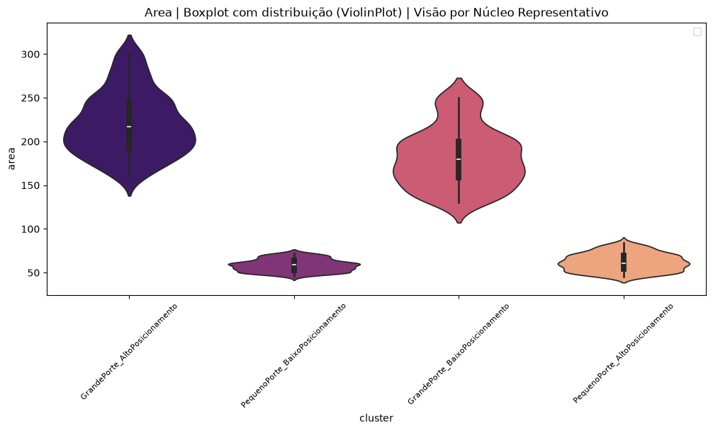

```python
plt.figure(figsize=(12, 5))
sns.violinplot(data=segmentacao_nucleo_repr, y='area',x='cluster', palette='magma')
plt.title('Area | Boxplot com distribuição (ViolinPlot) | Visão por Núcleo Representativo')
plt.legend()
plt.xticks(rotation=45, fontsize=8)
```

```
([0, 1, 2, 3],
 [Text(0, 0, 'GrandePorte_AltoPosicionamento'),
```

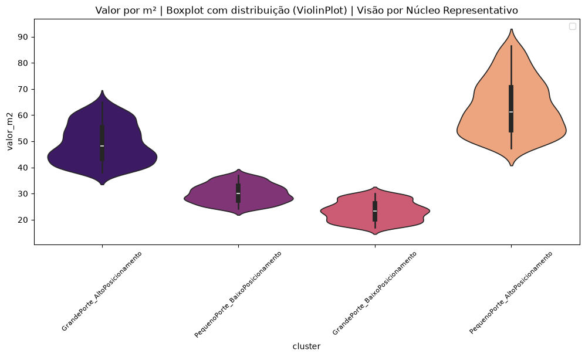

```python
plt.figure(figsize=(12, 5))
sns.violinplot(data=segmentacao_nucleo_repr, y='valor_m2',x='cluster', palette='magma')
plt.title('Valor por m² | Boxplot com distribuição (ViolinPlot) | Visão por Núcleo Representativo')
plt.legend()
plt.xticks(rotation=45, fontsize=8)
```

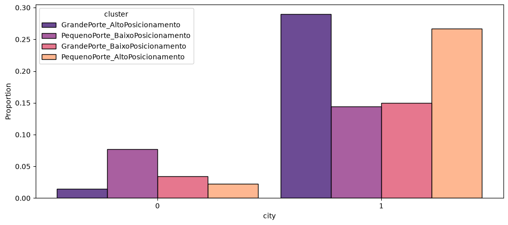

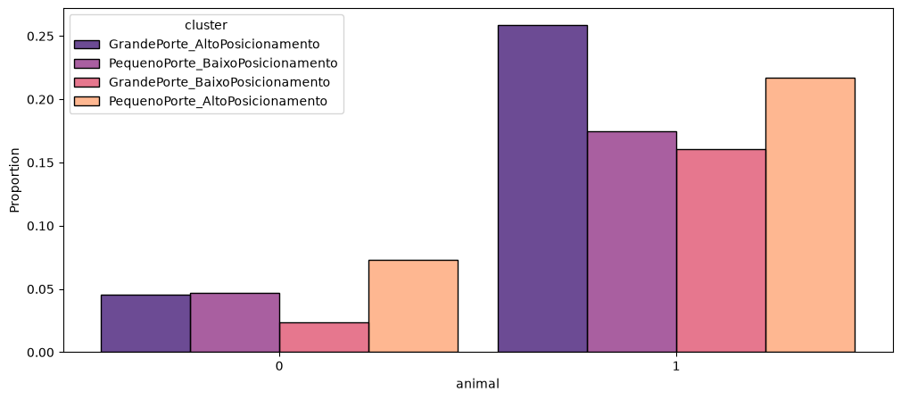

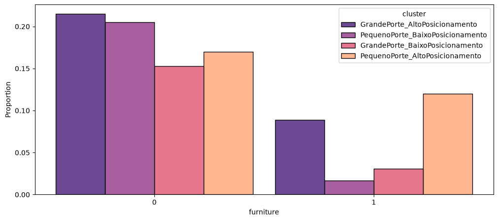

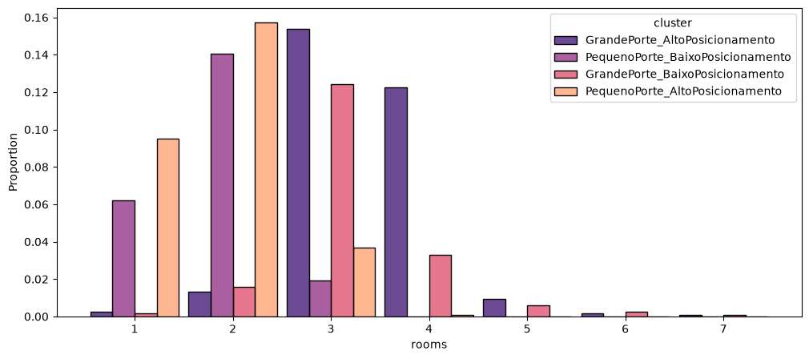

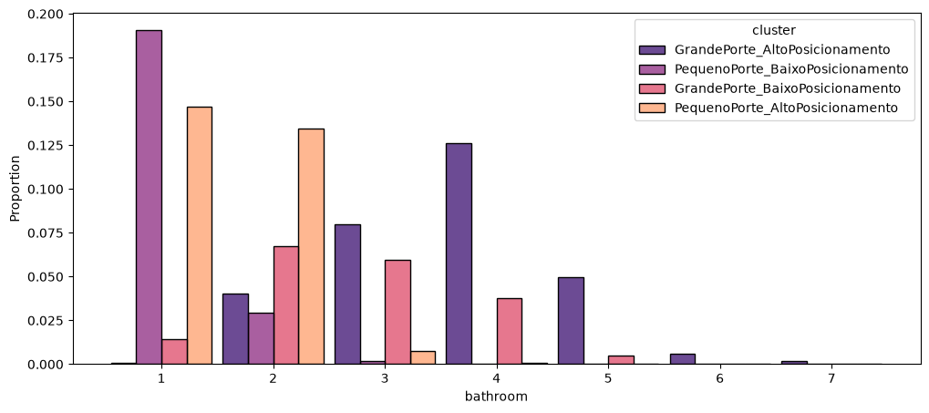

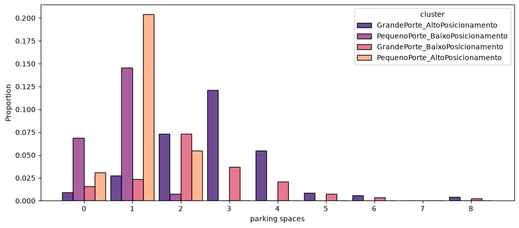

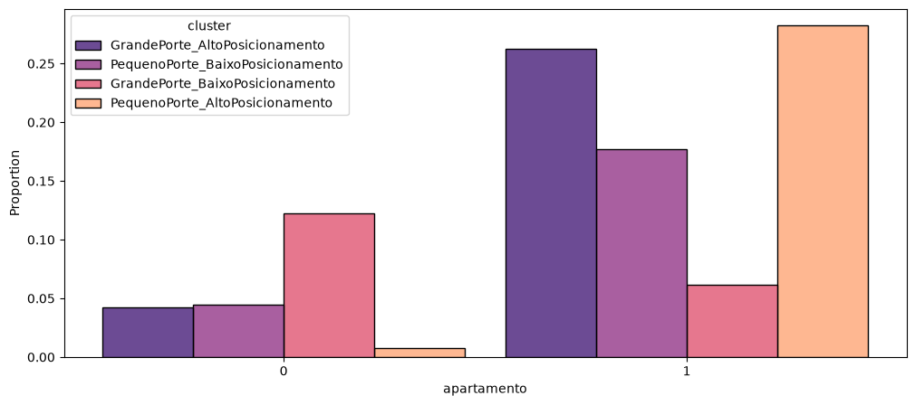

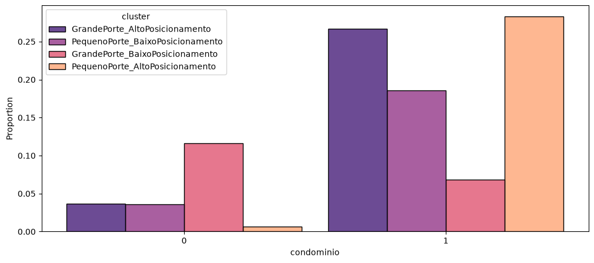

```python
for i in range(len(quali_quantidisc)-1):
    plt.figure(figsize=(12, 5))
    sns.histplot(data=segmentacao_nucleo_repr, x=quali_quantidisc[i], hue='cluster', stat='proportion', multiple='dodge', palette='magma', discrete=True, shrink=0.9)
    plt.xticks(range(segmentacao_nucleo_repr[quali_quantidisc[i]].min(), segmentacao_nucleo_repr[quali_quantidisc[i]].max()+1, 1))
    plt.show()
```

#### Imóvel típico por segmento

Já geramos a tabela com as características de cada cluster ao final da seção de KMeans, delineando limites. Na seções acima analisamos cluster x cluster, tanto sob o viés de faixa operacional, quanto de seus núcleos duros. Agora buscaremos abstrair a ideia do imóvel típico por segmento. Faremos isto analisando valores mais típicos de cada característica (média e moda) e depois compararemos se o imóvel típico por faixa operacional e nucleo representativo é muito alterado.

Contemplando todos os elemento de cada cluster:

```python
tipico_cluster_operacional = segmentacao_final.groupby('cluster').agg({'area': 'mean', 'rooms': pd.Series.mode, 'bathroom': pd.Series.mode, 'parking spaces': pd.Series.mode, 'animal': pd.Series.mode,
                                                 'furniture': pd.Series.mode, 'total': 'mean', 'valor_m2': 'mean', 'condominio': pd.Series.mode})

tipico_cluster_operacional
```

| cluster | area | rooms | bathroom | parking spaces | animal | furniture | total | valor_m2 | condominio |
| --- | --- | --- | --- | --- | --- | --- | --- | --- | --- |
| GrandePorte_AltoPosicionamento | 239.978811 | 3 | 4 | 2 | 1 | 0 | 11535.501471 | 53.769048 | 1 |
| GrandePorte_BaixoPosicionamento | 201.119071 | 3 | 2 | 2 | 1 | 0 | 4313.975799 | 23.845118 | 0 |
| PequenoPorte_AltoPosicionamento | 64.253479 | 1 | 1 | 1 | 1 | 0 | 4149.063521 | 72.456978 | 1 |
| PequenoPorte_BaixoPosicionamento | 59.303721 | 2 | 1 | 1 | 1 | 0 | 1724.790433 | 31.358325 | 1 |

Contemplando somete os imóveis de cada clusters contidos no nucleo representativo

```python
tipico_cluster_nucleo = segmentacao_nucleo_repr.groupby('cluster').agg({'area': 'mean', 'rooms': pd.Series.mode, 'bathroom': pd.Series.mode, 'parking spaces': pd.Series.mode, 'animal': pd.Series.mode,
                                                 'furniture': pd.Series.mode, 'total': 'mean', 'valor_m2': 'mean', 'condominio': pd.Series.mode})

tipico_cluster_nucleo
```

| cluster | area | rooms | bathroom | parking spaces | animal | furniture | total | valor_m2 | condominio |
| --- | --- | --- | --- | --- | --- | --- | --- | --- | --- |
| GrandePorte_AltoPosicionamento | 220.270718 | 3 | 4 | 3 | 1 | 0 | 10698.138122 | 49.30708 | 1 |
| GrandePorte_BaixoPosicionamento | 182.013699 | 3 | 2 | 2 | 1 | 0 | 4147.767123 | 23.275613 | 0 |
| PequenoPorte_AltoPosicionamento | 62.153623 | 2 | 1 | 1 | 1 | 0 | 3850.553623 | 63.077673 | 1 |
| PequenoPorte_BaixoPosicionamento | 58.484848 | 2 | 1 | 1 | 1 | 0 | 1748.287879 | 30.079207 | 1 |

Os imóveis típicos nos dão uma visão mais bem delineada do que seria um imóvel para cada segmento.

**Vamos observar o núcleo representativo**: algo interesante é que imóveis de Grande porte possuem configurações aproximadas, com alguma variação em número de banheiro e vagas de estacionamento. Existe sim uma diferença representativa de área (40m2), aproximadamente 20% de aumento, porém a diferença de valor por metro quadrado é mais do que o dobro. Essa diferença dificilmente seria explicada soment pelo aumento singelo e banheiro e vagas de estacionamento, além do estacionamento. Uma evolução de estudo seria a coleta de CEP ou região de localização. Outro fator que pode impactar, e também não possuímos dados coletados, é o estado e qualidade de conservação que poderia ser avaliado por features quantitativas como dias desde ultima reforma ou idade do imóvel, ou mesmo qualitativas como classificação pelo corretor em categorias.

A indagação acima fica mais clara ainda nos imóveis de pequeno porte. As configurações de construção são as mesmas, com exceção da variação em área, que é mínima, de 4 m2. Porém, temos um valor por m2 que é mais do que o dobro.

**Comparativo**:

O imóvel típico por faixa operacional (p1-p99) e nucleo representativo possuem formações de imagens de imóveis bem aproximados, onde somente no segmento PequenoPorte_AltoPosicionamento possuímos uma variação um pouco mais chamativa (principalmente no que se refere a valor_m2)

### Relação atributos e Valor

```python
regras_negocio
```

| cluster | area_min | area_p25 | area_p75 | area_max | total_min | total_p25 | total_p75 | total_max | valor_m2_min | valor_m2_p25 | valor_m2_p75 | valor_m2_max |
| --- | --- | --- | --- | --- | --- | --- | --- | --- | --- | --- | --- | --- |
| GrandePorte_AltoPosicionamento | 75 | 160.0 | 300.0 | 620 | 5483 | 8414.0 | 14040.0 | 28491 | 17.0 | 38.0 | 65.0 | 208.0 |
| GrandePorte_BaixoPosicionamento | 95 | 130.0 | 250.0 | 600 | 1243 | 3218.0 | 5229.0 | 9292 | 5.0 | 17.0 | 30.0 | 43.0 |
| PequenoPorte_AltoPosicionamento | 10 | 45.0 | 84.0 | 120 | 1570 | 3000.0 | 4872.0 | 14903 | 32.0 | 47.0 | 87.0 | 311.0 |
| PequenoPorte_BaixoPosicionamento | 11 | 46.0 | 72.0 | 120 | 660 | 1326.0 | 2105.0 | 2871 | 8.0 | 24.0 | 37.0 | 109.0 |

```python
tipico_cluster_nucleo
```

| cluster | area | rooms | bathroom | parking spaces | animal | furniture | total | valor_m2 | condominio |
| --- | --- | --- | --- | --- | --- | --- | --- | --- | --- |
| GrandePorte_AltoPosicionamento | 220.270718 | 3 | 4 | 3 | 1 | 0 | 10698.138122 | 49.30708 | 1 |
| GrandePorte_BaixoPosicionamento | 182.013699 | 3 | 2 | 2 | 1 | 0 | 4147.767123 | 23.275613 | 0 |
| PequenoPorte_AltoPosicionamento | 62.153623 | 2 | 1 | 1 | 1 | 0 | 3850.553623 | 63.077673 | 1 |
| PequenoPorte_BaixoPosicionamento | 58.484848 | 2 | 1 | 1 | 1 | 0 | 1748.287879 | 30.079207 | 1 |

No primeiro experimento de KMeans, apesar do fato de que traria uma resposta diferente da que desejávamos responder (segmentos de construção ao invés de segmento de mercado), foi possível observar um fato interessante: o modelo já demonstrava dificuldade de separar a base em clusters de segmentos somente pelas variáveis atuais de construção. O modelo final conseguiu fazer uma separação aceitável para fins de negócio, onde temos para cada característica (seja econômica ou espacial) amplitudes razoáveis quando observamos os 50% de dados centrais da distribuição.

Quando analisamos os imóveis típicos por segmentos vislumbramos características muito aproximadas entre os dois clusters de grande porte e depois tambem entre os dois clusters de pequeno porte, porém com grandes diferenças nas questões ecônomicas com valores por metro quadrado quase dobradas. Comentamos sobre possíveis influencias nos valores definidos para aluguel que vão além do que nossa database permite analisar. Nesta etapa poderemos entender quais atributos mais influenciam para precificação, assim como quanto da variação de precificação é possível de ser explicada pelas features atuais.

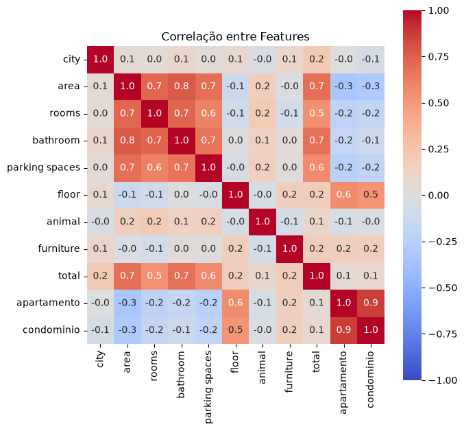

```python
plt.figure(figsize=(7,7))
plt.title('Correlação entre Features')
corr_df = segmentacao_final.drop(columns=['hoa', 'rent amount', 'property tax', 'fire insurance', 'prop_hoa_total', 'valor_m2']).corr(numeric_only=True)

sns.heatmap(corr_df, annot=True, vmin=-1.0, vmax=1.0, cmap='coolwarm', square=True, fmt=".1f")
plt.show()
```

Temos uma possível multicolinearidade relacionado a área: rooms, bathroom e parking space. Porém, a exclusão de qualquer destas colunas pode ser a retirada de sinal valioso para variância do mundo real.

Para Ridge, Decision Tree e Random Forest: possuem mecanismos internos robustos para mitigar os efeitos da multicolinearidade sem a necessidade de descartar dados essenciais. Testaremos também a Lasso, que internamente possui mecanismos de zerar features irrelevantes ou multicolineares, para fins de experimentação

```python
print(segmentacao_final.groupby('apartamento')['total'].mean())
print(segmentacao_final.groupby('condominio')['total'].mean())
print(segmentacao_final.groupby('furniture')['total'].mean())
print(segmentacao_final.groupby('animal')['total'].mean())
```

```
apartamento
0    5347.920998
1     5979.82038
Name: total, dtype: Float64
condominio
0    5143.937407
1    6027.968119
Name: total, dtype: Float64
furniture
0    5346.759079
1    7158.635997
Name: total, dtype: Float64
animal
0    5083.380769
1    6037.417083
Name: total, dtype: Float64
```

A área possui influencias sobre o preço. Porém, ela sozinha não explica preços, visto que grande imoveis com preços muito distintos e pequenos imoveis com preços também muito distintos. Inclusive, o núcleo representativo de PequenoPorte_AltoPosicionamento e GrandePorte_BaixoPosicionamento possuem faixas de valores muito aproximados.

Furniture, Animal, Apartamento e Condominio possuem baixas correlações com preços totais. Quando agrupamos por cada feature, temos realidades distintas. Furniture apresenta grande diferença de média de valor total no aluguel do imóvel. Já ‘animal’, ‘condominio’ e ‘apartamento’ apresentam médias diferentes para seus valores binários, porém em uma situação mais razoável.

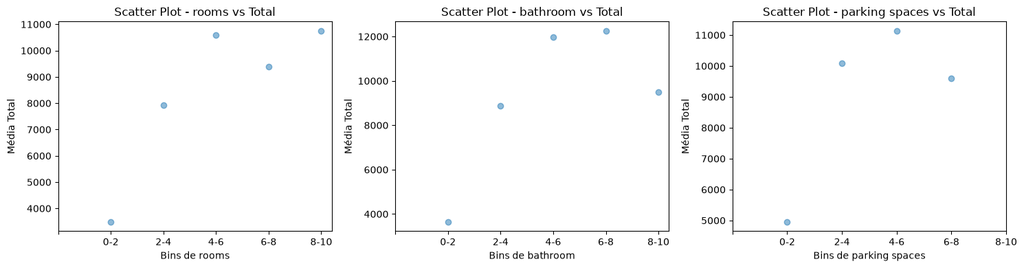

```python
lista = ['rooms', 'bathroom', 'parking spaces']
bins = [0, 2, 4, 6, 8, 10]
classes_bins = [2, 4, 6, 8, 10]
plt.figure(figsize=(15, 4))
for i in range(len(lista)):
    scatter = segmentacao_final.copy()
    scatter['bins'] = pd.cut(segmentacao_final[lista[i]], bins=bins, labels=classes_bins)
    scatter = scatter.groupby('bins')['total'].mean().reset_index()
    plt.subplot(1,3,i+1)
    plt.scatter(scatter['bins'], scatter['total'], alpha=0.5)
    plt.xlabel(f'Bins de {lista[i]}')
    plt.ylabel('Média Total')
    plt.xticks(bins, ['', '0-2', '2-4', '4-6', '6-8', '8-10'])
    plt.title(f'Scatter Plot - {lista[i]} vs Total')
plt.tight_layout()
```

Rooms, bathrooms e parking spaces apresentam correlações positivas razoaveis com total, comportamento aproximado com o da feature área. Quando agrupamos os dados vemos que existe correlação positiva de aumentos destas features e do total, porém ela não é de forma constante (linearidade).

```python
gpap = segmentacao_final[segmentacao_final['cluster'] == 'GrandePorte_AltoPosicionamento'].drop(columns=['hoa', 'rent amount', 'property tax', 'fire insurance', 'prop_hoa_total', 'valor_m2', 'cluster']).copy()
gpbp = segmentacao_final[segmentacao_final['cluster'] == 'GrandePorte_BaixoPosicionamento'].drop(columns=['hoa', 'rent amount', 'property tax', 'fire insurance', 'prop_hoa_total', 'valor_m2', 'cluster']).copy()
ppap = segmentacao_final[segmentacao_final['cluster'] == 'PequenoPorte_AltoPosicionamento'].drop(columns=['hoa', 'rent amount', 'property tax', 'fire insurance', 'prop_hoa_total', 'valor_m2', 'cluster']).copy()
ppbp = segmentacao_final[segmentacao_final['cluster'] == 'PequenoPorte_BaixoPosicionamento'].drop(columns=['hoa', 'rent amount', 'property tax', 'fire insurance', 'prop_hoa_total', 'valor_m2', 'cluster']).copy()
```

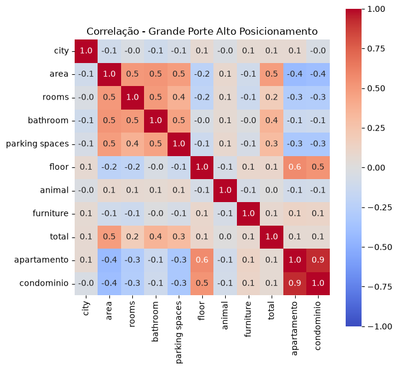

```python
plt.figure(figsize=(7,7))
corr_gpap = gpap.corr(numeric_only=True)
plt.title('Correlação - Grande Porte Alto Posicionamento')

sns.heatmap(corr_gpap, annot=True, vmin=-1.0, vmax=1.0, cmap='coolwarm', square=True, fmt=".1f")
plt.show()
```

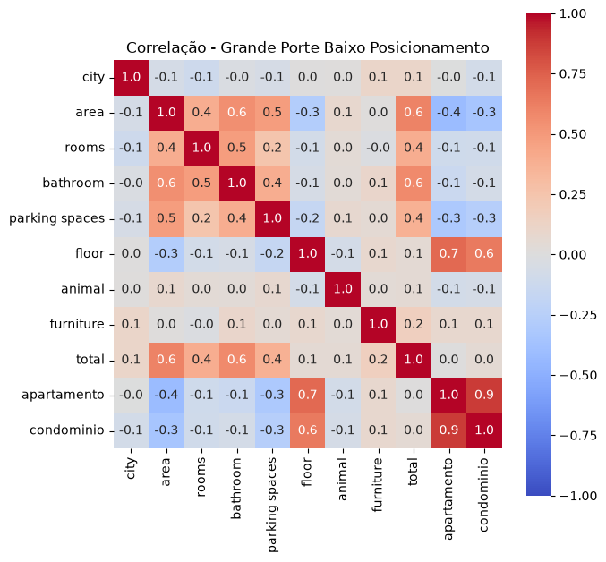

```python
plt.figure(figsize=(7,7))
corr_gpbp = gpbp.corr(numeric_only=True)
plt.title('Correlação - Grande Porte Baixo Posicionamento')

sns.heatmap(corr_gpbp, annot=True, vmin=-1.0, vmax=1.0, cmap='coolwarm', square=True, fmt=".1f")
plt.show()
```

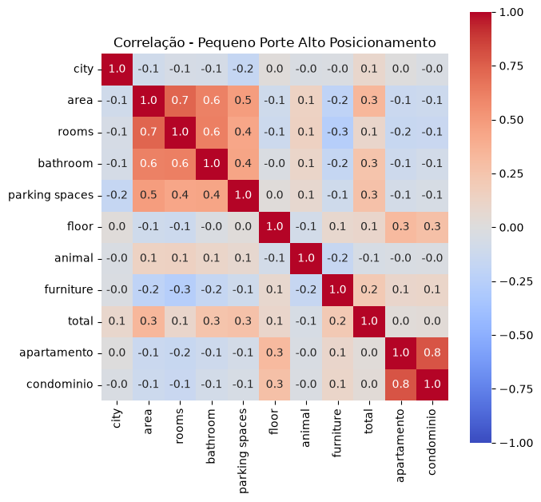

```python
plt.figure(figsize=(7,7))
corr_ppap = ppap.corr(numeric_only=True)
plt.title('Correlação - Pequeno Porte Alto Posicionamento')

sns.heatmap(corr_ppap, annot=True, vmin=-1.0, vmax=1.0, cmap='coolwarm', square=True, fmt=".1f")
plt.show()
```

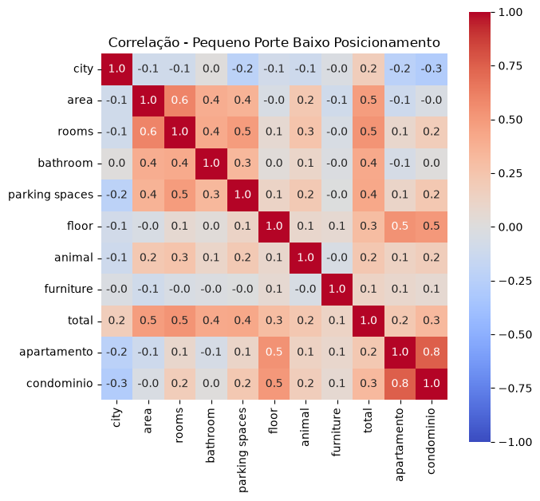

```python
plt.figure(figsize=(7,7))
corr_ppbp = ppbp.corr(numeric_only=True)
plt.title('Correlação - Pequeno Porte Baixo Posicionamento')

sns.heatmap(corr_ppbp, annot=True, vmin=-1.0, vmax=1.0, cmap='coolwarm', square=True, fmt=".1f")
plt.show()
```

É importante reparar como a correlação de uma mesma variável muda de um cluster para o outro: - condominio no Geral: Correlação de 0.1 com o total. - condominio no Grande Porte Baixo Posicionamento: A correlação é de 0.0 - condominio no Pequeno Porte Baixo Posicionamento: A correlação sobe para 0.3

Outro exemplo: - area no Geral: Correlação de 0.7 com o total. - area no Grande Porte Alto Posicionamento: Correlação de 0.5 com o total. - area no Pequeno Porte Alto Posicionamento: Correlação desce para 0.3 com o total.

Com essa forte variação de comportamento, onde a relevância dessas variáveis depende do contexto do imóvel, temos a defesa de modelos de precificação especializados de acordo com o segmento de mercado ao invés de um modelo generalista.

## Machine Learning

Sob a perspectiva de operações de negócio, teríamos o seguinte **fluxo de processo**:

- Captação do imóvel e de dados de features relativas ao imóvel
- Utilizar modelo classificador de segmentos de imóvel para avaliar onde o imóvel se enquadra
- Utilizar modelo regressor especializado para simular precificação
- Utilizar expertise do corretor especialista para balizar e equalizar os resultados.

Usaremos a abordagem de Two-Stage Models: Esta abordagem reduz a variância dentro de cada grupo e permite que cada modelo especialista capture padrões mais específicos para o seu segmento.

### Classificador

```python
comparativo_modelos_classifier = {}
```

```python
x = segmentacao_final[['area', 'rooms', 'bathroom', 'parking spaces', 'animal', 'furniture', 'apartamento', 'condominio']]
y = segmentacao_final['cluster']

x_global_train, x_global_test, y_global_train, y_global_test = train_test_split(x, y, test_size=0.3, random_state=42, stratify=y)
```

#### Baseline

```python
x_train = x_global_train
x_test = x_global_test
y_train = y_global_train
y_test = y_global_test

cv_estratificado = StratifiedKFold(n_splits=5, shuffle=True, random_state=42)

metricas = ["accuracy", "precision_macro", "recall_macro", "f1_macro"]

baseline_tree = DecisionTreeClassifier(random_state=42)
baseline_logistic = LogisticRegression(random_state=42, max_iter=1000)
baseline_rf = RandomForestClassifier(random_state=42)


resultados_cv_tree = cross_validate(
    baseline_tree, x_train, y_train,
    cv=cv_estratificado,
    scoring=metricas,
    return_train_score=False)

resultados_cv_logistic = cross_validate(
    baseline_logistic, x_train, y_train,
    cv=cv_estratificado,
    scoring=metricas,
    return_train_score=False)

resultados_cv_rf = cross_validate(
    baseline_rf, x_train, y_train,
    cv=cv_estratificado,
    scoring=metricas,
    return_train_score=False)
```

```python
dicionario_resultados = {
    "Decision Tree": resultados_cv_tree,
    "Logistic Regression": resultados_cv_logistic,
    "Random Forest": resultados_cv_rf}

linhas_tabela = []

for nome_modelo, metricas_cv in dicionario_resultados.items():
    linha = {"Modelo": nome_modelo}

    for metrica in metricas:
        chave_sklearn = f"test_{metrica}"
        linha[metrica] = np.mean(metricas_cv[chave_sklearn])

    linhas_tabela.append(linha)

df_baselines = pd.DataFrame(linhas_tabela)
df_baselines = df_baselines.sort_values(by="accuracy", ascending=False).reset_index(drop=True)

display(df_baselines)
```

|  | Modelo | accuracy | precision_macro | recall_macro | f1_macro |
| --- | --- | --- | --- | --- | --- |
| 0 | Logistic Regression | 0.730893 | 0.726691 | 0.708658 | 0.712221 |
| 1 | Random Forest | 0.701325 | 0.691302 | 0.689431 | 0.689882 |
| 2 | Decision Tree | 0.675011 | 0.665592 | 0.662830 | 0.663515 |

Com o Random Forest perderemos explicabilidade, sem grande margem de ganho adicional em relação a Decision Tree (e perdendo para Logistica) e ainda exigindo maior processamento.

#### Random Forest

```python
x_train = x_global_train
x_test = x_global_test
y_train = y_global_train
y_test = y_global_test

rf = RandomForestClassifier(random_state=42)

param_grid_rf = {
    "n_estimators": [100, 200, 300],
    "criterion": ["gini", "entropy"],
    "max_depth": [5, 10, 15, None],
    "min_samples_split": [5, 10, 20],
    "min_samples_leaf": [2, 5, 10]}

cv = StratifiedKFold(
    n_splits=5,
    shuffle=True,
    random_state=42)

grid_search = GridSearchCV(
    estimator=rf,
    param_grid=param_grid_rf,
    scoring="f1_macro",
    cv=cv,
    n_jobs=-1,
    verbose=1,
    return_train_score=True,
    refit=True)

grid_search.fit(x_train, y_train)
```

```
Fitting 5 folds for each of 216 candidates, totalling 1080 fits
```

```
GridSearchCV(cv=StratifiedKFold(n_splits=5, random_state=42, shuffle=True),
             estimator=RandomForestClassifier(random_state=42), n_jobs=-1,
             param_grid={'criterion': ['gini', 'entropy'],
                         'max_depth': [5, 10, 15, None],
                         'min_samples_leaf': [2, 5, 10],
                         'min_samples_split': [5, 10, 20],
                         'n_estimators': [100, 200, 300]},
             return_train_score=True, scoring='f1_macro', verbose=1)
```

```python
print("\nMelhores hiperparâmetros:")
print(grid_search.best_params_)

best_index = grid_search.best_index_
resultados_cv = grid_search.cv_results_

print("\nAcurácia de validação por fold (StratifiedKFold - Melhor Modelo):")
for i in range(5):
    fold_score = resultados_cv[f'split{i}_test_score'][best_index]
    print(f"Fold {i+1}: {fold_score:.4f}")


best_rf = grid_search.best_estimator_

y_train_pred = best_rf.predict(x_train)
y_test_pred = best_rf.predict(x_test)

train_accuracy = accuracy_score(y_train, y_train_pred)
test_accuracy = accuracy_score(y_test, y_test_pred)

print("\nDesempenho do melhor modelo:")
print(f"Acurácia na validação cruzada: {grid_search.best_score_:.4f}")
print(f"Acurácia no treinamento: {train_accuracy:.4f}")
print(f"Acurácia no teste:       {test_accuracy:.4f}")
print(f"Diferença treino-teste:  {train_accuracy - test_accuracy:.4f}")
print(classification_report(y_test, y_test_pred))

auc = roc_auc_score(y_test, best_rf.predict_proba(x_test), multi_class='ovr')
print(f"AUC: {auc:.4f}")

f1_macro = f1_score(y_test, y_test_pred, average='macro')
comparativo_modelos_classifier['Random Forest'] = {'Acurácia': test_accuracy, 'AUC (OVR)': auc, 'F1 Macro': f1_macro}
```

```
Melhores hiperparâmetros:
{'criterion': 'gini', 'max_depth': 10, 'min_samples_leaf': 2, 'min_samples_split': 20, 'n_estimators': 200}

Acurácia de validação por fold (StratifiedKFold - Melhor Modelo):
Fold 1: 0.7343
Fold 2: 0.7480
Fold 3: 0.7255
Fold 4: 0.7131
Fold 5: 0.7184

Desempenho do melhor modelo:
Acurácia na validação cruzada: 0.7279
Acurácia no treinamento: 0.7863
Acurácia no teste:       0.7428
Diferença treino-teste:  0.0434
                                  precision    recall  f1-score   support

  GrandePorte_AltoPosicionamento       0.76      0.83      0.79       510
 GrandePorte_BaixoPosicionamento       0.65      0.53      0.59       310
 PequenoPorte_AltoPosicionamento       0.74      0.81      0.77       496
PequenoPorte_BaixoPosicionamento       0.78      0.72      0.75       395

                        accuracy                           0.74      1711
                       macro avg       0.73      0.72      0.73      1711
                    weighted avg       0.74      0.74      0.74      1711

AUC: 0.9359
```

Temos uma arvoré profunda, o que pode acarretar em overfiting. Com 200 estimadores temos um tamanho moderado a grande, o que não necessariamente acarreta em overfiting visto que principal poder do Random Forest vem da votação coletiva, onde com tal tamanho suaviza-se ruídos e reduz a variância dos dados. Porém, exige maior processamento, o que é um ponto de atenção. Houve estabilidade nos fold durante a validação e podemos descartar vies de seleção. A diferença de treino e teste é de 4% na acurácia, não temos overfiting. Temos bons equilibrios de precision (que controla falsos positivos) e recall (que controla falsos negativos), a exceção é o segmento GrandePorte_BaixoPosicionamento, devido a má capacidade demonstrada em recall (ou seja, dentre todos que eram, quantos foram indicados corretamente no segmento).

Como previsto pelo baseline, o Random Forest não oferece um grande incremento de performance que justifique seu uso.

#### Decision Tree

```python
x_train = x_global_train
x_test = x_global_test
y_train = y_global_train
y_test = y_global_test

tree = DecisionTreeClassifier(random_state=42)

param_grid = {
    "criterion": ["gini", "entropy"],
    "max_depth": [3, 5, 7],
    "min_samples_split": [6, 10, 30, 60],
    "min_samples_leaf": [3, 5, 15, 30],
    "max_features": [None, "sqrt", "log2"]}

cv = StratifiedKFold(
    n_splits=5,
    shuffle=True,
    random_state=42)

grid_search = GridSearchCV(
    estimator=tree,
    param_grid=param_grid,
    scoring="f1_macro",
    cv=cv,
    n_jobs=-1,
    verbose=1,
    return_train_score=True,
    refit=True)

grid_search.fit(x_train, y_train)
```

```
Fitting 5 folds for each of 288 candidates, totalling 1440 fits
```

```
GridSearchCV(cv=StratifiedKFold(n_splits=5, random_state=42, shuffle=True),
             estimator=DecisionTreeClassifier(random_state=42), n_jobs=-1,
             param_grid={'criterion': ['gini', 'entropy'],
                         'max_depth': [3, 5, 7],
                         'max_features': [None, 'sqrt', 'log2'],
                         'min_samples_leaf': [3, 5, 15, 30],
                         'min_samples_split': [6, 10, 30, 60]},
             return_train_score=True, scoring='f1_macro', verbose=1)
```

```python
print("\nMelhores hiperparâmetros:")
print(grid_search.best_params_)
print("\nMelhor acurácia média na validação cruzada:",f"{grid_search.best_score_:.4f}")

best_index = grid_search.best_index_
resultados_cv = grid_search.cv_results_

print("\nAcurácia de validação por fold (StratifiedKFold - Melhor Modelo):")
for i in range(5):
    fold_score = resultados_cv[f'split{i}_test_score'][best_index]
    print(f"Fold {i+1}: {fold_score:.4f}")
```

```
Melhores hiperparâmetros:
{'criterion': 'gini', 'max_depth': 7, 'max_features': None, 'min_samples_leaf': 15, 'min_samples_split': 6}

Melhor acurácia média na validação cruzada: 0.7136

Acurácia de validação por fold (StratifiedKFold - Melhor Modelo):
Fold 1: 0.7135
Fold 2: 0.7219
Fold 3: 0.7357
Fold 4: 0.6926
Fold 5: 0.7045
```

```python
best_tree = grid_search.best_estimator_

y_train_pred = best_tree.predict(x_train)
y_test_pred = best_tree.predict(x_test)

train_accuracy = accuracy_score(y_train, y_train_pred)
test_accuracy = accuracy_score(y_test, y_test_pred)

print("\nDesempenho do melhor modelo:")
print(f"Acurácia na validação cruzada: {grid_search.best_score_:.4f}")
print(f"Acurácia no treinamento: {train_accuracy:.4f}")
print(f"Acurácia no teste:       {test_accuracy:.4f}")
print(f"Diferença treino-teste:  {train_accuracy - test_accuracy:.4f}")
print(classification_report(y_test, y_test_pred))

auc = roc_auc_score(y_test, best_tree.predict_proba(x_test), multi_class='ovr')
print(f"AUC: {auc:.4f}")

f1_macro = f1_score(y_test, y_test_pred, average='macro')
comparativo_modelos_classifier['Decision Tree'] = {'Acurácia': test_accuracy, 'AUC (OVR)': auc, 'F1 Macro': f1_macro}
```

```
Desempenho do melhor modelo:
Acurácia na validação cruzada: 0.7136
Acurácia no treinamento: 0.7595
Acurácia no teste:       0.7399
Diferença treino-teste:  0.0195
                                  precision    recall  f1-score   support

  GrandePorte_AltoPosicionamento       0.73      0.88      0.80       510
 GrandePorte_BaixoPosicionamento       0.73      0.46      0.56       310
 PequenoPorte_AltoPosicionamento       0.75      0.78      0.76       496
PequenoPorte_BaixoPosicionamento       0.76      0.72      0.74       395

                        accuracy                           0.74      1711
                       macro avg       0.74      0.71      0.72      1711
                    weighted avg       0.74      0.74      0.73      1711

AUC: 0.9246
```

```python
plt.figure(figsize=(30, 16), dpi=300)

plot_tree(
    best_tree,
    feature_names=x_train.columns if hasattr(x_train, 'columns') else None,
    class_names=best_tree.classes_,
    filled=True,
    rounded=True,
    fontsize=10,
    max_depth=5)

plt.title("Visualização da Árvore de Decisão", fontsize=16)
plt.tight_layout()
plt.show()
```

[figure not shown]

```
area              0.691292
furniture         0.093641
apartamento       0.089430
bathroom          0.049410
parking spaces    0.028349
condominio        0.025100
rooms             0.021326
animal            0.001451
dtype: float64
```

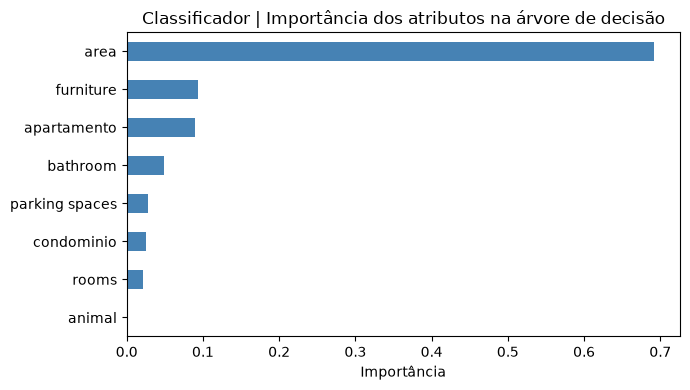

```python
importancias = pd.Series(best_tree.feature_importances_,
                         index=['area', 'rooms', 'bathroom', 'parking spaces', 'animal', 'furniture', 'apartamento', 'condominio']).sort_values(ascending=False)

print(importancias)

plt.figure(figsize=(7, 4))
importancias.plot(kind="barh", color="steelblue")
plt.gca().invert_yaxis()
plt.xlabel("Importância")
plt.title("Classificador | Importância dos atributos na árvore de decisão")
plt.tight_layout()
plt.show()
```

Tivemos uma arvore razoavelmente profunda, o que pode não ser muito interessante e é preciso avaliar overfiting. Existe estabilidade nos folds da validação, assim como em Random Forest. Os indicadores de cada cluster refletem as mesmas questões do Random, assim como a diferença de acurácia de validação/treino/teste nos tranquilizam quanto a overfiting, mostrando que o modelo consegue generalizar para novos dados mantendo performance. Area, furniture e apartamento foram as features mais relevantes. Apesar do GridSearch nos ter fornecido o melhor modelo sem limitar features, a importância dos atributos nos mostra que ‘animal’ só acrescentou ruído. Poderia valer um teste com a retirada da feature ‘animal’, porém prosseguiremos para este caso somente se este modelo se comprove melhor que a regressão logística

#### Regressão Logística

```python
x_train = x_global_train
x_test = x_global_test
y_train = y_global_train
y_test = y_global_test

pipeline_grid = Pipeline([
    ("scaler", RobustScaler()),
    ("logreg", LogisticRegression(max_iter=5000, solver="lbfgs", random_state=42))])

param_grid = {
    "logreg__C": [0.01, 0.1, 0.5, 1, 5, 10, 50],
    "logreg__penalty": ["l1", "l2"]}

cv_estratificado = StratifiedKFold(n_splits=5, shuffle=True, random_state=42)

grid_search = GridSearchCV(
    pipeline_grid,
    param_grid=param_grid,
    scoring="f1_macro",
    cv=cv_estratificado,
    n_jobs=-1)

grid_search.fit(x_train, y_train)
```

```
GridSearchCV(cv=StratifiedKFold(n_splits=5, random_state=42, shuffle=True),
             estimator=Pipeline(steps=[('scaler', RobustScaler()),
                                       ('logreg',
                                        LogisticRegression(max_iter=5000,
                                                           random_state=42))]),
             n_jobs=-1,
             param_grid={'logreg__C': [0.01, 0.1, 0.5, 1, 5, 10, 50],
                         'logreg__penalty': ['l1', 'l2']},
             scoring='f1_macro')
```

```python
print("\nMelhores hiperparâmetros:")
print(grid_search.best_params_)
print("\nMelhor acurácia média na validação cruzada:",f"{grid_search.best_score_:.3f}")

best_index = grid_search.best_index_
resultados_cv = grid_search.cv_results_

print("\nAcurácia de validação por fold (StratifiedKFold - Melhor Modelo):")
for i in range(5):
    fold_score = resultados_cv[f'split{i}_test_score'][best_index]
    print(f"Fold {i+1}: {fold_score:.4f}")
```

```
Melhores hiperparâmetros:
{'logreg__C': 50, 'logreg__penalty': 'l2'}

Melhor acurácia média na validação cruzada: 0.712

Acurácia de validação por fold (StratifiedKFold - Melhor Modelo):
Fold 1: 0.7242
Fold 2: 0.7386
Fold 3: 0.6909
Fold 4: 0.6916
Fold 5: 0.7130
```

```
Desempenho do melhor modelo:
Acurácia na validação cruzada: 0.7116
Acurácia no treinamento: 0.7342
Acurácia no teste:       0.7335
Diferença treino-teste:  0.0007
                                  precision    recall  f1-score   support

  GrandePorte_AltoPosicionamento       0.73      0.86      0.79       510
 GrandePorte_BaixoPosicionamento       0.70      0.47      0.56       310
 PequenoPorte_AltoPosicionamento       0.74      0.77      0.76       496
PequenoPorte_BaixoPosicionamento       0.75      0.73      0.74       395

                        accuracy                           0.73      1711
                       macro avg       0.73      0.71      0.71      1711
                    weighted avg       0.73      0.73      0.73      1711

AUC: 0.9273
```

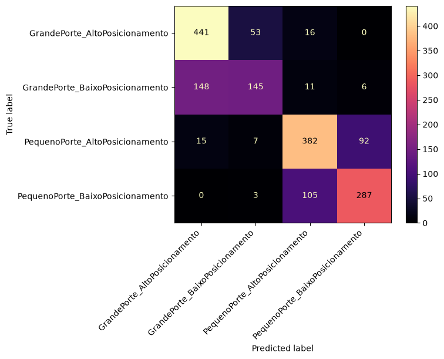

```python
best_log = grid_search.best_estimator_

y_train_pred = best_log.predict(x_train)
y_test_pred = best_log.predict(x_test)

train_accuracy = accuracy_score(y_train, y_train_pred)
test_accuracy = accuracy_score(y_test, y_test_pred)

print("\nDesempenho do melhor modelo:")
print(f"Acurácia na validação cruzada: {grid_search.best_score_:.4f}")
print(f"Acurácia no treinamento: {train_accuracy:.4f}")
print(f"Acurácia no teste:       {test_accuracy:.4f}")
print(f"Diferença treino-teste:  {train_accuracy - test_accuracy:.4f}")
print(classification_report(y_test, y_test_pred))

auc = roc_auc_score(y_test, best_log.predict_proba(x_test), multi_class='ovr')
print(f"AUC: {auc:.4f}")

disp = ConfusionMatrixDisplay.from_predictions(y_test, y_test_pred, xticks_rotation=45, cmap='magma')
plt.setp(disp.ax_.get_xticklabels(), ha='right')

f1_macro = f1_score(y_test, y_test_pred, average='macro')
comparativo_modelos_classifier['Logistic Regression'] = {'Acurácia': test_accuracy, 'AUC (OVR)': auc, 'F1 Macro': f1_macro}
```

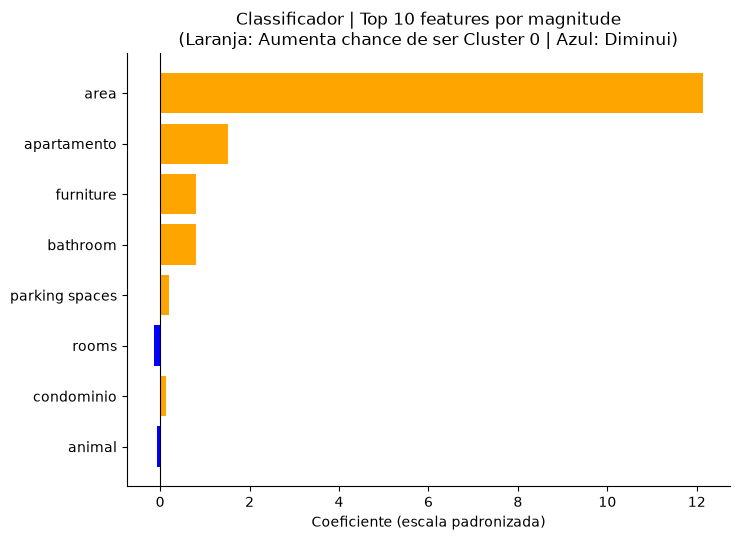

|  | feature | coeficiente | odds_ratio |
| --- | --- | --- | --- |
| 0 | area | 12.129165 | 185195.157961 |
| 6 | apartamento | 1.507085 | 4.513554 |
| 5 | furniture | 0.810395 | 2.248795 |
| 2 | bathroom | 0.801500 | 2.228883 |
| 3 | parking spaces | 0.188792 | 1.207790 |
| 1 | rooms | -0.133371 | 0.875141 |
| 7 | condominio | 0.120854 | 1.128460 |
| 4 | animal | -0.067920 | 0.934336 |

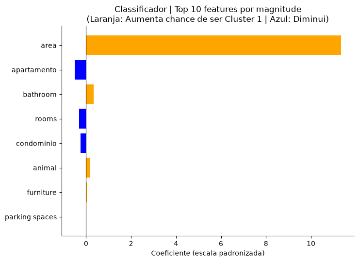

|  | feature | coeficiente | odds_ratio |
| --- | --- | --- | --- |
| 0 | area | 11.329351 | 83228.959861 |
| 6 | apartamento | -0.501591 | 0.605566 |
| 2 | bathroom | 0.343918 | 1.410463 |
| 1 | rooms | -0.310314 | 0.733217 |
| 7 | condominio | -0.251541 | 0.777602 |
| 4 | animal | 0.178923 | 1.195929 |
| 5 | furniture | 0.034280 | 1.034874 |
| 3 | parking spaces | 0.018542 | 1.018715 |

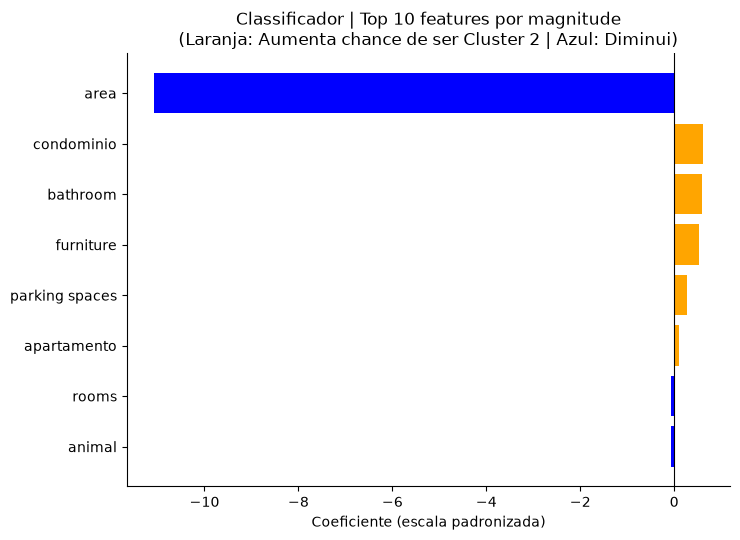

|  | feature | coeficiente | odds_ratio |
| --- | --- | --- | --- |
| 0 | area | -11.071857 | 0.000016 |
| 7 | condominio | 0.604413 | 1.830178 |
| 2 | bathroom | 0.584318 | 1.793768 |
| 5 | furniture | 0.529226 | 1.697619 |
| 3 | parking spaces | 0.276844 | 1.318960 |
| 6 | apartamento | 0.094383 | 1.098981 |
| 1 | rooms | -0.077625 | 0.925311 |
| 4 | animal | -0.071168 | 0.931306 |

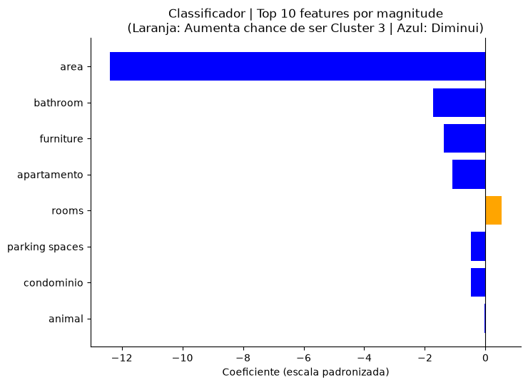

|  | feature | coeficiente | odds_ratio |
| --- | --- | --- | --- |
| 0 | area | -12.386659 | 0.000004 |
| 2 | bathroom | -1.729737 | 0.177331 |
| 5 | furniture | -1.373901 | 0.253118 |
| 6 | apartamento | -1.099877 | 0.332912 |
| 1 | rooms | 0.521310 | 1.684232 |
| 3 | parking spaces | -0.484178 | 0.616204 |
| 7 | condominio | -0.473726 | 0.622678 |
| 4 | animal | -0.039836 | 0.960947 |

```python
logreg_final = best_log.named_steps["logreg"]

for i in range(4):

    coefs_reais = pd.DataFrame({
        "feature": x.columns,
        "coeficiente": logreg_final.coef_[i]})

    coefs_reais["odds_ratio"] = np.exp(coefs_reais["coeficiente"])
    coefs_reais = coefs_reais.reindex(coefs_reais["coeficiente"].abs().sort_values(ascending=False).index)

    top_coefs = coefs_reais.head(10).iloc[::-1]

    fig, ax = plt.subplots(figsize=(7.5, 5.5))

    cores_coef = ['orange' if v > 0 else 'blue' for v in top_coefs["coeficiente"]]

    ax.barh(top_coefs["feature"], top_coefs["coeficiente"], color=cores_coef)
    ax.axvline(0, color='black', linewidth=0.8)

    ax.set_xlabel("Coeficiente (escala padronizada)")

    ax.set_title(f"Classificador | Top 10 features por magnitude\n(Laranja: Aumenta chance de ser Cluster {i} | Azul: Diminui)")

    for spine in ["top", "right"]:
        ax.spines[spine].set_visible(False)

    plt.tight_layout()
    plt.show()

    display(coefs_reais.head(10))
```

#### Modelo Final Classificador

O modelo de Regressão Logística possui performance identica a Decision Tree e Random Forest, mas seguiremos com Regressão Logística pois a explicabilidade é mais razoável do que uma árvore com 7 níveis de profundidade e quanto a Random a explicabilidade seria perdida, também exigindo maior necessidade de processamento. Ele consegue atingir uma acurácia de aproximadamente 74% nas classificações, com um razoável equilibrio de F1 Score para os 3 segmentos e uma perfomance próxima ao chute (50%) para o segmento GrandePorte_BaixoPosicionamento.

Dificilmente será possível encontrar melhores resultados, devido a questão já debatida sobre a relevância de outras features que não constam na database e por serem clusters ruidosos quando observados toda a sua composição. Algumas não estão presentes na coleta (manutenção, ano de construção, localização de bairro), enquanto outras que poderiam contribuir parcialmente são instáveis pelo dataset, por exemplo, iptu que é uma informação que consta, porém em muitos casos embutida em rent amount e que pode variar muito de região para região, onde a técnica de inputação teria sério risco de criar viéses (principalmente por estar acompanhada da falta de outras features)

A possibilidade que apoiaria a melhoria expressiva seria a inclusão no modelo de features como valor_m2 e total. Porém, aqui estamos analisando a partir de uma ideia de fluxo de operação: o imóvel é captado e ainda não possui valor de aluguel estimado. Uma alternativa, que poderia ser discutida com lideranças os bonus e onus, seria captar o imóvel já com uma expectativa de aluguel por parte do proprietário. A inclusão de ‘total’ e ‘valor_m2’ apoiaria o modelo a classificar (fiz testes e chegou a 99% de acurácia em treino e 98% em teste), posteriormente o imóvel seria enviado ao modelo precificador especialista do segmento e teríamos o primeiro ajuste, seguido do ajuste com especialista. Aqui prefirimos seguir com o fluxo estabelecido anteriormente, mesmo que contendo um modelo de classificação inferior, pois inicialmente possuo a crença que o baseline ideal seria a percepção/prática do mercado ao invés da expectativa do proprietário (que pode estar desprovida de conhecimentos deste ambito).

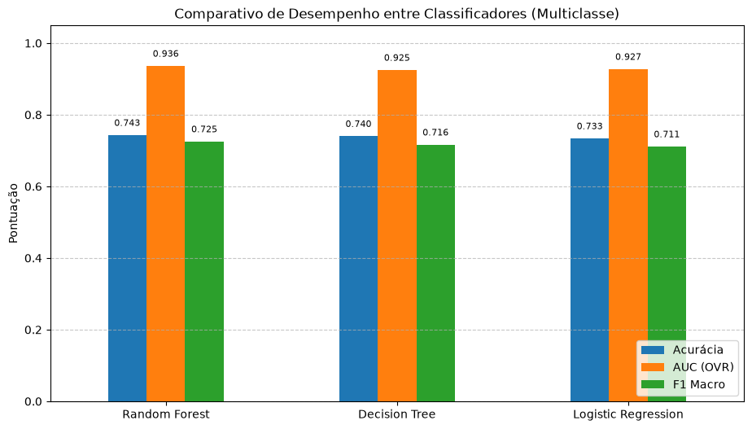

```python
df_comparativo_classifier = pd.DataFrame(comparativo_modelos_classifier).T

df_comparativo_classifier.plot(kind='bar', figsize=(11, 6), ylim=(0, 1.05))
plt.title('Comparativo de Desempenho entre Classificadores (Multiclasse)')
plt.ylabel('Pontuação')
plt.xticks(rotation=0)
plt.legend(loc='lower right')
plt.grid(axis='y', linestyle='--', alpha=0.7)

for p in plt.gca().patches:
  plt.gca().annotate(
      f'{p.get_height():.3f}',
      (p.get_x() + p.get_width() / 2., p.get_height() + 0.02),
      ha='center',
      va='bottom',
      fontsize=8)

plt.show()
```

### Regressão

```python
colunas_numericas = ['area', 'rooms', 'bathroom', 'parking spaces', 'furniture', 'apartamento', 'condominio']
x_global = segmentacao_final[colunas_numericas + ['cluster']].copy()


x_global[colunas_numericas] = x_global[colunas_numericas].astype(float)
y_global = segmentacao_final['total'].astype(float)

x_train_global, x_test_global, y_train_global, y_test_global = train_test_split(x_global, y_global, test_size=0.2, random_state=42, stratify=x_global['cluster'])

x_train_global_2 = x_train_global.drop(columns=['cluster'])
x_test_global_2 = x_test_global.drop(columns=['cluster'])
```

```python
comparativo_modelos_regressor = {}
```

#### Modelos Globais

##### Baseline | Dummy Regressor

```python
from sklearn.dummy import DummyRegressor

x_train = x_train_global_2.copy()
x_test = x_test_global_2.copy()
y_train = y_train_global.copy()
y_test = y_test_global.copy()

model_dummy = DummyRegressor(strategy='mean')
model_dummy.fit(x_train, y_train)

dummy_reg = results = model_dummy
```

```python
y_train_pred = results.predict(x_train)
y_test_pred = results.predict(x_test)

print("Metricas Gerais: Treino e Teste")
print(f"R-Quadrado (Treino): {r2_score(y_train, y_train_pred)}")
print(f"R-Quadrado (Teste):  {r2_score(y_test, y_test_pred)}")
print(f'MAE (Treino): {mean_absolute_error(y_train, y_train_pred)}')
print(f'MAE (Teste): {mean_absolute_error(y_test, y_test_pred)}')
print(f"RMSE (Treino): {root_mean_squared_error(y_train, y_train_pred)}")
print(f"RMSE (Teste):  {root_mean_squared_error(y_test, y_test_pred)}")

comparativo_modelos_regressor['Baseline | Dummy Regressor'] = {'R²': r2_score(y_test, y_test_pred),
                                                     'MAE': mean_absolute_error(y_test, y_test_pred),
                                                     'RMSE': root_mean_squared_error(y_test, y_test_pred),
                                                      'MAPE': mean_absolute_percentage_error(y_test, y_test_pred)}
```

```
Metricas Gerais: Treino e Teste
R-Quadrado (Treino): 0.0
R-Quadrado (Teste):  -0.003175039086976028
MAE (Treino): 3521.875492537731
MAE (Teste): 3681.7208968465447
RMSE (Treino): 4506.203050724286
RMSE (Teste):  4827.993610853108
```

##### Regressão Linear

```python
x_train = x_train_global_2.copy()
x_test = x_test_global_2.copy()
y_train = y_train_global.copy()
y_test = y_test_global.copy()


kf = KFold(n_splits=5, shuffle=True, random_state=42)

vacc = []

for train_index, validation_index in kf.split(x_train, y_train):
    x_train_cv = x_train.iloc[train_index, :]
    y_train_cv = y_train.iloc[train_index]

    x_val_cv = x_train.iloc[validation_index, :]
    y_val_cv = y_train.iloc[validation_index]

    robust_scaler = RobustScaler()
    x_train_cv = robust_scaler.fit_transform(x_train_cv)
    x_val_cv = robust_scaler.transform(x_val_cv)

    x_train_cv = add_constant(x_train_cv)
    x_val_cv = add_constant(x_val_cv)

    model = OLS(y_train_cv, x_train_cv)
    results = model.fit()

    vacc.append(results.rsquared_adj)

print(vacc)
print(f'Média do RSquared ajutado: {np.mean(vacc)}')


x_train = robust_scaler.fit_transform(x_train)
x_test = robust_scaler.transform(x_test)

x_train = add_constant(x_train)
x_test = add_constant(x_test)

model = OLS(y_train, x_train)
results = model.fit()
print(results.summary())
```

```
[np.float64(0.6334247777554713), np.float64(0.6400975180557134), np.float64(0.6361394288051448), np.float64(0.6313126802184483), np.float64(0.6444073294298696)]
Média do RSquared ajutado: 0.6370763468529294
                            OLS Regression Results
==============================================================================
Dep. Variable:                  total   R-squared:                       0.638
Model:                            OLS   Adj. R-squared:                  0.637
Method:                 Least Squares   F-statistic:                     1144.
Date:                Tue, 08 Sep 2026   Prob (F-statistic):               0.00
Time:                        22:42:50   Log-Likelihood:                -42530.
No. Observations:                4561   AIC:                         8.508e+04
Df Residuals:                    4553   BIC:                         8.513e+04
Df Model:                           7
Covariance Type:            nonrobust
==============================================================================
                 coef    std err          t      P>|t|      [0.025      0.975]
------------------------------------------------------------------------------
const       4722.8708     71.114     66.413      0.000    4583.453    4862.289
x1          3026.9188     93.139     32.499      0.000    2844.321    3209.517
x2          -117.6228     59.016     -1.993      0.046    -233.323      -1.922
x3          1629.0191    106.082     15.356      0.000    1421.046    1836.992
x4           354.0561     38.400      9.220      0.000     278.773     429.339
x5          1342.4043     93.990     14.282      0.000    1158.139    1526.670
x6          2146.7070    194.464     11.039      0.000    1765.464    2527.950
x7           919.6592    196.723      4.675      0.000     533.986    1305.332
==============================================================================
Omnibus:                      570.655   Durbin-Watson:                   2.012
Prob(Omnibus):                  0.000   Jarque-Bera (JB):             1287.843
Skew:                           0.745   Prob(JB):                    2.23e-280
Kurtosis:                       5.135   Cond. No.                         13.4
==============================================================================

Notes:
[1] Standard Errors assume that the covariance matrix of the errors is correctly specified.
```

```python
y_train_pred = results.predict(x_train)
y_test_pred = results.predict(x_test)

print("Metricas Gerais: Treino e Teste")
print(f"R-Quadrado (Treino): {r2_score(y_train, y_train_pred)}")
print(f"R-Quadrado (Teste):  {r2_score(y_test, y_test_pred)}")
print(f'MAE (Treino): {mean_absolute_error(y_train, y_train_pred)}')
print(f'MAE (Teste): {mean_absolute_error(y_test, y_test_pred)}')
print(f"RMSE (Treino): {root_mean_squared_error(y_train, y_train_pred)}")
print(f"RMSE (Teste):  {root_mean_squared_error(y_test, y_test_pred)}")

comparativo_modelos_regressor['Regressão Linear'] = {'R²': r2_score(y_test, y_test_pred),
                                                     'MAE': mean_absolute_error(y_test, y_test_pred),
                                                     'RMSE': root_mean_squared_error(y_test, y_test_pred),
                                                      'MAPE': mean_absolute_percentage_error(y_test, y_test_pred)}
```

```
Metricas Gerais: Treino e Teste
R-Quadrado (Treino): 0.6375691462517485
R-Quadrado (Teste):  0.6146151173025416
MAE (Treino): 1973.6544524950875
MAE (Teste): 2123.999779769151
RMSE (Treino): 2712.834740024997
RMSE (Teste):  2992.441474499888
```

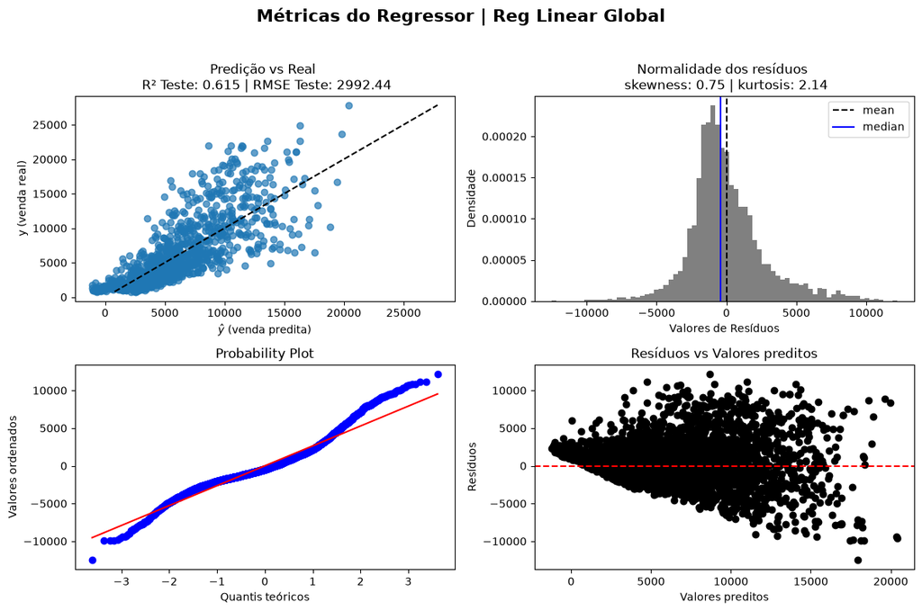

```python
plt.figure(figsize=(12, 8))
plt.suptitle('Métricas do Regressor | Reg Linear Global', fontsize=16, fontweight='bold')

plt.subplot(2, 2, 1)
plt.scatter(y_test_pred, y_test, alpha=0.7)
plt.plot([(min(y_test)), (max(y_test))], [(min(y_test)), (max(y_test))], linestyle='--', color='black')
plt.title(f'Predição vs Real \n R² Teste: {round(r2_score(y_test, y_test_pred),3)} | RMSE Teste: {round(root_mean_squared_error(y_test, y_test_pred),2)}')
plt.ylabel('y (venda real)')
plt.xlabel(r"$\hat{y}$ (venda predita)")

plt.subplot(2, 2, 2)
residuos = results.resid
plt.title(f'Normalidade dos resíduos \n skewness: {round(residuos.skew(),2)} | kurtosis: {round(residuos.kurtosis(),2)}')
plt.hist(residuos, bins='auto', density=True, color='gray')
plt.axvline(residuos.mean(), label='mean', linestyle='--', color='black')
plt.axvline(residuos.median(), label='median', linestyle='-', color='blue')
plt.legend()
plt.ylabel('Densidade')
plt.xlabel('Valores de Resíduos')

plt.subplot(2, 2, 3)
import scipy.stats as stats
stats.probplot(residuos.sort_values(), dist="norm",plot=plt)
plt.xlabel('Quantis teóricos', fontsize = 10)
plt.ylabel('Valores ordenados',fontsize = 10)

plt.subplot(2, 2, 4)
plt.scatter(results.predict(x_train), residuos,color='black')
plt.axhline(y = 0, color = 'red', linestyle = '--')
plt.title('Resíduos vs Valores preditos')
plt.xlabel('Valores preditos',fontsize = 10)
plt.ylabel('Resíduos', fontsize = 10)

plt.tight_layout(rect=[0, 0, 1, 0.96])
plt.show()
```

##### Ridge

```python
x_train = x_train_global_2.copy()
x_test = x_test_global_2.copy()
y_train = y_train_global.copy()
y_test = y_test_global.copy()

pipeline = Pipeline([
    ('scaler', RobustScaler()),
    ('ridge', Ridge(random_state=42))
])

param_grid = {
    'ridge__alpha': np.logspace(-3, 2, 50),
    'ridge__solver': ['auto', 'svd', 'lsqr']
}

cv = KFold(
    n_splits=5,
    shuffle=True,
    random_state=42)

grid_search = GridSearchCV(
    estimator=pipeline,
    param_grid=param_grid,
    scoring='neg_mean_squared_error',
    cv=cv,
    n_jobs=-1,
    return_train_score=True,
    refit=True)

grid_search.fit(x_train, y_train)
```

```
GridSearchCV(cv=KFold(n_splits=5, random_state=42, shuffle=True),
             estimator=Pipeline(steps=[('scaler', RobustScaler()),
                                       ('ridge', Ridge(random_state=42))]),
             n_jobs=-1,
             param_grid={'ridge__alpha': array([1.00000000e-03, 1.26485522e-03, 1.59985872e-03, 2.02358965e-03,
       2.55954792e-03, 3.23745754e-03, 4.09491506e-03, 5.17947468e-03,
       6.55128557e-03, 8.28642773e-03, 1.0481...
       1.84206997e+00, 2.32995181e+00, 2.94705170e+00, 3.72759372e+00,
       4.71486636e+00, 5.96362332e+00, 7.54312006e+00, 9.54095476e+00,
       1.20679264e+01, 1.52641797e+01, 1.93069773e+01, 2.44205309e+01,
       3.08884360e+01, 3.90693994e+01, 4.94171336e+01, 6.25055193e+01,
       7.90604321e+01, 1.00000000e+02]),
                         'ridge__solver': ['auto', 'svd', 'lsqr']},
             return_train_score=True, scoring='neg_mean_squared_error')
```

```python
results = None
best_ridge = results = grid_search.best_estimator_
print('Melhores hiperparâmetros:', grid_search.best_params_)

best_index = grid_search.best_index_
mse_val = -grid_search.cv_results_['mean_test_score'][best_index]
rmse_val = np.sqrt(mse_val)
mse_train_cv = -grid_search.cv_results_['mean_train_score'][best_index]
rmse_train_cv = np.sqrt(mse_train_cv)

print("--- Métricas de Validação Cruzada (Opção 1) ---")
print(f"RMSE (Validação Média dos Folds): {rmse_val}")
print(f"RMSE (Treino Médio dos Folds):    {rmse_train_cv}")
```

```
Melhores hiperparâmetros: {'ridge__alpha': np.float64(3.7275937203149416), 'ridge__solver': 'auto'}
--- Métricas de Validação Cruzada (Opção 1) ---
RMSE (Validação Média dos Folds): 2721.065686995445
RMSE (Treino Médio dos Folds):    2711.9361745098554
```

```python
y_train_pred = results.predict(x_train)
y_test_pred = results.predict(x_test)

print("Metricas Gerais: Treino e Teste")
print(f"R-Quadrado (Treino): {r2_score(y_train, y_train_pred)}")
print(f"R-Quadrado (Teste):  {r2_score(y_test, y_test_pred)}")
print(f'MAE (Treino): {mean_absolute_error(y_train, y_train_pred)}')
print(f'MAE (Teste): {mean_absolute_error(y_test, y_test_pred)}')
print(f"RMSE (Treino): {root_mean_squared_error(y_train, y_train_pred)}")
print(f"RMSE (Teste):  {root_mean_squared_error(y_test, y_test_pred)}")

comparativo_modelos_regressor['Ridge'] = {'R²': r2_score(y_test, y_test_pred),
                                                     'MAE': mean_absolute_error(y_test, y_test_pred),
                                                     'RMSE': root_mean_squared_error(y_test, y_test_pred),
                                                      'MAPE': mean_absolute_percentage_error(y_test, y_test_pred)}
```

```
Metricas Gerais: Treino e Teste
R-Quadrado (Treino): 0.6375658137741547
R-Quadrado (Teste):  0.6145292378201097
MAE (Treino): 1973.0139213348275
MAE (Teste): 2123.530678956103
RMSE (Treino): 2712.847211976698
RMSE (Teste):  2992.774874979827
```

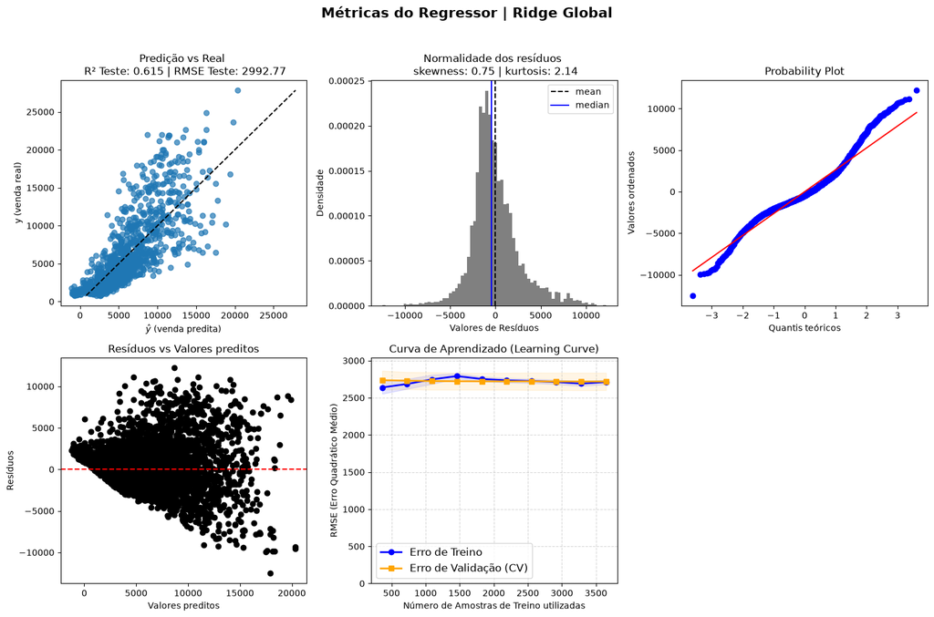

```python
plt.figure(figsize=(15, 10))
plt.suptitle('Métricas do Regressor | Ridge Global', fontsize=16, fontweight='bold')


plt.subplot(2, 3, 1)
plt.scatter(y_test_pred, y_test, alpha=0.7)
plt.plot([(min(y_test)), (max(y_test))], [(min(y_test)), (max(y_test))], linestyle='--', color='black')
plt.title(f'Predição vs Real \n R² Teste: {round(r2_score(y_test, y_test_pred),3)} | RMSE Teste: {round(root_mean_squared_error(y_test, y_test_pred),2)}')
plt.ylabel('y (venda real)')
plt.xlabel(r"$\hat{y}$ (venda predita)")

plt.subplot(2, 3, 2)
residuos = y_train - y_train_pred
plt.title(f'Normalidade dos resíduos \n skewness: {round(residuos.skew(),2)} | kurtosis: {round(residuos.kurtosis(),2)}')
plt.hist(residuos, bins='auto', density=True, color='gray')
plt.axvline(residuos.mean(), label='mean', linestyle='--', color='black')
plt.axvline(residuos.median(), label='median', linestyle='-', color='blue')
plt.legend()
plt.ylabel('Densidade')
plt.xlabel('Valores de Resíduos')

plt.subplot(2, 3, 3)
import scipy.stats as stats
stats.probplot(residuos.sort_values(), dist="norm",plot=plt)
plt.xlabel('Quantis teóricos', fontsize = 10)
plt.ylabel('Valores ordenados',fontsize = 10)

plt.subplot(2, 3, 4)
plt.scatter(results.predict(x_train), residuos,color='black')
plt.axhline(y = 0, color = 'red', linestyle = '--')
plt.title('Resíduos vs Valores preditos')
plt.xlabel('Valores preditos',fontsize = 10)
plt.ylabel('Resíduos', fontsize = 10)



plt.subplot(2,3,5)
train_sizes, train_scores, val_scores = learning_curve(
    estimator=results,
    X=x_train,
    y=y_train,
    train_sizes=np.linspace(0.1, 1.0, 10),
    cv=cv,
    scoring='neg_root_mean_squared_error',
    n_jobs=-1)
plt.plot(train_sizes, (-train_scores.mean(axis=1)), 'o-', color="blue", label="Erro de Treino", linewidth=2)
plt.fill_between(train_sizes, (-train_scores.mean(axis=1)) - (-train_scores.std(axis=1)), (-train_scores.mean(axis=1)) + (-train_scores.std(axis=1)), alpha=0.1, color="blue")
plt.plot(train_sizes, (-val_scores.mean(axis=1)), 's-', color="orange", label="Erro de Validação (CV)", linewidth=2)
plt.fill_between(train_sizes, (-val_scores.mean(axis=1)) - (-val_scores.std(axis=1)), (-val_scores.mean(axis=1)) + (-val_scores.std(axis=1)), alpha=0.1, color="orange")
limite_superior = max((-train_scores.mean(axis=1)).max() + (-train_scores.std(axis=1)).max(), (-val_scores.mean(axis=1)).max() + (-val_scores.std(axis=1)).max())
plt.ylim(0, limite_superior * 1.1)
plt.title('Curva de Aprendizado (Learning Curve)')
plt.xlabel('Número de Amostras de Treino utilizadas')
plt.ylabel('RMSE (Erro Quadrático Médio)')
plt.grid(True, linestyle='--', alpha=0.5)
plt.legend(fontsize=12, loc="best")

plt.tight_layout(rect=[0, 0, 1, 0.96])
plt.show()
```

##### Lasso

```python
x_train = x_train_global_2.copy()
x_test = x_test_global_2.copy()
y_train = y_train_global.copy()
y_test = y_test_global.copy()

pipeline = Pipeline([
    ('scaler', RobustScaler()),
    ('lasso', Lasso(random_state=42, max_iter=2000))
])

param_grid = {
    'lasso__alpha': np.logspace(-3, 2, 50),
    'lasso__selection': ['cyclic', 'random']
}

cv = KFold(
    n_splits=5,
    shuffle=True,
    random_state=42)

grid_search = GridSearchCV(
    estimator=pipeline,
    param_grid=param_grid,
    scoring='neg_mean_squared_error',
    cv=cv,
    n_jobs=-1,
    return_train_score=True,
    refit=True)

grid_search.fit(x_train, y_train)
```

```
GridSearchCV(cv=KFold(n_splits=5, random_state=42, shuffle=True),
             estimator=Pipeline(steps=[('scaler', RobustScaler()),
                                       ('lasso',
                                        Lasso(max_iter=2000,
                                              random_state=42))]),
             n_jobs=-1,
             param_grid={'lasso__alpha': array([1.00000000e-03, 1.26485522e-03, 1.59985872e-03, 2.02358965e-03,
       2.55954792e-03, 3.23745754e-03, 4.09491506e-03, 5.17947468e-03,
       6.55128557e-03, 8.28642...
       1.84206997e+00, 2.32995181e+00, 2.94705170e+00, 3.72759372e+00,
       4.71486636e+00, 5.96362332e+00, 7.54312006e+00, 9.54095476e+00,
       1.20679264e+01, 1.52641797e+01, 1.93069773e+01, 2.44205309e+01,
       3.08884360e+01, 3.90693994e+01, 4.94171336e+01, 6.25055193e+01,
       7.90604321e+01, 1.00000000e+02]),
                         'lasso__selection': ['cyclic', 'random']},
             return_train_score=True, scoring='neg_mean_squared_error')
```

```python
results = None
best_lasso = results = grid_search.best_estimator_
print('Melhores hiperparâmetros:', grid_search.best_params_)

best_index = grid_search.best_index_
mse_val = -grid_search.cv_results_['mean_test_score'][best_index]
rmse_val = np.sqrt(mse_val)
mse_train_cv = -grid_search.cv_results_['mean_train_score'][best_index]
rmse_train_cv = np.sqrt(mse_train_cv)

print("--- Métricas de Validação Cruzada (Opção 1) ---")
print(f"RMSE (Validação Média dos Folds): {rmse_val}")
print(f"RMSE (Treino Médio dos Folds):    {rmse_train_cv}")
```

```
Melhores hiperparâmetros: {'lasso__alpha': np.float64(0.10985411419875583), 'lasso__selection': 'random'}
--- Métricas de Validação Cruzada (Opção 1) ---
RMSE (Validação Média dos Folds): 2721.0872217991264
RMSE (Treino Médio dos Folds):    2711.9169892174755
```

```python
y_train_pred = results.predict(x_train)
y_test_pred = results.predict(x_test)

print("Metricas Gerais: Treino e Teste")
print(f"R-Quadrado (Treino): {r2_score(y_train, y_train_pred)}")
print(f"R-Quadrado (Teste):  {r2_score(y_test, y_test_pred)}")
print(f'MAE (Treino): {mean_absolute_error(y_train, y_train_pred)}')
print(f'MAE (Teste): {mean_absolute_error(y_test, y_test_pred)}')
print(f"RMSE (Treino): {root_mean_squared_error(y_train, y_train_pred)}")
print(f"RMSE (Teste):  {root_mean_squared_error(y_test, y_test_pred)}")

comparativo_modelos_regressor['Lasso'] = {'R²': r2_score(y_test, y_test_pred),
                                                     'MAE': mean_absolute_error(y_test, y_test_pred),
                                                     'RMSE': root_mean_squared_error(y_test, y_test_pred),
                                                      'MAPE': mean_absolute_percentage_error(y_test, y_test_pred)}
```

```
Metricas Gerais: Treino e Teste
R-Quadrado (Treino): 0.6375691337224866
R-Quadrado (Teste):  0.614613107176167
MAE (Treino): 1973.6339364120117
MAE (Teste): 2123.9972352365075
RMSE (Treino): 2712.8347869164472
RMSE (Teste):  2992.4492786172245
```

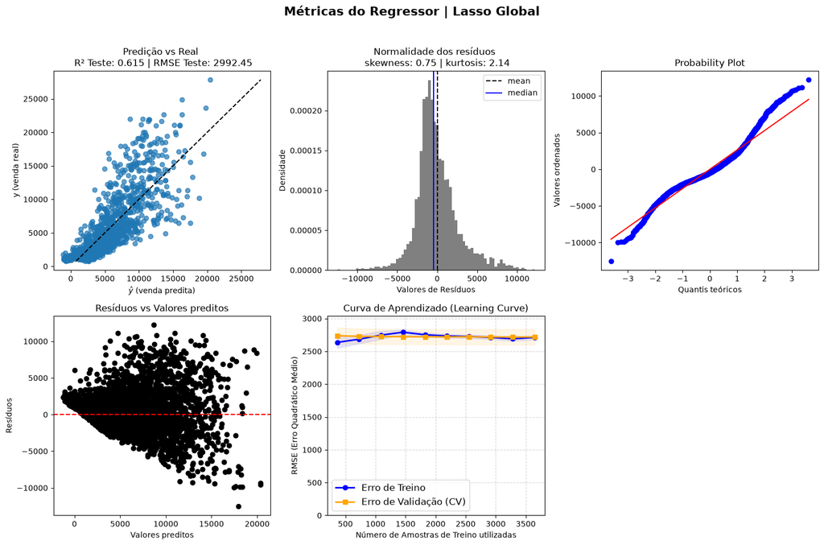

```python
plt.figure(figsize=(15, 10))
plt.suptitle('Métricas do Regressor | Lasso Global', fontsize=16, fontweight='bold')

plt.subplot(2, 3, 1)
plt.scatter(y_test_pred, y_test, alpha=0.7)
plt.plot([(min(y_test)), (max(y_test))], [(min(y_test)), (max(y_test))], linestyle='--', color='black')
plt.title(f'Predição vs Real \n R² Teste: {round(r2_score(y_test, y_test_pred),3)} | RMSE Teste: {round(root_mean_squared_error(y_test, y_test_pred),2)}')
plt.ylabel('y (venda real)')
plt.xlabel(r"$\hat{y}$ (venda predita)")

plt.subplot(2, 3, 2)
residuos = y_train - y_train_pred
plt.title(f'Normalidade dos resíduos \n skewness: {round(residuos.skew(),2)} | kurtosis: {round(residuos.kurtosis(),2)}')
plt.hist(residuos, bins='auto', density=True, color='gray')
plt.axvline(residuos.mean(), label='mean', linestyle='--', color='black')
plt.axvline(residuos.median(), label='median', linestyle='-', color='blue')
plt.legend()
plt.ylabel('Densidade')
plt.xlabel('Valores de Resíduos')

plt.subplot(2, 3, 3)
import scipy.stats as stats
stats.probplot(residuos.sort_values(), dist="norm",plot=plt)
plt.xlabel('Quantis teóricos', fontsize = 10)
plt.ylabel('Valores ordenados',fontsize = 10)

plt.subplot(2, 3, 4)
plt.scatter(results.predict(x_train), residuos,color='black')
plt.axhline(y = 0, color = 'red', linestyle = '--')
plt.title('Resíduos vs Valores preditos')
plt.xlabel('Valores preditos',fontsize = 10)
plt.ylabel('Resíduos', fontsize = 10)



plt.subplot(2,3,5)
train_sizes, train_scores, val_scores = learning_curve(
    estimator=results,
    X=x_train,
    y=y_train,
    train_sizes=np.linspace(0.1, 1.0, 10),
    cv=cv,
    scoring='neg_root_mean_squared_error',
    n_jobs=-1)
plt.plot(train_sizes, (-train_scores.mean(axis=1)), 'o-', color="blue", label="Erro de Treino", linewidth=2)
plt.fill_between(train_sizes, (-train_scores.mean(axis=1)) - (-train_scores.std(axis=1)), (-train_scores.mean(axis=1)) + (-train_scores.std(axis=1)), alpha=0.1, color="blue")
plt.plot(train_sizes, (-val_scores.mean(axis=1)), 's-', color="orange", label="Erro de Validação (CV)", linewidth=2)
plt.fill_between(train_sizes, (-val_scores.mean(axis=1)) - (-val_scores.std(axis=1)), (-val_scores.mean(axis=1)) + (-val_scores.std(axis=1)), alpha=0.1, color="orange")
limite_superior = max((-train_scores.mean(axis=1)).max() + (-train_scores.std(axis=1)).max(), (-val_scores.mean(axis=1)).max() + (-val_scores.std(axis=1)).max())
plt.ylim(0, limite_superior * 1.1)
plt.title('Curva de Aprendizado (Learning Curve)')
plt.xlabel('Número de Amostras de Treino utilizadas')
plt.ylabel('RMSE (Erro Quadrático Médio)')
plt.grid(True, linestyle='--', alpha=0.5)
plt.legend(fontsize=12, loc="best")

plt.tight_layout(rect=[0, 0, 1, 0.96])
plt.show()
```

##### Decision Tree

```python
x_train = x_train_global_2.copy()
x_test = x_test_global_2.copy()
y_train = y_train_global.copy()
y_test = y_test_global.copy()

tree = DecisionTreeRegressor(random_state=42)

param_grid = {
    "criterion": ["squared_error", "friedman_mse", "absolute_error"],
    "max_depth": [3, 5, 7],
    "min_samples_split": [6, 10, 30, 60],
    "min_samples_leaf": [3, 5, 15, 30],
    "max_features": [None, "sqrt", "log2"],
    }

cv = KFold(
    n_splits=5,
    shuffle=True,
    random_state=42)

grid_search = GridSearchCV(
    estimator=tree,
    param_grid=param_grid,
    scoring='neg_mean_squared_error',
    cv=cv,
    n_jobs=-1,
    verbose=1,
    return_train_score=True,
    refit=True)

grid_search.fit(x_train, y_train)
```

```
Fitting 5 folds for each of 432 candidates, totalling 2160 fits
```

```
GridSearchCV(cv=KFold(n_splits=5, random_state=42, shuffle=True),
             estimator=DecisionTreeRegressor(random_state=42), n_jobs=-1,
             param_grid={'criterion': ['squared_error', 'friedman_mse',
                                       'absolute_error'],
                         'max_depth': [3, 5, 7],
                         'max_features': [None, 'sqrt', 'log2'],
                         'min_samples_leaf': [3, 5, 15, 30],
                         'min_samples_split': [6, 10, 30, 60]},
             return_train_score=True, scoring='neg_mean_squared_error',
             verbose=1)
```

```python
results = None
best_tree_reg = results = grid_search.best_estimator_
print('Melhores hiperparâmetros:', grid_search.best_params_)

best_index = grid_search.best_index_
mse_val = -grid_search.cv_results_['mean_test_score'][best_index]
rmse_val = np.sqrt(mse_val)
mse_train_cv = -grid_search.cv_results_['mean_train_score'][best_index]
rmse_train_cv = np.sqrt(mse_train_cv)

print("--- Métricas de Validação Cruzada (Opção 1) ---")
print(f"RMSE (Validação Média dos Folds): {rmse_val}")
print(f"RMSE (Treino Médio dos Folds):    {rmse_train_cv}")
```

```
Melhores hiperparâmetros: {'criterion': 'squared_error', 'max_depth': 7, 'max_features': None, 'min_samples_leaf': 30, 'min_samples_split': 6}
--- Métricas de Validação Cruzada (Opção 1) ---
RMSE (Validação Média dos Folds): 2608.8441470102875
RMSE (Treino Médio dos Folds):    2468.6543631682302
```

```python
y_train_pred = results.predict(x_train)
y_test_pred = results.predict(x_test)

print("Metricas Gerais: Treino e Teste")
print(f"R-Quadrado (Treino): {r2_score(y_train, y_train_pred)}")
print(f"R-Quadrado (Teste):  {r2_score(y_test, y_test_pred)}")
print(f'MAE (Treino): {mean_absolute_error(y_train, y_train_pred)}')
print(f'MAE (Teste): {mean_absolute_error(y_test, y_test_pred)}')
print(f"RMSE (Treino): {root_mean_squared_error(y_train, y_train_pred)}")
print(f"RMSE (Teste):  {root_mean_squared_error(y_test, y_test_pred)}")

comparativo_modelos_regressor['Decision Tree'] = {'R²': r2_score(y_test, y_test_pred),
                                                      'MAE': mean_absolute_error(y_test, y_test_pred),
                                                      'RMSE': root_mean_squared_error(y_test, y_test_pred),
                                                      'MAPE': mean_absolute_percentage_error(y_test, y_test_pred)}
```

```
Metricas Gerais: Treino e Teste
R-Quadrado (Treino): 0.7044111932886148
R-Quadrado (Teste):  0.6706401610081336
MAE (Treino): 1707.2726444962082
MAE (Teste): 1891.3925205877404
RMSE (Treino): 2449.9360564671706
RMSE (Teste):  2766.3915461758756
```

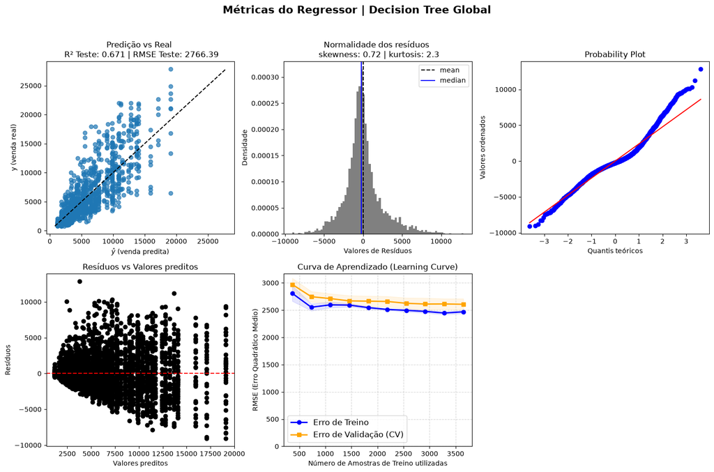

```python
plt.figure(figsize=(15, 10))
plt.suptitle('Métricas do Regressor | Decision Tree Global', fontsize=16, fontweight='bold')

plt.subplot(2, 3, 1)
plt.scatter(y_test_pred, y_test, alpha=0.7)
plt.plot([(min(y_test)), (max(y_test))], [(min(y_test)), (max(y_test))], linestyle='--', color='black')
plt.title(f'Predição vs Real \n R² Teste: {round(r2_score(y_test, y_test_pred),3)} | RMSE Teste: {round(root_mean_squared_error(y_test, y_test_pred),2)}')
plt.ylabel('y (venda real)')
plt.xlabel(r"$\hat{y}$ (venda predita)")

plt.subplot(2, 3, 2)
residuos = y_train - y_train_pred
plt.title(f'Normalidade dos resíduos \n skewness: {round(residuos.skew(),2)} | kurtosis: {round(residuos.kurtosis(),2)}')
plt.hist(residuos, bins='auto', density=True, color='gray')
plt.axvline(residuos.mean(), label='mean', linestyle='--', color='black')
plt.axvline(residuos.median(), label='median', linestyle='-', color='blue')
plt.legend()
plt.ylabel('Densidade')
plt.xlabel('Valores de Resíduos')

plt.subplot(2, 3, 3)
import scipy.stats as stats
stats.probplot(residuos.sort_values(), dist="norm",plot=plt)
plt.xlabel('Quantis teóricos', fontsize = 10)
plt.ylabel('Valores ordenados',fontsize = 10)

plt.subplot(2, 3, 4)
plt.scatter(results.predict(x_train), residuos,color='black')
plt.axhline(y = 0, color = 'red', linestyle = '--')
plt.title('Resíduos vs Valores preditos')
plt.xlabel('Valores preditos',fontsize = 10)
plt.ylabel('Resíduos', fontsize = 10)



plt.subplot(2,3,5)
train_sizes, train_scores, val_scores = learning_curve(
    estimator=results,
    X=x_train,
    y=y_train,
    train_sizes=np.linspace(0.1, 1.0, 10),
    cv=cv,
    scoring='neg_root_mean_squared_error',
    n_jobs=-1)
plt.plot(train_sizes, (-train_scores.mean(axis=1)), 'o-', color="blue", label="Erro de Treino", linewidth=2)
plt.fill_between(train_sizes, (-train_scores.mean(axis=1)) - (-train_scores.std(axis=1)), (-train_scores.mean(axis=1)) + (-train_scores.std(axis=1)), alpha=0.1, color="blue")
plt.plot(train_sizes, (-val_scores.mean(axis=1)), 's-', color="orange", label="Erro de Validação (CV)", linewidth=2)
plt.fill_between(train_sizes, (-val_scores.mean(axis=1)) - (-val_scores.std(axis=1)), (-val_scores.mean(axis=1)) + (-val_scores.std(axis=1)), alpha=0.1, color="orange")
limite_superior = max((-train_scores.mean(axis=1)).max() + (-train_scores.std(axis=1)).max(), (-val_scores.mean(axis=1)).max() + (-val_scores.std(axis=1)).max())
plt.ylim(0, limite_superior * 1.1)
plt.title('Curva de Aprendizado (Learning Curve)')
plt.xlabel('Número de Amostras de Treino utilizadas')
plt.ylabel('RMSE (Erro Quadrático Médio)')
plt.grid(True, linestyle='--', alpha=0.5)
plt.legend(fontsize=12, loc="best")

plt.tight_layout(rect=[0, 0, 1, 0.96])
plt.show()
```

##### Random Forest

```python
x_train = x_train_global_2.copy()
x_test = x_test_global_2.copy()
y_train = y_train_global.copy()
y_test = y_test_global.copy()

rf = RandomForestRegressor(random_state=42)

param_grid = {
    'n_estimators': [100, 200, 300],
    'max_depth': [None, 3, 5, 7],
    'max_features': [0.5, 1.0, 'sqrt', 'log2']}

cv = KFold(
    n_splits=5,
    shuffle=True,
    random_state=42)

grid_search = GridSearchCV(
    estimator=rf,
    param_grid=param_grid,
    scoring='neg_mean_squared_error',
    cv=cv,
    n_jobs=-1,
    verbose=1,
    return_train_score=True,
    refit=True)

grid_search.fit(x_train, y_train)
```

```
Fitting 5 folds for each of 48 candidates, totalling 240 fits
```

```
GridSearchCV(cv=KFold(n_splits=5, random_state=42, shuffle=True),
             estimator=RandomForestRegressor(random_state=42), n_jobs=-1,
             param_grid={'max_depth': [None, 3, 5, 7],
                         'max_features': [0.5, 1.0, 'sqrt', 'log2'],
                         'n_estimators': [100, 200, 300]},
             return_train_score=True, scoring='neg_mean_squared_error',
             verbose=1)
```

```python
results = None
best_rf_reg = results = grid_search.best_estimator_

print('Melhores hiperparâmetros:', grid_search.best_params_)

best_index = grid_search.best_index_

mse_val = -grid_search.cv_results_['mean_test_score'][best_index]

rmse_val = np.sqrt(mse_val)

mse_train_cv = -grid_search.cv_results_['mean_train_score'][best_index]
rmse_train_cv = np.sqrt(mse_train_cv)

print("--- Métricas de Validação Cruzada (Opção 1) ---")
print(f"RMSE (Validação Média dos Folds): {rmse_val}")
print(f"RMSE (Treino Médio dos Folds):    {rmse_train_cv}")
```

```
Melhores hiperparâmetros: {'max_depth': 7, 'max_features': 0.5, 'n_estimators': 100}
--- Métricas de Validação Cruzada (Opção 1) ---
RMSE (Validação Média dos Folds): 2512.1243969609513
RMSE (Treino Médio dos Folds):    2255.9934826344484
```

```python
y_train_pred = results.predict(x_train)
y_test_pred = results.predict(x_test)

print("Metricas Gerais: Treino e Teste")
print(f"R-Quadrado (Treino): {r2_score(y_train, y_train_pred)}")
print(f"R-Quadrado (Teste):  {r2_score(y_test, y_test_pred)}")
print(f'MAE (Treino): {mean_absolute_error(y_train, y_train_pred)}')
print(f'MAE (Teste): {mean_absolute_error(y_test, y_test_pred)}')
print(f"RMSE (Treino): {root_mean_squared_error(y_train, y_train_pred)}")
print(f"RMSE (Teste):  {root_mean_squared_error(y_test, y_test_pred)}")

comparativo_modelos_regressor['Random Forest'] = {'R²': r2_score(y_test, y_test_pred),
                                                     'MAE': mean_absolute_error(y_test, y_test_pred),
                                                     'RMSE': root_mean_squared_error(y_test, y_test_pred),
                                                      'MAPE': mean_absolute_percentage_error(y_test, y_test_pred)}
```

```
Metricas Gerais: Treino e Teste
R-Quadrado (Treino): 0.7423529141004467
R-Quadrado (Teste):  0.681979502804043
MAE (Treino): 1620.1025154172858
MAE (Teste): 1856.9766317495692
RMSE (Treino): 2287.301288561272
RMSE (Teste):  2718.353196228745
```

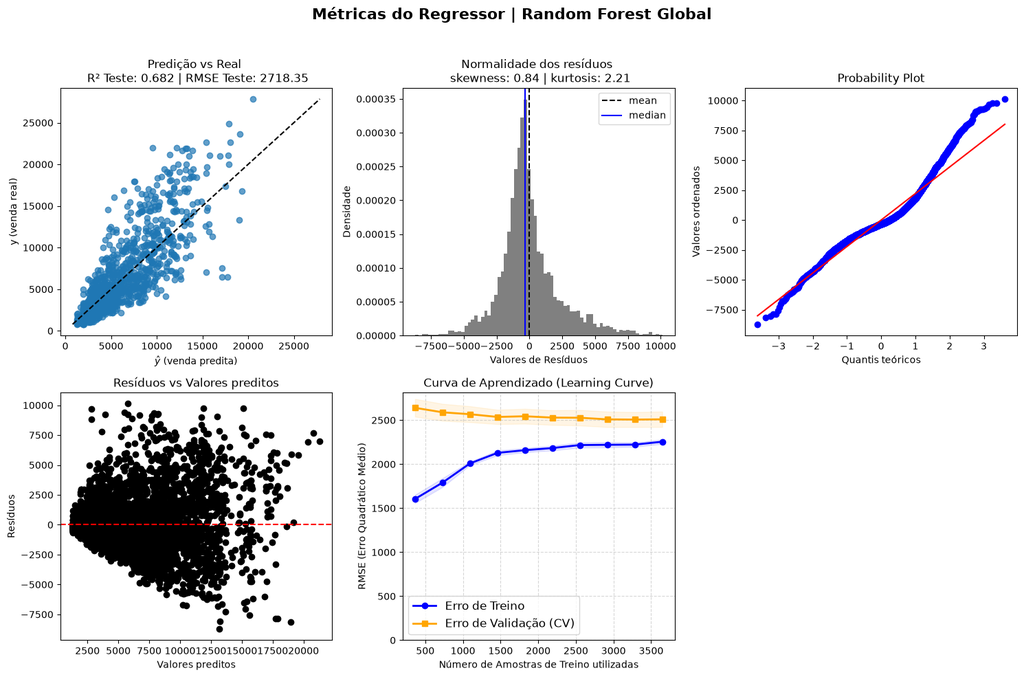

```python
plt.figure(figsize=(15, 10))
plt.suptitle('Métricas do Regressor | Random Forest Global', fontsize=16, fontweight='bold')

plt.subplot(2, 3, 1)
plt.scatter(y_test_pred, y_test, alpha=0.7)
plt.plot([(min(y_test)), (max(y_test))], [(min(y_test)), (max(y_test))], linestyle='--', color='black')
plt.title(f'Predição vs Real \n R² Teste: {round(r2_score(y_test, y_test_pred),3)} | RMSE Teste: {round(root_mean_squared_error(y_test, y_test_pred),2)}')
plt.ylabel('y (venda real)')
plt.xlabel(r"$\hat{y}$ (venda predita)")

plt.subplot(2, 3, 2)
residuos = y_train - y_train_pred
plt.title(f'Normalidade dos resíduos \n skewness: {round(residuos.skew(),2)} | kurtosis: {round(residuos.kurtosis(),2)}')
plt.hist(residuos, bins='auto', density=True, color='gray')
plt.axvline(residuos.mean(), label='mean', linestyle='--', color='black')
plt.axvline(residuos.median(), label='median', linestyle='-', color='blue')
plt.legend()
plt.ylabel('Densidade')
plt.xlabel('Valores de Resíduos')

plt.subplot(2, 3, 3)
import scipy.stats as stats
stats.probplot(residuos.sort_values(), dist="norm",plot=plt)
plt.xlabel('Quantis teóricos', fontsize = 10)
plt.ylabel('Valores ordenados',fontsize = 10)

plt.subplot(2, 3, 4)
plt.scatter(results.predict(x_train), residuos,color='black')
plt.axhline(y = 0, color = 'red', linestyle = '--')
plt.title('Resíduos vs Valores preditos')
plt.xlabel('Valores preditos',fontsize = 10)
plt.ylabel('Resíduos', fontsize = 10)



plt.subplot(2,3,5)
train_sizes, train_scores, val_scores = learning_curve(
    estimator=results,
    X=x_train,
    y=y_train,
    train_sizes=np.linspace(0.1, 1.0, 10),
    cv=cv,
    scoring='neg_root_mean_squared_error',
    n_jobs=-1)
plt.plot(train_sizes, (-train_scores.mean(axis=1)), 'o-', color="blue", label="Erro de Treino", linewidth=2)
plt.fill_between(train_sizes, (-train_scores.mean(axis=1)) - (-train_scores.std(axis=1)), (-train_scores.mean(axis=1)) + (-train_scores.std(axis=1)), alpha=0.1, color="blue")
plt.plot(train_sizes, (-val_scores.mean(axis=1)), 's-', color="orange", label="Erro de Validação (CV)", linewidth=2)
plt.fill_between(train_sizes, (-val_scores.mean(axis=1)) - (-val_scores.std(axis=1)), (-val_scores.mean(axis=1)) + (-val_scores.std(axis=1)), alpha=0.1, color="orange")
limite_superior = max((-train_scores.mean(axis=1)).max() + (-train_scores.std(axis=1)).max(), (-val_scores.mean(axis=1)).max() + (-val_scores.std(axis=1)).max())
plt.ylim(0, limite_superior * 1.1)
plt.title('Curva de Aprendizado (Learning Curve)')
plt.xlabel('Número de Amostras de Treino utilizadas')
plt.ylabel('RMSE (Erro Quadrático Médio)')
plt.grid(True, linestyle='--', alpha=0.5)
plt.legend(fontsize=12, loc="best")

plt.tight_layout(rect=[0, 0, 1, 0.96])
plt.show()
```

##### Rede Neural MLP (Sklearn)

```python
x_train = x_train_global_2.copy()
x_test = x_test_global_2.copy()
y_train = y_train_global.copy()
y_test = y_test_global.copy()


pipeline = Pipeline([
    ('scaler', RobustScaler()),
    ('mlp', MLPRegressor(
        max_iter=1000,
        random_state=42,
        early_stopping=True))])

parameter_space = {
    'mlp__hidden_layer_sizes': [
        (32, 16),
        (32, 16, 8),
        (16, 8, 4),
        (64, 32, 16)],

    'mlp__activation': ['relu'],

    'mlp__alpha': [
        1e-4,
        1e-3,
        1e-2],

    'mlp__learning_rate_init': [
        1e-4,
        1e-3,
        1e-2]
                    }

grid_search = GridSearchCV(
    estimator=pipeline,
    param_grid=parameter_space,
    cv=5,
    scoring='neg_root_mean_squared_error',
    n_jobs=-1,
    verbose=1,
    refit=True)

grid_search.fit(x_train, y_train)
```

```
Fitting 5 folds for each of 36 candidates, totalling 180 fits
```

```
GridSearchCV(cv=5,
             estimator=Pipeline(steps=[('scaler', RobustScaler()),
                                       ('mlp',
                                        MLPRegressor(early_stopping=True,
                                                     max_iter=1000,
                                                     random_state=42))]),
             n_jobs=-1,
             param_grid={'mlp__activation': ['relu'],
                         'mlp__alpha': [0.0001, 0.001, 0.01],
                         'mlp__hidden_layer_sizes': [(32, 16), (32, 16, 8),
                                                     (16, 8, 4), (64, 32, 16)],
                         'mlp__learning_rate_init': [0.0001, 0.001, 0.01]},
             scoring='neg_root_mean_squared_error', verbose=1)
```

```python
results = None
best_mlp_reg = results = grid_search.best_estimator_
print('Melhores hiperparâmetros:', grid_search.best_params_)

melhor_rmse_cv = -grid_search.best_score_
print(f'Melhor RMSE médio na validação cruzada: {melhor_rmse_cv:.3f}')

y_train_pred = results.predict(x_train)
y_test_pred = results.predict(x_test)

print("Metricas Gerais: Treino e Teste")
print(f"R-Quadrado (Treino): {r2_score(y_train, y_train_pred)}")
print(f"R-Quadrado (Teste):  {r2_score(y_test, y_test_pred)}")
print(f'MAE (Treino): {mean_absolute_error(y_train, y_train_pred)}')
print(f'MAE (Teste): {mean_absolute_error(y_test, y_test_pred)}')
print(f"RMSE (Treino): {root_mean_squared_error(y_train, y_train_pred)}")
print(f"RMSE (Teste):  {root_mean_squared_error(y_test, y_test_pred)}")

comparativo_modelos_regressor['MLP'] = {'R²': r2_score(y_test, y_test_pred),
                                                     'MAE': mean_absolute_error(y_test, y_test_pred),
                                                     'RMSE': root_mean_squared_error(y_test, y_test_pred),
                                                      'MAPE': mean_absolute_percentage_error(y_test, y_test_pred)}
```

```
Melhores hiperparâmetros: {'mlp__activation': 'relu', 'mlp__alpha': 0.0001, 'mlp__hidden_layer_sizes': (32, 16), 'mlp__learning_rate_init': 0.01}
Melhor RMSE médio na validação cruzada: 2498.834
Metricas Gerais: Treino e Teste
R-Quadrado (Treino): 0.7021523976514634
R-Quadrado (Teste):  0.6813317702618384
MAE (Treino): 1710.7420621277522
MAE (Teste): 1837.6238028513558
RMSE (Treino): 2459.279057398533
RMSE (Teste):  2721.120109348988
```

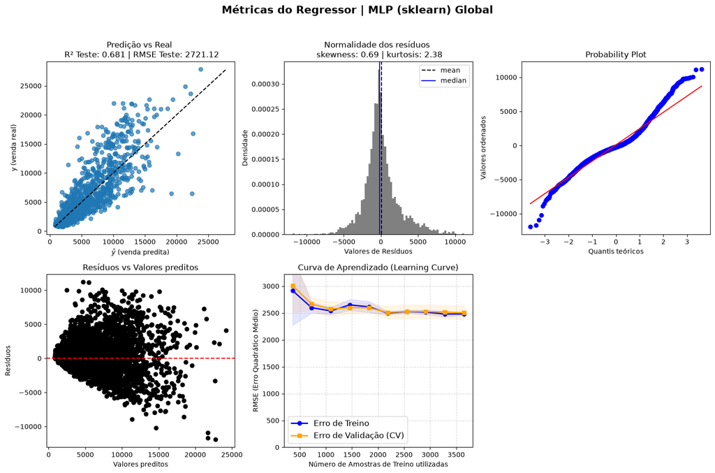

```python
plt.figure(figsize=(15, 10))
plt.suptitle('Métricas do Regressor | MLP (sklearn) Global', fontsize=16, fontweight='bold')

plt.subplot(2, 3, 1)
plt.scatter(y_test_pred, y_test, alpha=0.7)
plt.plot([(min(y_test)), (max(y_test))], [(min(y_test)), (max(y_test))], linestyle='--', color='black')
plt.title(f'Predição vs Real \n R² Teste: {round(r2_score(y_test, y_test_pred),3)} | RMSE Teste: {round(root_mean_squared_error(y_test, y_test_pred),2)}')
plt.ylabel('y (venda real)')
plt.xlabel(r"$\hat{y}$ (venda predita)")

plt.subplot(2, 3, 2)
residuos = y_train - y_train_pred
plt.title(f'Normalidade dos resíduos \n skewness: {round(residuos.skew(),2)} | kurtosis: {round(residuos.kurtosis(),2)}')
plt.hist(residuos, bins='auto', density=True, color='gray')
plt.axvline(residuos.mean(), label='mean', linestyle='--', color='black')
plt.axvline(residuos.median(), label='median', linestyle='-', color='blue')
plt.legend()
plt.ylabel('Densidade')
plt.xlabel('Valores de Resíduos')

plt.subplot(2, 3, 3)
import scipy.stats as stats
stats.probplot(residuos.sort_values(), dist="norm",plot=plt)
plt.xlabel('Quantis teóricos', fontsize = 10)
plt.ylabel('Valores ordenados',fontsize = 10)

plt.subplot(2, 3, 4)
plt.scatter(results.predict(x_train), residuos,color='black')
plt.axhline(y = 0, color = 'red', linestyle = '--')
plt.title('Resíduos vs Valores preditos')
plt.xlabel('Valores preditos',fontsize = 10)
plt.ylabel('Resíduos', fontsize = 10)



plt.subplot(2,3,5)
train_sizes, train_scores, val_scores = learning_curve(
    estimator=results,
    X=x_train,
    y=y_train,
    train_sizes=np.linspace(0.1, 1.0, 10),
    cv=cv,
    scoring='neg_root_mean_squared_error',
    n_jobs=-1)
plt.plot(train_sizes, (-train_scores.mean(axis=1)), 'o-', color="blue", label="Erro de Treino", linewidth=2)
plt.fill_between(train_sizes, (-train_scores.mean(axis=1)) - (-train_scores.std(axis=1)), (-train_scores.mean(axis=1)) + (-train_scores.std(axis=1)), alpha=0.1, color="blue")
plt.plot(train_sizes, (-val_scores.mean(axis=1)), 's-', color="orange", label="Erro de Validação (CV)", linewidth=2)
plt.fill_between(train_sizes, (-val_scores.mean(axis=1)) - (-val_scores.std(axis=1)), (-val_scores.mean(axis=1)) + (-val_scores.std(axis=1)), alpha=0.1, color="orange")
limite_superior = max((-train_scores.mean(axis=1)).max() + (-train_scores.std(axis=1)).max(), (-val_scores.mean(axis=1)).max() + (-val_scores.std(axis=1)).max())
plt.ylim(0, limite_superior * 1.1)
plt.title('Curva de Aprendizado (Learning Curve)')
plt.xlabel('Número de Amostras de Treino utilizadas')
plt.ylabel('RMSE (Erro Quadrático Médio)')
plt.grid(True, linestyle='--', alpha=0.5)
plt.legend(fontsize=12, loc="best")

plt.tight_layout(rect=[0, 0, 1, 0.96])
plt.show()
```

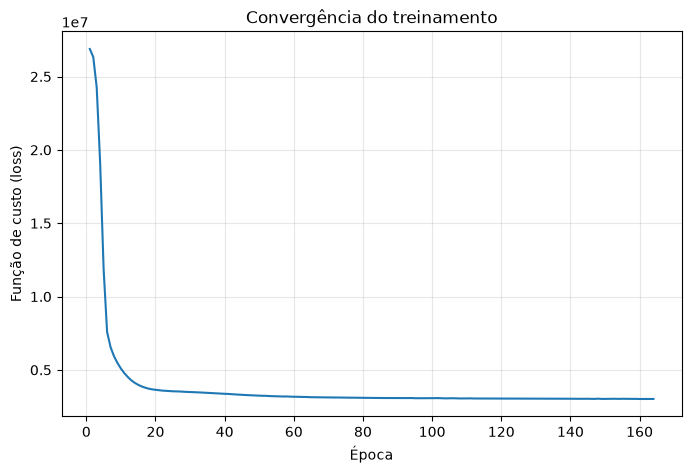

```python
mlp_reg = results.named_steps['mlp']
epocas = range(1,len(mlp_reg.loss_curve_) + 1)
plt.figure(figsize=(8, 5))
plt.plot(epocas, mlp_reg.loss_curve_)
plt.xlabel('Época')
plt.ylabel('Função de custo (loss)')
plt.title('Convergência do treinamento')
plt.grid(alpha=0.3)
plt.show()
```

#### Considerações sobre modelos Globais

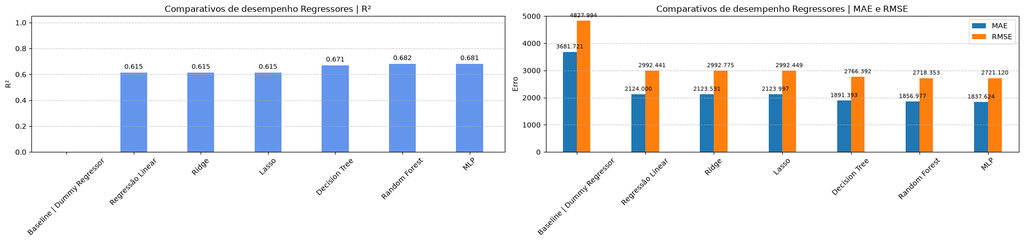

```python
df_comparativo_regressor = pd.DataFrame(comparativo_modelos_regressor).T
plt.figure(figsize=(20, 5))


plt.subplot(1, 2, 1)
barras = plt.bar(df_comparativo_regressor.index, df_comparativo_regressor['R²'], color='cornflowerblue', width=0.4)
plt.title('Comparativos de desempenho Regressores | R²')
plt.ylabel('R²')
plt.xticks(rotation=45)
plt.ylim(0, 1.05)
plt.grid(axis='y', linestyle='--', alpha=0.7)

for barra in barras:
  altura = barra.get_height()
  plt.annotate(
      f'{altura:.3f}',
      xy=(barra.get_x() + barra.get_width() / 2, altura),
      xytext=(0, 3),
      textcoords='offset points',
      ha='center',
      va='bottom',
      fontsize=9)


plt.subplot(1, 2, 2)
df_comparativo_regressor[['MAE', 'RMSE']].plot(kind='bar', width=0.4, rot=0, ax=plt.gca())
plt.title('Comparativos de desempenho Regressores | MAE e RMSE')
plt.ylabel('Erro')
plt.ylim(0, 5000)
plt.xticks(rotation=45)
plt.grid(axis='y', linestyle='--', alpha=0.7)
plt.legend(loc='upper right')

for p in plt.gca().patches:
  plt.gca().annotate(
      f'{p.get_height():.3f}',
      (p.get_x() + p.get_width() / 2., p.get_height()),
      xytext=(0, 3),
      textcoords='offset points',
      ha='center',
      va='bottom',
      fontsize=8)

plt.tight_layout(rect=[0, 0, 1, 0.96])
plt.show()
```

O R² nos dá a impressão de um modelo ruim, somado aos erros de aproximadamente 1.891 e 2.766 (Decision Tree). Porém, possuímos apenas 7 features no momento. Como já discutimos, fatores como estado de conservação, idade do imóvel, ventilação, bairro, direção do sol, vista, entre outros, podem influenciar a precificação fortemente. Inclusive, muitos artigos da área demonstram a importância do bairro: um apartamento de 100 m² em um bairro nobre e outro na periferia não possuem o mesmo valor, porém, para o nosso modelo atual, eles representam a mesma coisa. Nosso precificador atua como um termômetro honesto do mercado. A discrepância (disparo) entre o MAE e o RMSE deve estar relacionada aos outliers (valores atípicos). Para além das features faltantes, esses outliers podem estar ligados à subjetividade humana, como percepções de luxo.

#### Modelos Especialistas por Segmento de Mercado

Hipótese: Os modelos globais podem perder performance, para além do previsto pelas features faltantes, o que já foi debatido em tópicos anteriores, devido:

- A natureza do nosso problema, precificação, é complexa e possui comportamentos distintos de acordo com o segmento de mercado, levando a valorizar características distintas, e com pesos distintos, de acordo com a classificação do imóvel.
- Uma variância gigantesca na variável alvo, escalando o problema.
- As features faltantes fazem com que imóveis completamente diferentes sejam iguais ao modelo.

Suposição: O uso de modelos especializados irá diminuir o erro nos segmentos.

```python
comparativo_final_modelos_regressor = {}
```

##### Decision Tree Global

```python
x_train = x_train_global_2.copy()
x_test = x_test_global_2.copy()
y_train = y_train_global.copy()
y_test = y_test_global.copy()

y_train_pred = y_train_pred_global = best_tree_reg.predict(x_train)
y_test_pred = y_test_pred_global = best_tree_reg.predict(x_test)



comparativo_final_modelos_regressor['Global'] = {'R²': r2_score(y_test, y_test_pred),
                                                      'MAE': mean_absolute_error(y_test, y_test_pred),
                                                      'RMSE': root_mean_squared_error(y_test, y_test_pred),
                                                      'MAPE': mean_absolute_percentage_error(y_test, y_test_pred)}



cluster_test = segmentacao_final.loc[x_test.index, 'cluster']
resultado_global = pd.DataFrame({
    'y_true': y_test,
    'y_pred': y_test_pred_global,
    'cluster': cluster_test})

for segmento, grupo in resultado_global.groupby('cluster'):
    comparativo_final_modelos_regressor[f'Global {segmento}'] = {
        'R²': 0.671,
        'MAE': mean_absolute_error(grupo['y_true'], grupo['y_pred']),
        'RMSE': root_mean_squared_error(grupo['y_true'], grupo['y_pred']),
        'MAPE': mean_absolute_percentage_error(grupo['y_true'], grupo['y_pred'])}
```

##### Decision Tree | Especialização GrandePorte_AltoPosicionamento

```
Fitting 10 folds for each of 432 candidates, totalling 4320 fits
Melhores hiperparâmetros: {'criterion': 'squared_error', 'max_depth': 5, 'max_features': None, 'min_samples_leaf': 30, 'min_samples_split': 6}
Metricas Gerais: Treino e Teste
R-Quadrado (Treino): 0.40588999950330507
R-Quadrado (Teste):  0.3484735357628318
MAE (Treino): 2461.572061918867
MAE (Teste): 2759.450242937882
RMSE (Treino): 3070.088691509413
RMSE (Teste):  3482.3850898930336
```

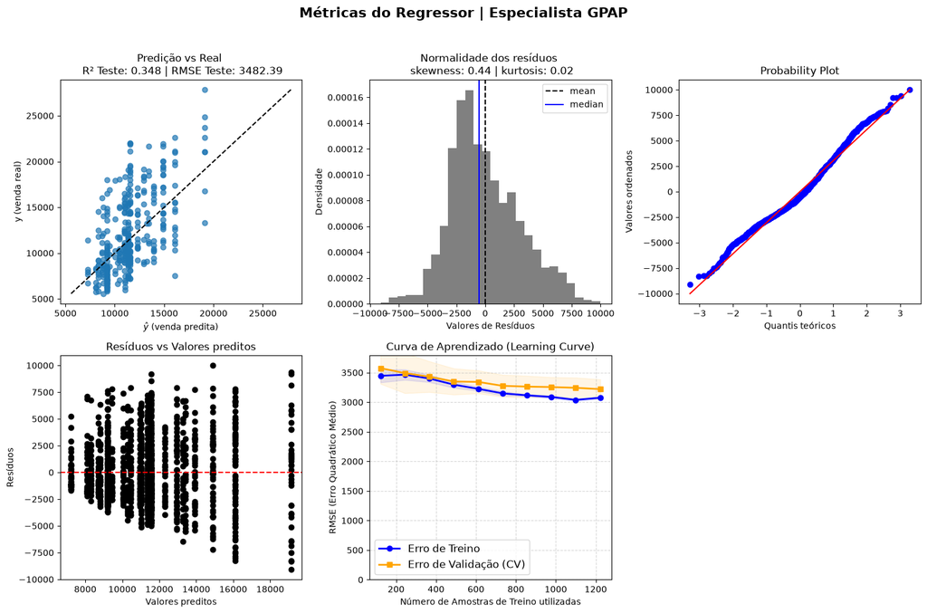

```python
segmento_alvo = 'GrandePorte_AltoPosicionamento'

indices_train = x_train_global[x_train_global['cluster'] == segmento_alvo].index
indices_test = x_test_global[x_test_global['cluster'] == segmento_alvo].index
x_train = x_train_global_2.loc[indices_train].copy()
y_train = y_train_global.loc[indices_train].copy()
x_test = x_test_global_2.loc[indices_test].copy()
y_test = y_test_global.loc[indices_test].copy()

tree = DecisionTreeRegressor(random_state=42)

param_grid = {
    "criterion": ["squared_error", "friedman_mse", "absolute_error"],
    "max_depth": [3, 5, 7],
    "min_samples_split": [6, 10, 30, 60],
    "min_samples_leaf": [3, 5, 15, 30],
    "max_features": [None, "sqrt", "log2"]}

cv = KFold(
    n_splits=10,
    shuffle=True,
    random_state=42)

grid_search = GridSearchCV(
    estimator=tree,
    param_grid=param_grid,
    scoring='neg_mean_squared_error',
    cv=cv,
    n_jobs=-1,
    verbose=1,
    return_train_score=True,
    refit=True)

grid_search.fit(x_train, y_train)

results = None
best_tree_reg_gpap = results = grid_search.best_estimator_
print('Melhores hiperparâmetros:', grid_search.best_params_)

y_train_pred = results.predict(x_train)
y_test_pred = results.predict(x_test)

print("Metricas Gerais: Treino e Teste")
print(f"R-Quadrado (Treino): {r2_score(y_train, y_train_pred)}")
print(f"R-Quadrado (Teste):  {r2_score(y_test, y_test_pred)}")
print(f'MAE (Treino): {mean_absolute_error(y_train, y_train_pred)}')
print(f'MAE (Teste): {mean_absolute_error(y_test, y_test_pred)}')
print(f"RMSE (Treino): {root_mean_squared_error(y_train, y_train_pred)}")
print(f"RMSE (Teste):  {root_mean_squared_error(y_test, y_test_pred)}")

comparativo_final_modelos_regressor['DecisionTree Especialista GPAP'] = {'R²': r2_score(y_test, y_test_pred),
                                                      'MAE': mean_absolute_error(y_test, y_test_pred),
                                                      'RMSE': root_mean_squared_error(y_test, y_test_pred),
                                                      'MAPE': mean_absolute_percentage_error(y_test, y_test_pred)}


plt.figure(figsize=(15, 10))
plt.suptitle('Métricas do Regressor | Especialista GPAP', fontsize=16, fontweight='bold')

plt.subplot(2, 3, 1)
plt.scatter(y_test_pred, y_test, alpha=0.7)
plt.plot([(min(y_test)), (max(y_test))], [(min(y_test)), (max(y_test))], linestyle='--', color='black')
plt.title(f'Predição vs Real \n R² Teste: {round(r2_score(y_test, y_test_pred),3)} | RMSE Teste: {round(root_mean_squared_error(y_test, y_test_pred),2)}')
plt.ylabel('y (venda real)')
plt.xlabel(r"$\hat{y}$ (venda predita)")

plt.subplot(2, 3, 2)
residuos = y_train - y_train_pred
plt.title(f'Normalidade dos resíduos \n skewness: {round(residuos.skew(),2)} | kurtosis: {round(residuos.kurtosis(),2)}')
plt.hist(residuos, bins='auto', density=True, color='gray')
plt.axvline(residuos.mean(), label='mean', linestyle='--', color='black')
plt.axvline(residuos.median(), label='median', linestyle='-', color='blue')
plt.legend()
plt.ylabel('Densidade')
plt.xlabel('Valores de Resíduos')

plt.subplot(2, 3, 3)
import scipy.stats as stats
stats.probplot(residuos.sort_values(), dist="norm",plot=plt)
plt.xlabel('Quantis teóricos', fontsize = 10)
plt.ylabel('Valores ordenados',fontsize = 10)

plt.subplot(2, 3, 4)
plt.scatter(results.predict(x_train), residuos,color='black')
plt.axhline(y = 0, color = 'red', linestyle = '--')
plt.title('Resíduos vs Valores preditos')
plt.xlabel('Valores preditos',fontsize = 10)
plt.ylabel('Resíduos', fontsize = 10)



plt.subplot(2,3,5)
train_sizes, train_scores, val_scores = learning_curve(
    estimator=results,
    X=x_train,
    y=y_train,
    train_sizes=np.linspace(0.1, 1.0, 10),
    cv=cv,
    scoring='neg_root_mean_squared_error',
    n_jobs=-1)
plt.plot(train_sizes, (-train_scores.mean(axis=1)), 'o-', color="blue", label="Erro de Treino", linewidth=2)
plt.fill_between(train_sizes, (-train_scores.mean(axis=1)) - (-train_scores.std(axis=1)), (-train_scores.mean(axis=1)) + (-train_scores.std(axis=1)), alpha=0.1, color="blue")
plt.plot(train_sizes, (-val_scores.mean(axis=1)), 's-', color="orange", label="Erro de Validação (CV)", linewidth=2)
plt.fill_between(train_sizes, (-val_scores.mean(axis=1)) - (-val_scores.std(axis=1)), (-val_scores.mean(axis=1)) + (-val_scores.std(axis=1)), alpha=0.1, color="orange")
limite_superior = max((-train_scores.mean(axis=1)).max() + (-train_scores.std(axis=1)).max(), (-val_scores.mean(axis=1)).max() + (-val_scores.std(axis=1)).max())
plt.ylim(0, limite_superior * 1.1)
plt.title('Curva de Aprendizado (Learning Curve)')
plt.xlabel('Número de Amostras de Treino utilizadas')
plt.ylabel('RMSE (Erro Quadrático Médio)')
plt.grid(True, linestyle='--', alpha=0.5)
plt.legend(fontsize=12, loc="best")

plt.tight_layout(rect=[0, 0, 1, 0.96])
plt.show()
```

##### Decision Tree | Especialização GrandePorte_BaixoPosicionamento

```
Fitting 10 folds for each of 432 candidates, totalling 4320 fits
Melhores hiperparâmetros: {'criterion': 'squared_error', 'max_depth': 7, 'max_features': None, 'min_samples_leaf': 5, 'min_samples_split': 30}
Metricas Gerais: Treino e Teste
R-Quadrado (Treino): 0.5644869296714772
R-Quadrado (Teste):  0.4989039178671971
MAE (Treino): 743.7551565795695
MAE (Teste): 815.8948882616461
RMSE (Treino): 945.1686997284688
RMSE (Teste):  1020.896362816183
```

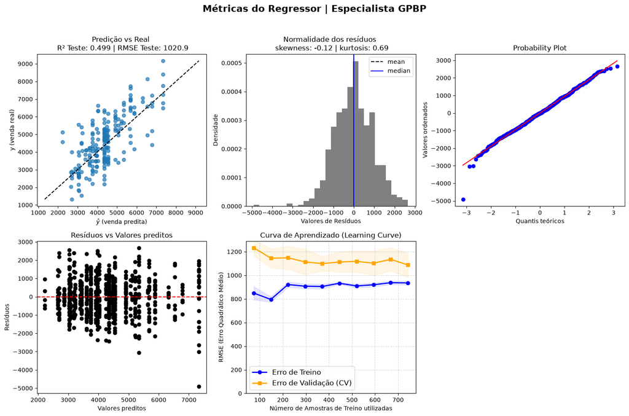

```python
segmento_alvo = 'GrandePorte_BaixoPosicionamento'

indices_train = x_train_global[x_train_global['cluster'] == segmento_alvo].index
indices_test = x_test_global[x_test_global['cluster'] == segmento_alvo].index
x_train = x_train_global_2.loc[indices_train].copy()
y_train = y_train_global.loc[indices_train].copy()
x_test = x_test_global_2.loc[indices_test].copy()
y_test = y_test_global.loc[indices_test].copy()

tree = DecisionTreeRegressor(random_state=42)

param_grid = {
    "criterion": ["squared_error", "friedman_mse", "absolute_error"],
    "max_depth": [3, 5, 7],
    "min_samples_split": [6, 10, 30, 60],
    "min_samples_leaf": [3, 5, 15, 30],
    "max_features": [None, "sqrt", "log2"]}

cv = KFold(
    n_splits=10,
    shuffle=True,
    random_state=42)

grid_search = GridSearchCV(
    estimator=tree,
    param_grid=param_grid,
    scoring='neg_mean_squared_error',
    cv=cv,
    n_jobs=-1,
    verbose=1,
    return_train_score=True,
    refit=True)

grid_search.fit(x_train, y_train)

results = None
best_tree_reg_gpbp = results = grid_search.best_estimator_
print('Melhores hiperparâmetros:', grid_search.best_params_)

y_train_pred = results.predict(x_train)
y_test_pred = results.predict(x_test)

print("Metricas Gerais: Treino e Teste")
print(f"R-Quadrado (Treino): {r2_score(y_train, y_train_pred)}")
print(f"R-Quadrado (Teste):  {r2_score(y_test, y_test_pred)}")
print(f'MAE (Treino): {mean_absolute_error(y_train, y_train_pred)}')
print(f'MAE (Teste): {mean_absolute_error(y_test, y_test_pred)}')
print(f"RMSE (Treino): {root_mean_squared_error(y_train, y_train_pred)}")
print(f"RMSE (Teste):  {root_mean_squared_error(y_test, y_test_pred)}")

comparativo_final_modelos_regressor['DecisionTree Especialista GPBP'] = {'R²': r2_score(y_test, y_test_pred),
                                                      'MAE': mean_absolute_error(y_test, y_test_pred),
                                                      'RMSE': root_mean_squared_error(y_test, y_test_pred),
                                                      'MAPE': mean_absolute_percentage_error(y_test, y_test_pred)}


plt.figure(figsize=(15, 10))
plt.suptitle('Métricas do Regressor | Especialista GPBP', fontsize=16, fontweight='bold')

plt.subplot(2, 3, 1)
plt.scatter(y_test_pred, y_test, alpha=0.7)
plt.plot([(min(y_test)), (max(y_test))], [(min(y_test)), (max(y_test))], linestyle='--', color='black')
plt.title(f'Predição vs Real \n R² Teste: {round(r2_score(y_test, y_test_pred),3)} | RMSE Teste: {round(root_mean_squared_error(y_test, y_test_pred),2)}')
plt.ylabel('y (venda real)')
plt.xlabel(r"$\hat{y}$ (venda predita)")

plt.subplot(2, 3, 2)
residuos = y_train - y_train_pred
plt.title(f'Normalidade dos resíduos \n skewness: {round(residuos.skew(),2)} | kurtosis: {round(residuos.kurtosis(),2)}')
plt.hist(residuos, bins='auto', density=True, color='gray')
plt.axvline(residuos.mean(), label='mean', linestyle='--', color='black')
plt.axvline(residuos.median(), label='median', linestyle='-', color='blue')
plt.legend()
plt.ylabel('Densidade')
plt.xlabel('Valores de Resíduos')

plt.subplot(2, 3, 3)
import scipy.stats as stats
stats.probplot(residuos.sort_values(), dist="norm",plot=plt)
plt.xlabel('Quantis teóricos', fontsize = 10)
plt.ylabel('Valores ordenados',fontsize = 10)

plt.subplot(2, 3, 4)
plt.scatter(results.predict(x_train), residuos,color='black')
plt.axhline(y = 0, color = 'red', linestyle = '--')
plt.title('Resíduos vs Valores preditos')
plt.xlabel('Valores preditos',fontsize = 10)
plt.ylabel('Resíduos', fontsize = 10)



plt.subplot(2,3,5)
train_sizes, train_scores, val_scores = learning_curve(
    estimator=results,
    X=x_train,
    y=y_train,
    train_sizes=np.linspace(0.1, 1.0, 10),
    cv=cv,
    scoring='neg_root_mean_squared_error',
    n_jobs=-1)
plt.plot(train_sizes, (-train_scores.mean(axis=1)), 'o-', color="blue", label="Erro de Treino", linewidth=2)
plt.fill_between(train_sizes, (-train_scores.mean(axis=1)) - (-train_scores.std(axis=1)), (-train_scores.mean(axis=1)) + (-train_scores.std(axis=1)), alpha=0.1, color="blue")
plt.plot(train_sizes, (-val_scores.mean(axis=1)), 's-', color="orange", label="Erro de Validação (CV)", linewidth=2)
plt.fill_between(train_sizes, (-val_scores.mean(axis=1)) - (-val_scores.std(axis=1)), (-val_scores.mean(axis=1)) + (-val_scores.std(axis=1)), alpha=0.1, color="orange")
limite_superior = max((-train_scores.mean(axis=1)).max() + (-train_scores.std(axis=1)).max(), (-val_scores.mean(axis=1)).max() + (-val_scores.std(axis=1)).max())
plt.ylim(0, limite_superior * 1.1)
plt.title('Curva de Aprendizado (Learning Curve)')
plt.xlabel('Número de Amostras de Treino utilizadas')
plt.ylabel('RMSE (Erro Quadrático Médio)')
plt.grid(True, linestyle='--', alpha=0.5)
plt.legend(fontsize=12, loc="best")

plt.tight_layout(rect=[0, 0, 1, 0.96])
plt.show()
```

##### Decision Tree | Especialização PequenoPorte_AltoPosicionamento

```
Fitting 10 folds for each of 432 candidates, totalling 4320 fits
Melhores hiperparâmetros: {'criterion': 'squared_error', 'max_depth': 7, 'max_features': None, 'min_samples_leaf': 15, 'min_samples_split': 6}
Metricas Gerais: Treino e Teste
R-Quadrado (Treino): 0.35875750949239704
R-Quadrado (Teste):  0.29379056658311953
MAE (Treino): 887.6937550030678
MAE (Teste): 1029.2194574706648
RMSE (Treino): 1237.5447645265247
RMSE (Teste):  1488.9538944003302
```

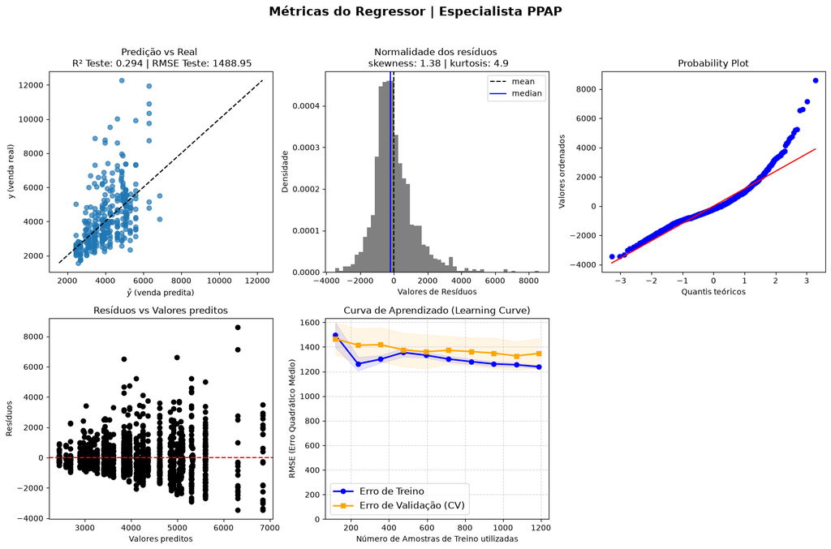

```python
segmento_alvo = 'PequenoPorte_AltoPosicionamento'

indices_train = x_train_global[x_train_global['cluster'] == segmento_alvo].index
indices_test = x_test_global[x_test_global['cluster'] == segmento_alvo].index
x_train = x_train_global_2.loc[indices_train].copy()
y_train = y_train_global.loc[indices_train].copy()
x_test = x_test_global_2.loc[indices_test].copy()
y_test = y_test_global.loc[indices_test].copy()

tree = DecisionTreeRegressor(random_state=42)

param_grid = {
    "criterion": ["squared_error", "friedman_mse", "absolute_error"],
    "max_depth": [3, 5, 7],
    "min_samples_split": [6, 10, 30, 60],
    "min_samples_leaf": [3, 5, 15, 30],
    "max_features": [None, "sqrt", "log2"]}

cv = KFold(
    n_splits=10,
    shuffle=True,
    random_state=42)

grid_search = GridSearchCV(
    estimator=tree,
    param_grid=param_grid,
    scoring='neg_mean_squared_error',
    cv=cv,
    n_jobs=-1,
    verbose=1,
    return_train_score=True,
    refit=True)

grid_search.fit(x_train, y_train)

results = None
best_tree_reg_ppap = results = grid_search.best_estimator_
print('Melhores hiperparâmetros:', grid_search.best_params_)

y_train_pred = results.predict(x_train)
y_test_pred = results.predict(x_test)

print("Metricas Gerais: Treino e Teste")
print(f"R-Quadrado (Treino): {r2_score(y_train, y_train_pred)}")
print(f"R-Quadrado (Teste):  {r2_score(y_test, y_test_pred)}")
print(f'MAE (Treino): {mean_absolute_error(y_train, y_train_pred)}')
print(f'MAE (Teste): {mean_absolute_error(y_test, y_test_pred)}')
print(f"RMSE (Treino): {root_mean_squared_error(y_train, y_train_pred)}")
print(f"RMSE (Teste):  {root_mean_squared_error(y_test, y_test_pred)}")

comparativo_final_modelos_regressor['DecisionTree Especialista PPAP'] = {'R²': r2_score(y_test, y_test_pred),
                                                      'MAE': mean_absolute_error(y_test, y_test_pred),
                                                      'RMSE': root_mean_squared_error(y_test, y_test_pred),
                                                      'MAPE': mean_absolute_percentage_error(y_test, y_test_pred)}


plt.figure(figsize=(15, 10))
plt.suptitle('Métricas do Regressor | Especialista PPAP', fontsize=16, fontweight='bold')

plt.subplot(2, 3, 1)
plt.scatter(y_test_pred, y_test, alpha=0.7)
plt.plot([(min(y_test)), (max(y_test))], [(min(y_test)), (max(y_test))], linestyle='--', color='black')
plt.title(f'Predição vs Real \n R² Teste: {round(r2_score(y_test, y_test_pred),3)} | RMSE Teste: {round(root_mean_squared_error(y_test, y_test_pred),2)}')
plt.ylabel('y (venda real)')
plt.xlabel(r"$\hat{y}$ (venda predita)")

plt.subplot(2, 3, 2)
residuos = y_train - y_train_pred
plt.title(f'Normalidade dos resíduos \n skewness: {round(residuos.skew(),2)} | kurtosis: {round(residuos.kurtosis(),2)}')
plt.hist(residuos, bins='auto', density=True, color='gray')
plt.axvline(residuos.mean(), label='mean', linestyle='--', color='black')
plt.axvline(residuos.median(), label='median', linestyle='-', color='blue')
plt.legend()
plt.ylabel('Densidade')
plt.xlabel('Valores de Resíduos')

plt.subplot(2, 3, 3)
import scipy.stats as stats
stats.probplot(residuos.sort_values(), dist="norm",plot=plt)
plt.xlabel('Quantis teóricos', fontsize = 10)
plt.ylabel('Valores ordenados',fontsize = 10)

plt.subplot(2, 3, 4)
plt.scatter(results.predict(x_train), residuos,color='black')
plt.axhline(y = 0, color = 'red', linestyle = '--')
plt.title('Resíduos vs Valores preditos')
plt.xlabel('Valores preditos',fontsize = 10)
plt.ylabel('Resíduos', fontsize = 10)



plt.subplot(2,3,5)
train_sizes, train_scores, val_scores = learning_curve(
    estimator=results,
    X=x_train,
    y=y_train,
    train_sizes=np.linspace(0.1, 1.0, 10),
    cv=cv,
    scoring='neg_root_mean_squared_error',
    n_jobs=-1)
plt.plot(train_sizes, (-train_scores.mean(axis=1)), 'o-', color="blue", label="Erro de Treino", linewidth=2)
plt.fill_between(train_sizes, (-train_scores.mean(axis=1)) - (-train_scores.std(axis=1)), (-train_scores.mean(axis=1)) + (-train_scores.std(axis=1)), alpha=0.1, color="blue")
plt.plot(train_sizes, (-val_scores.mean(axis=1)), 's-', color="orange", label="Erro de Validação (CV)", linewidth=2)
plt.fill_between(train_sizes, (-val_scores.mean(axis=1)) - (-val_scores.std(axis=1)), (-val_scores.mean(axis=1)) + (-val_scores.std(axis=1)), alpha=0.1, color="orange")
limite_superior = max((-train_scores.mean(axis=1)).max() + (-train_scores.std(axis=1)).max(), (-val_scores.mean(axis=1)).max() + (-val_scores.std(axis=1)).max())
plt.ylim(0, limite_superior * 1.1)
plt.title('Curva de Aprendizado (Learning Curve)')
plt.xlabel('Número de Amostras de Treino utilizadas')
plt.ylabel('RMSE (Erro Quadrático Médio)')
plt.grid(True, linestyle='--', alpha=0.5)
plt.legend(fontsize=12, loc="best")

plt.tight_layout(rect=[0, 0, 1, 0.96])
plt.show()
```

##### Decision Tree | Especialização PequenoPorte_BaixoPosicionamento

```
Fitting 10 folds for each of 432 candidates, totalling 4320 fits
Melhores hiperparâmetros: {'criterion': 'squared_error', 'max_depth': 7, 'max_features': None, 'min_samples_leaf': 3, 'min_samples_split': 60}
Metricas Gerais: Treino e Teste
R-Quadrado (Treino): 0.4964481138285485
R-Quadrado (Teste):  0.4310134297265835
MAE (Treino): 280.80225669462266
MAE (Teste): 285.60413027999385
RMSE (Treino): 347.603942788233
RMSE (Teste):  356.1836918652043
```

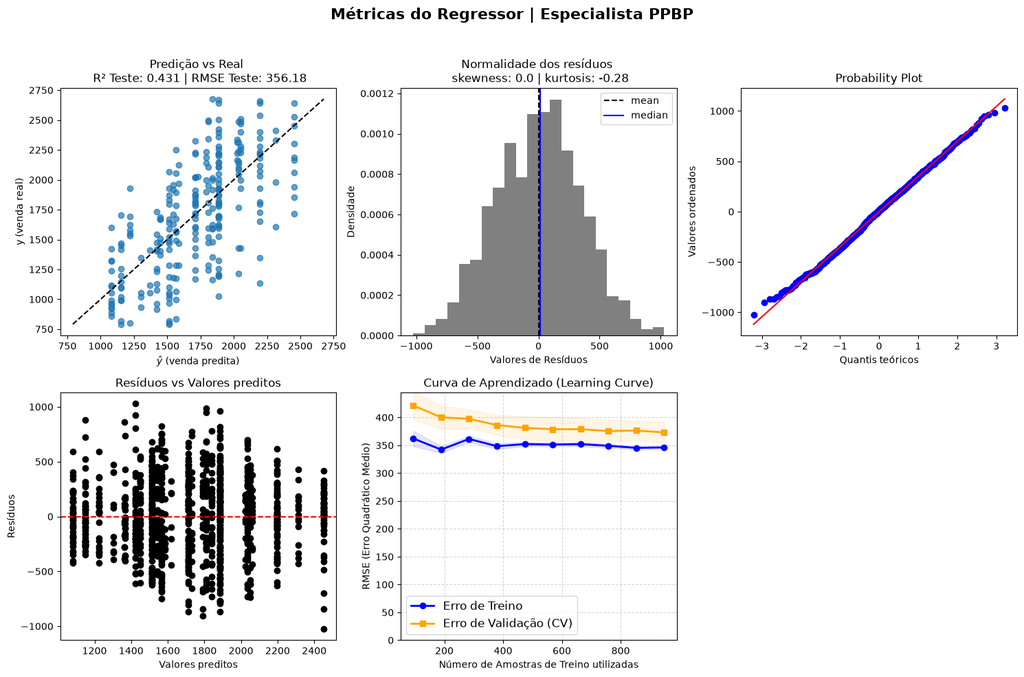

```python
segmento_alvo = 'PequenoPorte_BaixoPosicionamento'

indices_train = x_train_global[x_train_global['cluster'] == segmento_alvo].index
indices_test = x_test_global[x_test_global['cluster'] == segmento_alvo].index
x_train = x_train_global_2.loc[indices_train].copy()
y_train = y_train_global.loc[indices_train].copy()
x_test = x_test_global_2.loc[indices_test].copy()
y_test = y_test_global.loc[indices_test].copy()

tree = DecisionTreeRegressor(random_state=42)

param_grid = {
    "criterion": ["squared_error", "friedman_mse", "absolute_error"],
    "max_depth": [3, 5, 7],
    "min_samples_split": [6, 10, 30, 60],
    "min_samples_leaf": [3, 5, 15, 30],
    "max_features": [None, "sqrt", "log2"]}

cv = KFold(
    n_splits=10,
    shuffle=True,
    random_state=42)

grid_search = GridSearchCV(
    estimator=tree,
    param_grid=param_grid,
    scoring='neg_mean_squared_error',
    cv=cv,
    n_jobs=-1,
    verbose=1,
    return_train_score=True,
    refit=True)

grid_search.fit(x_train, y_train)

results = None
best_tree_reg_ppbp = results = grid_search.best_estimator_
print('Melhores hiperparâmetros:', grid_search.best_params_)

y_train_pred = results.predict(x_train)
y_test_pred = results.predict(x_test)

print("Metricas Gerais: Treino e Teste")
print(f"R-Quadrado (Treino): {r2_score(y_train, y_train_pred)}")
print(f"R-Quadrado (Teste):  {r2_score(y_test, y_test_pred)}")
print(f'MAE (Treino): {mean_absolute_error(y_train, y_train_pred)}')
print(f'MAE (Teste): {mean_absolute_error(y_test, y_test_pred)}')
print(f"RMSE (Treino): {root_mean_squared_error(y_train, y_train_pred)}")
print(f"RMSE (Teste):  {root_mean_squared_error(y_test, y_test_pred)}")

comparativo_final_modelos_regressor['DecisionTree Especialista PPBP'] = {'R²': r2_score(y_test, y_test_pred),
                                                      'MAE': mean_absolute_error(y_test, y_test_pred),
                                                      'RMSE': root_mean_squared_error(y_test, y_test_pred),
                                                      'MAPE': mean_absolute_percentage_error(y_test, y_test_pred)}


plt.figure(figsize=(15, 10))
plt.suptitle('Métricas do Regressor | Especialista PPBP', fontsize=16, fontweight='bold')

plt.subplot(2, 3, 1)
plt.scatter(y_test_pred, y_test, alpha=0.7)
plt.plot([(min(y_test)), (max(y_test))], [(min(y_test)), (max(y_test))], linestyle='--', color='black')
plt.title(f'Predição vs Real \n R² Teste: {round(r2_score(y_test, y_test_pred),3)} | RMSE Teste: {round(root_mean_squared_error(y_test, y_test_pred),2)}')
plt.ylabel('y (venda real)')
plt.xlabel(r"$\hat{y}$ (venda predita)")

plt.subplot(2, 3, 2)
residuos = y_train - y_train_pred
plt.title(f'Normalidade dos resíduos \n skewness: {round(residuos.skew(),2)} | kurtosis: {round(residuos.kurtosis(),2)}')
plt.hist(residuos, bins='auto', density=True, color='gray')
plt.axvline(residuos.mean(), label='mean', linestyle='--', color='black')
plt.axvline(residuos.median(), label='median', linestyle='-', color='blue')
plt.legend()
plt.ylabel('Densidade')
plt.xlabel('Valores de Resíduos')

plt.subplot(2, 3, 3)
import scipy.stats as stats
stats.probplot(residuos.sort_values(), dist="norm",plot=plt)
plt.xlabel('Quantis teóricos', fontsize = 10)
plt.ylabel('Valores ordenados',fontsize = 10)

plt.subplot(2, 3, 4)
plt.scatter(results.predict(x_train), residuos,color='black')
plt.axhline(y = 0, color = 'red', linestyle = '--')
plt.title('Resíduos vs Valores preditos')
plt.xlabel('Valores preditos',fontsize = 10)
plt.ylabel('Resíduos', fontsize = 10)



plt.subplot(2,3,5)
train_sizes, train_scores, val_scores = learning_curve(
    estimator=results,
    X=x_train,
    y=y_train,
    train_sizes=np.linspace(0.1, 1.0, 10),
    cv=cv,
    scoring='neg_root_mean_squared_error',
    n_jobs=-1)
plt.plot(train_sizes, (-train_scores.mean(axis=1)), 'o-', color="blue", label="Erro de Treino", linewidth=2)
plt.fill_between(train_sizes, (-train_scores.mean(axis=1)) - (-train_scores.std(axis=1)), (-train_scores.mean(axis=1)) + (-train_scores.std(axis=1)), alpha=0.1, color="blue")
plt.plot(train_sizes, (-val_scores.mean(axis=1)), 's-', color="orange", label="Erro de Validação (CV)", linewidth=2)
plt.fill_between(train_sizes, (-val_scores.mean(axis=1)) - (-val_scores.std(axis=1)), (-val_scores.mean(axis=1)) + (-val_scores.std(axis=1)), alpha=0.1, color="orange")
limite_superior = max((-train_scores.mean(axis=1)).max() + (-train_scores.std(axis=1)).max(), (-val_scores.mean(axis=1)).max() + (-val_scores.std(axis=1)).max())
plt.ylim(0, limite_superior * 1.1)
plt.title('Curva de Aprendizado (Learning Curve)')
plt.xlabel('Número de Amostras de Treino utilizadas')
plt.ylabel('RMSE (Erro Quadrático Médio)')
plt.grid(True, linestyle='--', alpha=0.5)
plt.legend(fontsize=12, loc="best")

plt.tight_layout(rect=[0, 0, 1, 0.96])
plt.show()
```

#### Comparativo Global (estratificado) x Especializados por Segmentos

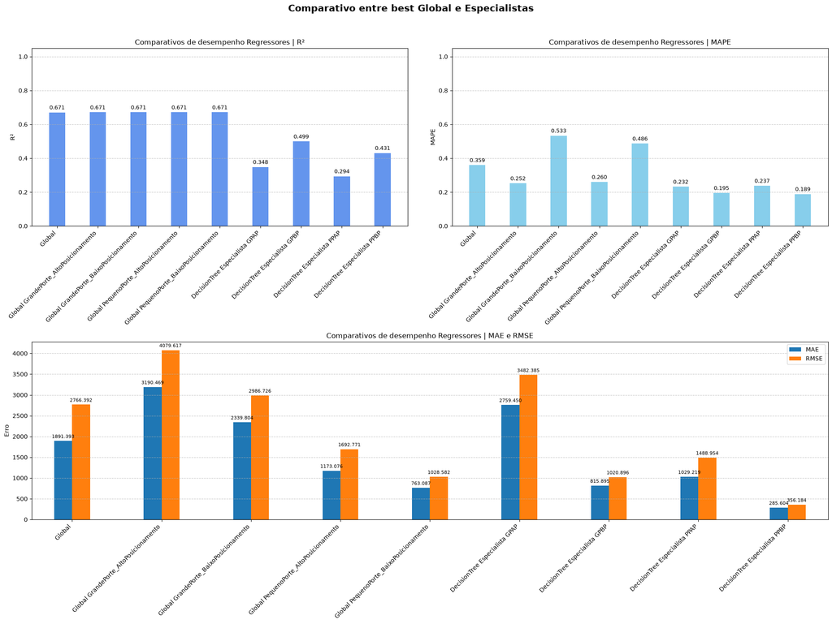

```python
df_comparativo_regressor_final = pd.DataFrame(comparativo_final_modelos_regressor).T
plt.figure(figsize=(20, 15))
plt.suptitle('Comparativo entre best Global e Especialistas', fontsize=16, fontweight='bold')


plt.subplot(2, 2, 1)
barras = plt.bar(df_comparativo_regressor_final.index, df_comparativo_regressor_final['R²'], color='cornflowerblue', width=0.4)
plt.title('Comparativos de desempenho Regressores | R²')
plt.ylabel('R²')
plt.xticks(rotation=45, ha='right')
plt.ylim(0, 1.05)
plt.grid(axis='y', linestyle='--', alpha=0.7)

for barra in barras:
  altura = barra.get_height()
  plt.annotate(
      f'{altura:.3f}',
      xy=(barra.get_x() + barra.get_width() / 2, altura),
      xytext=(0, 3),
      textcoords='offset points',
      ha='center',
      va='bottom',
      fontsize=9)


plt.subplot(2, 2, 2)
barras = plt.bar(df_comparativo_regressor_final.index, df_comparativo_regressor_final['MAPE'], color='skyblue', width=0.4)
plt.title('Comparativos de desempenho Regressores | MAPE')
plt.ylabel('MAPE')
plt.xticks(rotation=45, ha='right')
plt.ylim(0, 1.05)
plt.grid(axis='y', linestyle='--', alpha=0.7)

for barra in barras:
  altura = barra.get_height()
  plt.annotate(
      f'{altura:.3f}',
      xy=(barra.get_x() + barra.get_width() / 2, altura),
      xytext=(0, 3),
      textcoords='offset points',
      ha='center',
      va='bottom',
      fontsize=9)


plt.subplot(2, 1, 2)
df_comparativo_regressor_final[['MAE', 'RMSE']].plot(kind='bar', width=0.4, rot=0, ax=plt.gca())
plt.title('Comparativos de desempenho Regressores | MAE e RMSE')
plt.ylabel('Erro')
plt.xticks(rotation=45, ha='right')
plt.grid(axis='y', linestyle='--', alpha=0.7)
plt.legend(loc='upper right')

for p in plt.gca().patches:
  plt.gca().annotate(
      f'{p.get_height():.3f}',
      (p.get_x() + p.get_width() / 2., p.get_height()),
      xytext=(0, 3),
      textcoords='offset points',
      ha='center',
      va='bottom',
      fontsize=8)

plt.tight_layout(rect=[0, 0, 1, 0.96])
plt.show()
```

Com os modelos especialistas, o primeiro ponto a destacar são os Q-Q Plots, que se mostram bem mais interessantes do que no modelo Global, com exceção do segmento PPAP, que apresenta um alto descolamento nas extremidades da curva.

**PARADOXO DO R-SQUARED**

O R-Squared não mede o tamanho do erro. Ele mede o quanto do erro conseguiu-se reduzir em comparação com a variância total dos dados.A fórmula do R-Squared é:

$$R^2 = 1 - \frac{\text{Variância do Erro (do modelo)}}{\text{Variância Total (dos dados)}}$$

1. No Modelo Global (variância alta): No dataset inteiro temos aluguéis de R$ 660 a R$ 28.000. A variância total (denominador) é muito grande. Como o divisor é consideravel, a divisão dá um número pequeno. E este numero irá ser o valor que subtrairemos de 1. Ao subtrair esse número de 1, o R-Squared fica artificialmente alto, mesmo que o erro financeiro do modelo seja grande na vida real.
2. No Modelo Segmentado (variância reduzida): Na segmentação de “Pequeno Porte / Baixo Posicionamento” (PPBP), por exemplo, os aluguéis ficaram ali entre R$ 660 e R$ 2.871. Todos os imóveis são muito parecidos, ou no caso de outros segmentos, ao menos aproximou-se muito. A variância total despencou. Como o divisor agora é muito pequeno, matematicamente é mais difícil o modelo explicar a variância dos erros. Qualquer erro de R$ 300 que o modelo cometa pesa muito na balança da variância, e a fórmula joga o R-Squared lá para baixo (ex: 0.30).

Quando comparamos as estratificações do modelo Global com seus respectivos modelos especialistas, notamos algo relevante: ocorre uma queda brusca do MAE e do RMSE (e consequentemente do MAPE), provando que o erro absoluto real diminuiu consideravelmente, principalmente nos segmentos GPBP e PPBP, onde as features faltantes e a subjetividade influenciam menos. Em GPAP e PPAP tivemos melhorias mais singelas de MAPE, a feature de bairro por exemplo teria muito a contribuir, mas ainda assim temos quedas interessantes no erro. Com isso, podemos concluir que a estratégia de modelagem funcionou, assumimos o trade-off de “abrir mão” de um R-Squared “ilusório” em troca de um erro financeiro real muito menor para a operação da imobiliária.

#### Stacking

Iremos realizar um experimento de Global-Local Ensemble. Nós vamos usar o ‘cross_val_predict’, visto que os modelos gerados ate agora aprenderam com os dados de treino e isto seria uma data leak sério. O ‘cross_val_predict’ irá chamar os modelos e irá clonar apenas os estimadores, sem ter acesso aos aprendizados (por exemplo, no caso de arvors: os nós). Com os hiperparametros ele irá cria um numero ‘n’ de modelos, igual ao numero ‘k’ de folds. Cada modelo sera treinado com k-1 folds e irá prever o fold restante de treino, que irá para o meta-modelo. Esse processo (OOF) se repete, sempre sendo o k fold de inferência diferente, assim como o conjunto que o treina. Esse processo é repetido em cada modelo (global e os 4 especialistas), a diferença se dá que especialistas classificam somente o que lhes compete. Ao final teremos a previsão de todos os modelos. Antes de fornecermos os dados para o meta-modelo, criamos as features dummies.

```python
def pipeline_stacking(x_train_global, x_test_global, x_train, y_train, x_test, y_test, modelo_global, modelos_especialistas):
    """
    Planejamento sequêncial do Stacking com Meta-Modelo Ridge para evitar vazamento
    obs modelos_especialistas: Dicionário mapeando o nome do cluster seguido do modelo treinado {'GrandePorte_AltoPosicionamento': best_tree_reg_gpap, ...}
    """
    x_train_meta = pd.DataFrame(index=x_train.index)
    x_test_meta = pd.DataFrame(index=x_test.index)

    # Global OOF
    cv_global = KFold(n_splits=5, shuffle=True, random_state=42)
    x_train_meta['pred_global'] = cross_val_predict(modelo_global, x_train, y_train, cv=cv_global, n_jobs=-1)
    x_test_meta['pred_global'] = modelo_global.predict(x_test)

    # ESpecialistas OOF
    for seg_nome, modelo in modelos_especialistas.items():
        mascara_train = x_train_global['cluster'] == seg_nome
        x_train_esp = x_train[mascara_train]
        y_train_esp = y_train[mascara_train]
        mascara_test = x_test_global['cluster'] == seg_nome
        x_test_esp = x_test[mascara_test]

        col_name = (f"pred_{seg_nome}")
        x_train_meta[col_name] = 0.0
        x_test_meta[col_name] = 0.0
        cv_esp = KFold(n_splits=10, shuffle=True, random_state=42)
        x_train_meta.loc[mascara_train, col_name] = cross_val_predict(modelo, x_train_esp, y_train_esp, cv=cv_esp, n_jobs=-1)
        x_test_meta.loc[mascara_test, col_name] =  modelo.predict(x_test_esp)

    # Dummies
    dummies_train = pd.get_dummies(x_train_global['cluster'], prefix='is', dtype=int)
    x_train_meta = pd.concat([x_train_meta, dummies_train], axis=1)
    dummies_test = pd.get_dummies(x_test_global['cluster'], prefix='is', dtype=int)
    x_test_meta = pd.concat([x_test_meta, dummies_test], axis=1)

    # Meta (ridge)
    x_test_meta = x_test_meta.reindex(columns=x_train_meta.columns, fill_value=0)
    meta_model = Ridge(alpha=1.0)
    meta_model.fit(x_train_meta, y_train)

    return meta_model, x_train_meta, x_test_meta
```

```python
x_train = x_train_global_2.copy()
x_test = x_test_global_2.copy()
y_train = y_train_global.copy()
y_test = y_test_global.copy()

dicionario_especs = {
    'GrandePorte_AltoPosicionamento': best_tree_reg_gpap,
    'GrandePorte_BaixoPosicionamento': best_tree_reg_gpbp,
    'PequenoPorte_AltoPosicionamento': best_tree_reg_ppap,
    'PequenoPorte_BaixoPosicionamento': best_tree_reg_ppbp}


meta_modelo_final, x_train_meta, x_test_meta = pipeline_stacking(
                                            x_train_global=x_train_global, x_test_global=x_test_global,
                                            x_train=x_train, y_train=y_train,   x_test=x_test,   y_test=y_test,
                                            modelo_global=best_tree_reg, modelos_especialistas=dicionario_especs)

print(f"Intercepto: {meta_modelo_final.intercept_:.2f}")
df_pesos = pd.DataFrame({'Feature': x_train_meta.columns, 'Peso_Atribuido': meta_modelo_final.coef_}).sort_values(by='Peso_Atribuido', ascending=False)
print(df_pesos.to_string(index=False))
```

```
Intercepto: 903.02
                              Feature  Peso_Atribuido
    is_GrandePorte_AltoPosicionamento      679.827471
   is_GrandePorte_BaixoPosicionamento       25.833689
  pred_GrandePorte_AltoPosicionamento        0.692402
 pred_PequenoPorte_AltoPosicionamento        0.615387
pred_PequenoPorte_BaixoPosicionamento        0.577349
 pred_GrandePorte_BaixoPosicionamento        0.484621
                          pred_global        0.197534
   is_PequenoPorte_AltoPosicionamento      -54.902088
  is_PequenoPorte_BaixoPosicionamento     -650.759073
```

```python
y_train_pred_meta = meta_modelo_final.predict(x_train_meta)
y_test_pred_meta = meta_modelo_final.predict(x_test_meta)

print("Metricas Gerais: Treino e Teste")
print(f"R-Quadrado (Treino): {r2_score(y_train, y_train_pred_meta)}")
print(f"R-Quadrado (Teste):  {r2_score(y_test, y_test_pred_meta)}")
print(f'MAE (Treino): {mean_absolute_error(y_train, y_train_pred_meta)}')
print(f'MAE (Teste): {mean_absolute_error(y_test, y_test_pred_meta)}')
print(f"RMSE (Treino): {root_mean_squared_error(y_train, y_train_pred_meta)}")
print(f"RMSE (Teste):  {root_mean_squared_error(y_test, y_test_pred_meta)}")


comparativo_modelos_regressor['Stacking Global'] = {
    'R²': r2_score(y_test, y_test_pred_meta),
    'MAE': mean_absolute_error(y_test, y_test_pred_meta),
    'RMSE': root_mean_squared_error(y_test, y_test_pred_meta),
    'MAPE': mean_absolute_percentage_error(y_test, y_test_pred_meta)}



comparativo_final_modelos_regressor['Stacking Global'] = {
    'R²': r2_score(y_test, y_test_pred_meta),
    'MAE': mean_absolute_error(y_test, y_test_pred_meta),
    'RMSE': root_mean_squared_error(y_test, y_test_pred_meta),
    'MAPE': mean_absolute_percentage_error(y_test, y_test_pred_meta)}


resultado_stacking = pd.DataFrame({
    'y_true': y_test,
    'y_pred': y_test_pred_meta,
    'cluster': x_test_global['cluster']})
ordem_desejada = [
    'GrandePorte_AltoPosicionamento',
    'GrandePorte_BaixoPosicionamento',
    'PequenoPorte_AltoPosicionamento',
    'PequenoPorte_BaixoPosicionamento']
for segmento in ordem_desejada:
    grupo = resultado_stacking[resultado_stacking['cluster'] == segmento]
    comparativo_final_modelos_regressor[f'Stacking {segmento}'] = {
        'R²': r2_score(y_test, y_test_pred_meta),
        'MAE': mean_absolute_error(grupo['y_true'], grupo['y_pred']),
        'RMSE': root_mean_squared_error(grupo['y_true'], grupo['y_pred']),
        'MAPE': mean_absolute_percentage_error(grupo['y_true'], grupo['y_pred'])}
```

```
Metricas Gerais: Treino e Teste
R-Quadrado (Treino): 0.8138195009368172
R-Quadrado (Teste):  0.8109305727300455
MAE (Treino): 1267.853274271838
MAE (Teste): 1331.9840493402871
RMSE (Treino): 1944.3652572417157
RMSE (Teste):  2095.988918717339
```

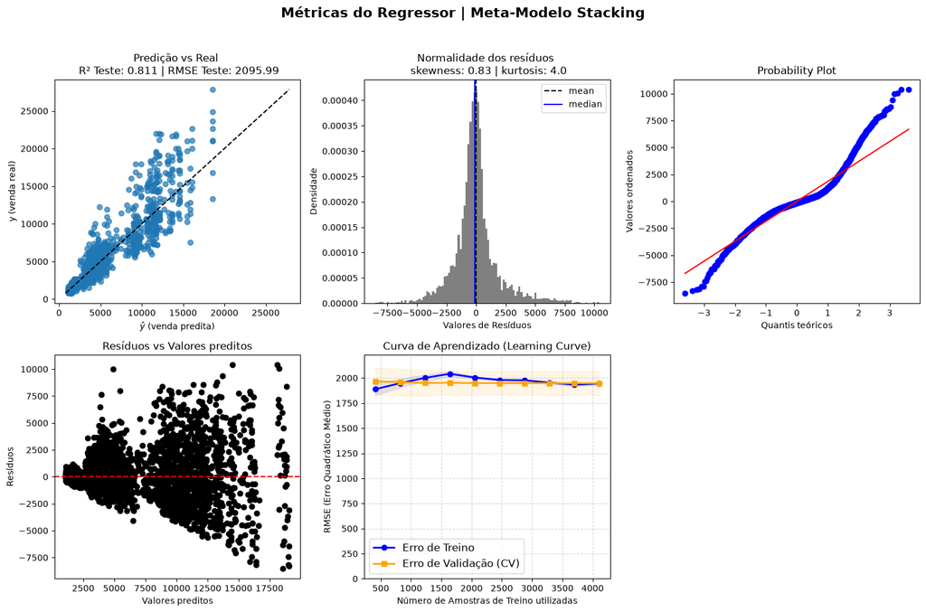

```python
plt.figure(figsize=(15, 10))
plt.suptitle('Métricas do Regressor | Meta-Modelo Stacking', fontsize=16, fontweight='bold')

plt.subplot(2, 3, 1)
plt.scatter(y_test_pred_meta, y_test, alpha=0.7)
plt.plot([(min(y_test)), (max(y_test))], [(min(y_test)), (max(y_test))], linestyle='--', color='black')
plt.title(f'Predição vs Real \n R² Teste: {round(r2_score(y_test, y_test_pred_meta),3)} | RMSE Teste: {round(root_mean_squared_error(y_test, y_test_pred_meta),2)}')
plt.ylabel('y (venda real)')
plt.xlabel(r"$\hat{y}$ (venda predita)")

plt.subplot(2, 3, 2)
residuos = y_train - y_train_pred_meta
plt.title(f'Normalidade dos resíduos \n skewness: {round(residuos.skew(),2)} | kurtosis: {round(residuos.kurtosis(),2)}')
plt.hist(residuos, bins='auto', density=True, color='gray')
plt.axvline(residuos.mean(), label='mean', linestyle='--', color='black')
plt.axvline(residuos.median(), label='median', linestyle='-', color='blue')
plt.legend()
plt.ylabel('Densidade')
plt.xlabel('Valores de Resíduos')

plt.subplot(2, 3, 3)
import scipy.stats as stats
stats.probplot(residuos.sort_values(), dist="norm",plot=plt)
plt.xlabel('Quantis teóricos', fontsize = 10)
plt.ylabel('Valores ordenados',fontsize = 10)

plt.subplot(2, 3, 4)
plt.scatter(meta_modelo_final.predict(x_train_meta), residuos,color='black')
plt.axhline(y = 0, color = 'red', linestyle = '--')
plt.title('Resíduos vs Valores preditos')
plt.xlabel('Valores preditos',fontsize = 10)
plt.ylabel('Resíduos', fontsize = 10)

plt.subplot(2,3,5)
train_sizes, train_scores, val_scores = learning_curve(
    estimator=meta_modelo_final,
    X=x_train_meta,
    y=y_train,
    train_sizes=np.linspace(0.1, 1.0, 10),
    cv=cv,
    scoring='neg_root_mean_squared_error',
    n_jobs=-1)
plt.plot(train_sizes, (-train_scores.mean(axis=1)), 'o-', color="blue", label="Erro de Treino", linewidth=2)
plt.fill_between(train_sizes, (-train_scores.mean(axis=1)) - (-train_scores.std(axis=1)), (-train_scores.mean(axis=1)) + (-train_scores.std(axis=1)), alpha=0.1, color="blue")
plt.plot(train_sizes, (-val_scores.mean(axis=1)), 's-', color="orange", label="Erro de Validação (CV)", linewidth=2)
plt.fill_between(train_sizes, (-val_scores.mean(axis=1)) - (-val_scores.std(axis=1)), (-val_scores.mean(axis=1)) + (-val_scores.std(axis=1)), alpha=0.1, color="orange")
limite_superior = max((-train_scores.mean(axis=1)).max() + (-train_scores.std(axis=1)).max(), (-val_scores.mean(axis=1)).max() + (-val_scores.std(axis=1)).max())
plt.ylim(0, limite_superior * 1.1)
plt.title('Curva de Aprendizado (Learning Curve)')
plt.xlabel('Número de Amostras de Treino utilizadas')
plt.ylabel('RMSE (Erro Quadrático Médio)')
plt.grid(True, linestyle='--', alpha=0.5)
plt.legend(fontsize=12, loc="best")

plt.tight_layout(rect=[0, 0, 1, 0.96])
plt.show()
```

##### Aprofundamento | Análise dos Resíduos

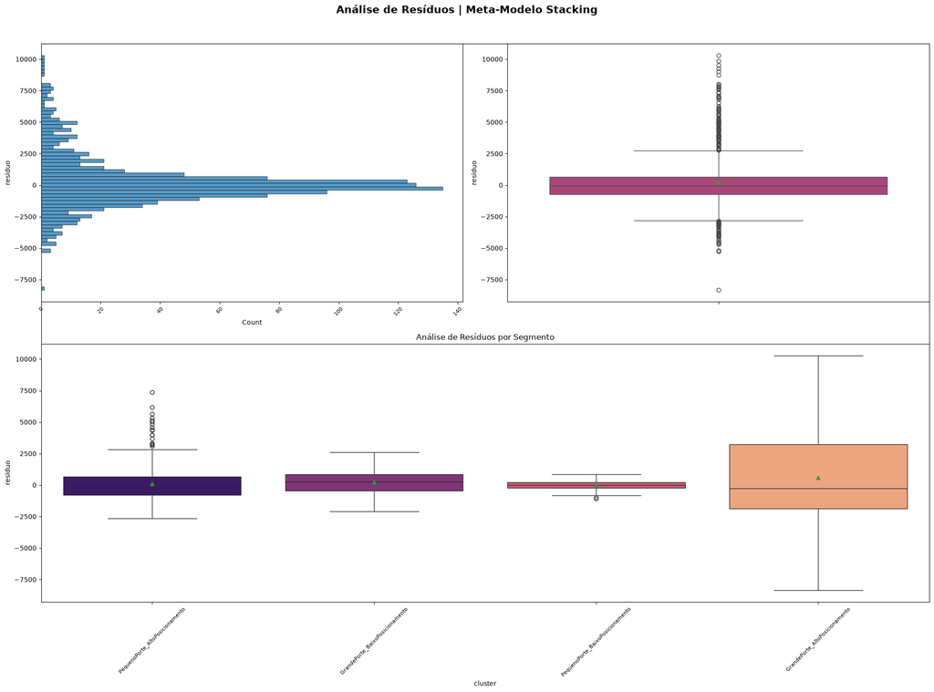

```python
auditoria_stacking = x_test_global.copy()
auditoria_stacking['y_true'] = y_test
auditoria_stacking['y_pred'] = y_test_pred_meta


auditoria_stacking['residuo'] = auditoria_stacking['y_true'] - auditoria_stacking['y_pred']
auditoria_stacking['MAPE'] = (np.abs(auditoria_stacking['residuo']) / auditoria_stacking['y_true']) * 100

plt.figure(figsize=(20,15))
plt.suptitle('Análise de Resíduos | Meta-Modelo Stacking', fontsize=16, fontweight='bold')
plt.xticks([])
plt.yticks([])

plt.subplot(2,2,1)
sns.histplot(data=auditoria_stacking, y='residuo',palette='magma', )
plt.xticks(rotation=45, fontsize=8)


plt.subplot(2,2,2)
sns.boxplot(data=auditoria_stacking, y='residuo',palette='magma', showmeans=True,)
plt.xticks(rotation=45, fontsize=8)

plt.subplot(2, 1, 2)
plt.title('Análise de Resíduos por Segmento')
sns.boxplot(data=auditoria_stacking, y='residuo',palette='magma', x='cluster', showmeans=True,)
plt.xticks(rotation=45, fontsize=8)

plt.tight_layout(rect=[0, 0, 1, 0.96])
plt.show()
```

```python
print(f'OVERPREDICTION | Total : {len(auditoria_stacking[auditoria_stacking['residuo']< 0])} | Soma : {auditoria_stacking[auditoria_stacking['residuo'] < 0]['residuo'].sum():.2f} | Média : {auditoria_stacking[auditoria_stacking['residuo'] < 0]['residuo'].mean():.2f} | Mediana : {auditoria_stacking[auditoria_stacking['residuo'] < 0]['residuo'].median():.2f}')
print(f'UNDERPREDICTION | Total : {len(auditoria_stacking[auditoria_stacking['residuo'] > 0])} | Soma : {auditoria_stacking[auditoria_stacking['residuo'] > 0]['residuo'].sum():.2f} | Média : {auditoria_stacking[auditoria_stacking['residuo'] > 0]['residuo'].mean():.2f} | Mediana : {auditoria_stacking[auditoria_stacking['residuo'] > 0]['residuo'].median():.2f}')
```

```
OVERPREDICTION | Total : 595 | Soma : -624594.47 | Média : -1049.74 | Mediana : -690.26
UNDERPREDICTION | Total : 546 | Soma : 895199.33 | Média : 1639.56 | Mediana : 704.52
```

```python
auditoria_stacking['tipo_erro'] = np.where(auditoria_stacking['residuo'] > 0, 'Under', 'Over')

mape_stats = auditoria_stacking.groupby('cluster')['MAPE'].agg(mape_=('mean')).round(2)

over_stats = auditoria_stacking[auditoria_stacking['tipo_erro'] == 'Over'].groupby('cluster')['residuo'].agg(
    count_over=('count'),
    sum_over=('sum'),
    mean_over=('mean'),
    median_over=('median')
).round(2)

under_stats = auditoria_stacking[auditoria_stacking['tipo_erro'] == 'Under'].groupby('cluster')['residuo'].agg(
    count_under=('count'),
    sum_under=('sum'),
    mean_under=('mean'),
    median_under=('median')
).round(2)

contagem_tipo = pd.crosstab(auditoria_stacking['cluster'], auditoria_stacking['tipo_erro'], normalize='index') * 100
contagem_tipo = contagem_tipo.round(1)

tabela_audit_final = pd.DataFrame(index=contagem_tipo.index)
tabela_audit_final['MAPE (%)'] = mape_stats['mape_'].astype(str) + '%'
tabela_audit_final['% Imóveis Over'] = contagem_tipo['Over'].astype(str) + '%'
tabela_audit_final['% Imóveis Under'] = contagem_tipo['Under'].astype(str) + '%'

tabela_audit_final['Qtd Over'] = over_stats['count_over']
tabela_audit_final['Soma Residual Over'] = over_stats['sum_over']
tabela_audit_final['Média Over'] = over_stats['mean_over']

tabela_audit_final['Qtd Under'] = under_stats['count_under']
tabela_audit_final['Soma Residual Under'] = under_stats['sum_under']
tabela_audit_final['Média Under'] = under_stats['mean_under']
tabela_audit_final['diff_residuos'] = tabela_audit_final['Soma Residual Over'] + tabela_audit_final['Soma Residual Under']

display(tabela_audit_final)
```

| cluster | MAPE (%) | % Imóveis Over | % Imóveis Under | Qtd Over | Soma Residual Over | Média Over | Qtd Under | Soma Residual Under | Média Under | diff_residuos |
| --- | --- | --- | --- | --- | --- | --- | --- | --- | --- | --- |
| GrandePorte_AltoPosicionamento | 23.06% | 52.4% | 47.6% | 178 | -368986.57 | -2072.96 | 162 | 563264.42 | 3476.94 | 194277.85 |
| GrandePorte_BaixoPosicionamento | 19.2% | 41.5% | 58.5% | 86 | -61870.67 | -719.43 | 121 | 103984.54 | 859.38 | 42113.87 |
| PequenoPorte_AltoPosicionamento | 24.45% | 60.7% | 39.3% | 201 | -153348.61 | -762.93 | 130 | 191285.30 | 1471.43 | 37936.69 |
| PequenoPorte_BaixoPosicionamento | 19.31% | 49.4% | 50.6% | 130 | -40388.62 | -310.68 | 133 | 36665.07 | 275.68 | -3723.55 |

Entre os modelos, temos MAPE próximos. GPAP possui a maior underprediction, e apesar de um valor de resíduos alto em over, a diff mostra um impacto muito mais relevante para under. GPBP domina imóveis com under, enquanto em PPAP domina over (ambos próximos com domínio 60%). Apesar do domínio em PPAP, o peso maior de resíduos é under (quase 38K de diferença). PPBP é um segmento bem equilibrado entre under e over, tanto em quantidade de imóveis como soma de resíduos.

Vamos fazer o mesmo para Área, aqui vale destacar a técnica de particionamento em bins: vamos usar “Equal-Frequency” onde cada bin contenha exatamente o mesmo número de elementos (para isso ele ordena os dados e calcula quantis)

```python
auditoria_stacking['faixa_area'] = pd.qcut(auditoria_stacking['area'], q=10, duplicates='drop')
auditoria_stacking['tipo_erro'] = np.where(auditoria_stacking['residuo'] > 0, 'Under', 'Over')
mape_stats = auditoria_stacking.groupby('faixa_area')['MAPE'].agg(mape_=('mean')).round(2)


over_stats = auditoria_stacking[auditoria_stacking['tipo_erro'] == 'Over'].groupby('faixa_area')['residuo'].agg(
    count_over=('count'),
    sum_over=('sum'),
    mean_over=('mean'),
    median_over=('median')
).round(2)

under_stats = auditoria_stacking[auditoria_stacking['tipo_erro'] == 'Under'].groupby('faixa_area')['residuo'].agg(
    count_under=('count'),
    sum_under=('sum'),
    mean_under=('mean'),
    median_under=('median')
).round(2)


contagem_tipo = pd.crosstab(auditoria_stacking['faixa_area'], auditoria_stacking['tipo_erro'], normalize='index') * 100
contagem_tipo = contagem_tipo.round(1)

tabela_audit_area = pd.DataFrame(index=contagem_tipo.index)
tabela_audit_area['MAPE (%)'] = mape_stats['mape_'].astype(str) + '%'
tabela_audit_area['% Imóveis Over'] = contagem_tipo['Over'].astype(str) + '%'
tabela_audit_area['% Imóveis Under'] = contagem_tipo['Under'].astype(str) + '%'

tabela_audit_area['Qtd Over'] = over_stats['count_over']
tabela_audit_area['Soma Residual Over'] = over_stats['sum_over']
tabela_audit_area['Média Over'] = over_stats['mean_over']

tabela_audit_area['Qtd Under'] = under_stats['count_under']
tabela_audit_area['Soma Residual Under'] = under_stats['sum_under']
tabela_audit_area['Média Under'] = under_stats['mean_under']
tabela_audit_area['diff_residuos'] = tabela_audit_area['Soma Residual Over'] + tabela_audit_area['Soma Residual Under']

display(tabela_audit_area)
```

| faixa_area | MAPE (%) | % Imóveis Over | % Imóveis Under | Qtd Over | Soma Residual Over | Média Over | Qtd Under | Soma Residual Under | Média Under | diff_residuos |
| --- | --- | --- | --- | --- | --- | --- | --- | --- | --- | --- |
| (14.999, 40.0] | 24.0% | 65.8% | 34.2% | 77 | -39687.20 | -515.42 | 40 | 21356.20 | 533.91 | -18331.00 |
| (40.0, 54.0] | 22.68% | 58.0% | 42.0% | 69 | -39722.95 | -575.69 | 50 | 29327.97 | 586.56 | -10394.98 |
| (54.0, 65.0] | 22.94% | 44.5% | 55.5% | 49 | -31120.89 | -635.12 | 61 | 55282.92 | 906.28 | 24162.03 |
| (65.0, 80.0] | 19.7% | 55.6% | 44.4% | 65 | -33571.75 | -516.49 | 52 | 42986.10 | 826.66 | 9414.35 |
| (80.0, 100.0] | 22.72% | 58.0% | 42.0% | 65 | -46122.30 | -709.57 | 47 | 78495.35 | 1670.11 | 32373.05 |
| (100.0, 134.0] | 19.62% | 52.7% | 47.3% | 58 | -67298.77 | -1160.32 | 52 | 55039.53 | 1058.45 | -12259.24 |
| (134.0, 172.0] | 25.16% | 57.0% | 43.0% | 65 | -103666.82 | -1594.87 | 49 | 86791.27 | 1771.25 | -16875.55 |
| (172.0, 224.0] | 19.65% | 44.7% | 55.3% | 51 | -75444.11 | -1479.30 | 63 | 135123.73 | 2144.82 | 59679.62 |
| (224.0, 300.0] | 21.74% | 42.1% | 57.9% | 48 | -82992.14 | -1729.00 | 66 | 205106.89 | 3107.68 | 122114.75 |
| (300.0, 620.0] | 20.74% | 42.1% | 57.9% | 48 | -104967.54 | -2186.82 | 66 | 185689.37 | 2813.48 | 80721.83 |

As duas menores partições de áreas existe predominância de quantidade de imóveis com overprediction e o impacto é mantido ao visualizarmos a diferença de resíduos, enquanto as duas maiores sofrem mais com under, tambem tanto em quantidade quanto em resíduos.

```python
auditoria_stacking['faixa_y_true'] = pd.qcut(auditoria_stacking['y_true'], q=10, duplicates='drop')
auditoria_stacking['tipo_erro'] = np.where(auditoria_stacking['residuo'] > 0, 'Under', 'Over')
mape_stats = auditoria_stacking.groupby('faixa_y_true')['MAPE'].agg(mape_=('mean')).round(2)

over_stats = auditoria_stacking[auditoria_stacking['tipo_erro'] == 'Over'].groupby('faixa_y_true')['residuo'].agg(
    count_over=('count'),
    sum_over=('sum'),
    mean_over=('mean'),
    median_over=('median')
).round(2)

under_stats = auditoria_stacking[auditoria_stacking['tipo_erro'] == 'Under'].groupby('faixa_y_true')['residuo'].agg(
    count_under=('count'),
    sum_under=('sum'),
    mean_under=('mean'),
    median_under=('median')
).round(2)


contagem_tipo = pd.crosstab(auditoria_stacking['faixa_y_true'], auditoria_stacking['tipo_erro'], normalize='index') * 100
contagem_tipo = contagem_tipo.round(1)

tabela_audit_total = pd.DataFrame(index=contagem_tipo.index)
tabela_audit_total['% Imóveis Over'] = contagem_tipo['Over'].astype(str) + '%'
tabela_audit_total['% Imóveis Under'] = contagem_tipo['Under'].astype(str) + '%'

tabela_audit_total['Qtd Over'] = over_stats['count_over']
tabela_audit_total['MAPE (%)'] = mape_stats['mape_'].astype(str) + '%'
tabela_audit_total['Soma Residual Over'] = over_stats['sum_over']
tabela_audit_total['Média Over'] = over_stats['mean_over']

tabela_audit_total['Qtd Under'] = under_stats['count_under']
tabela_audit_total['Soma Residual Under'] = under_stats['sum_under']
tabela_audit_total['Média Under'] = under_stats['mean_under']
tabela_audit_total['diff_residuos'] = tabela_audit_total['Soma Residual Over'] + tabela_audit_total['Soma Residual Under']

display(tabela_audit_total)
```

| faixa_y_true | % Imóveis Over | % Imóveis Under | Qtd Over | MAPE (%) | Soma Residual Over | Média Over | Qtd Under | Soma Residual Under | Média Under | diff_residuos |
| --- | --- | --- | --- | --- | --- | --- | --- | --- | --- | --- |
| (790.999, 1611.0] | 84.3% | 15.7% | 97 | 29.73% | -36915.48 | -380.57 | 18 | 3378.42 | 187.69 | -33537.06 |
| (1611.0, 2165.0] | 40.4% | 59.6% | 46 | 17.19% | -21813.32 | -474.20 | 68 | 15713.18 | 231.08 | -6100.14 |
| (2165.0, 2762.0] | 58.8% | 41.2% | 67 | 25.68% | -53781.68 | -802.71 | 47 | 17573.47 | 373.90 | -36208.21 |
| (2762.0, 3518.0] | 91.2% | 8.8% | 104 | 23.36% | -81024.13 | -779.08 | 10 | 1929.60 | 192.96 | -79094.53 |
| (3518.0, 4404.0] | 64.0% | 36.0% | 73 | 15.3% | -48412.34 | -663.18 | 41 | 19873.58 | 484.72 | -28538.76 |
| (4404.0, 5497.0] | 21.1% | 78.9% | 24 | 13.04% | -10150.33 | -422.93 | 90 | 63196.90 | 702.19 | 53046.57 |
| (5497.0, 7040.0] | 32.5% | 67.5% | 37 | 27.6% | -91023.74 | -2460.10 | 77 | 106219.70 | 1379.48 | 15195.96 |
| (7040.0, 9561.0] | 70.2% | 29.8% | 80 | 26.18% | -171717.31 | -2146.47 | 34 | 70715.26 | 2079.86 | -101002.05 |
| (9561.0, 13358.0] | 51.8% | 48.2% | 59 | 15.64% | -103227.04 | -1749.61 | 55 | 96307.38 | 1751.04 | -6919.66 |
| (13358.0, 27844.0] | 7.0% | 93.0% | 8 | 25.22% | -6529.10 | -816.14 | 106 | 500291.86 | 4719.73 | 493762.76 |

```python
print(f'A última partição de preços (R$13358.0 à R$27844.0) representa {(tabela_audit_total.iloc[-1, 9] / (tabela_audit_total['Soma Residual Under'].sum()) *100):.2f}% dos resíduos underprediction')
```

[output not shown]

A observação acima, soma-se a todas as demais ao longo deste estudo, da dificuldade de prever certos tipos de imóveis, principalmente com a falta de determinadas features.

```python
mape_stats = auditoria_stacking.groupby('apartamento')['MAPE'].agg(mape_=('mean')).round(2)

over_stats = auditoria_stacking[auditoria_stacking['tipo_erro'] == 'Over'].groupby('apartamento')['residuo'].agg(
    count_over=('count'),
    sum_over=('sum'),
    mean_over=('mean'),
    median_over=('median')
).round(2)

under_stats = auditoria_stacking[auditoria_stacking['tipo_erro'] == 'Under'].groupby('apartamento')['residuo'].agg(
    count_under=('count'),
    sum_under=('sum'),
    mean_under=('mean'),
    median_under=('median')
).round(2)

contagem_tipo = pd.crosstab(auditoria_stacking['apartamento'], auditoria_stacking['tipo_erro'], normalize='index') * 100
contagem_tipo = contagem_tipo.round(1)

tabela_audit_apart = pd.DataFrame(index=contagem_tipo.index)
tabela_audit_apart['MAPE (%)'] = mape_stats['mape_'].astype(str) + '%'
tabela_audit_apart['% Imóveis Over'] = contagem_tipo['Over'].astype(str) + '%'
tabela_audit_apart['% Imóveis Under'] = contagem_tipo['Under'].astype(str) + '%'

tabela_audit_apart['Qtd Over'] = over_stats['count_over']
tabela_audit_apart['Soma Residual Over'] = over_stats['sum_over']
tabela_audit_apart['Média Over'] = over_stats['mean_over']

tabela_audit_apart['Qtd Under'] = under_stats['count_under']
tabela_audit_apart['Soma Residual Under'] = under_stats['sum_under']
tabela_audit_apart['Média Under'] = under_stats['mean_under']
tabela_audit_apart['diff_residuos'] = tabela_audit_apart['Soma Residual Over'] + tabela_audit_apart['Soma Residual Under']

display(tabela_audit_apart)

mape_stats = auditoria_stacking.groupby('condominio')['MAPE'].agg(mape_=('mean')).round(2)

over_stats = auditoria_stacking[auditoria_stacking['tipo_erro'] == 'Over'].groupby('condominio')['residuo'].agg(
    count_over=('count'),
    sum_over=('sum'),
    mean_over=('mean'),
    median_over=('median')
).round(2)

under_stats = auditoria_stacking[auditoria_stacking['tipo_erro'] == 'Under'].groupby('condominio')['residuo'].agg(
    count_under=('count'),
    sum_under=('sum'),
    mean_under=('mean'),
    median_under=('median')
).round(2)

contagem_tipo = pd.crosstab(auditoria_stacking['condominio'], auditoria_stacking['tipo_erro'], normalize='index') * 100
contagem_tipo = contagem_tipo.round(1)

tabela_audit_condominio = pd.DataFrame(index=contagem_tipo.index)
tabela_audit_condominio['MAPE (%)'] = mape_stats['mape_'].astype(str) + '%'
tabela_audit_condominio['% Imóveis Over'] = contagem_tipo['Over'].astype(str) + '%'
tabela_audit_condominio['% Imóveis Under'] = contagem_tipo['Under'].astype(str) + '%'

tabela_audit_condominio['Qtd Over'] = over_stats['count_over']
tabela_audit_condominio['Soma Residual Over'] = over_stats['sum_over']
tabela_audit_condominio['Média Over'] = over_stats['mean_over']

tabela_audit_condominio['Qtd Under'] = under_stats['count_under']
tabela_audit_condominio['Soma Residual Under'] = under_stats['sum_under']
tabela_audit_condominio['Média Under'] = under_stats['mean_under']
tabela_audit_condominio['diff_residuos'] = tabela_audit_condominio['Soma Residual Over'] + tabela_audit_condominio['Soma Residual Under']

display(tabela_audit_condominio)
```

| apartamento | MAPE (%) | % Imóveis Over | % Imóveis Under | Qtd Over | Soma Residual Over | Média Over | Qtd Under | Soma Residual Under | Média Under | diff_residuos |
| --- | --- | --- | --- | --- | --- | --- | --- | --- | --- | --- |
| 0.0 | 21.3% | 49.8% | 50.2% | 145 | -120527.01 | -831.22 | 146 | 219021.96 | 1500.15 | 98494.95 |
| 1.0 | 22.11% | 52.9% | 47.1% | 450 | -504067.46 | -1120.15 | 400 | 676177.37 | 1690.44 | 172109.91 |

| condominio | MAPE (%) | % Imóveis Over | % Imóveis Under | Qtd Over | Soma Residual Over | Média Over | Qtd Under | Soma Residual Under | Média Under | diff_residuos |
| --- | --- | --- | --- | --- | --- | --- | --- | --- | --- | --- |
| 0.0 | 21.28% | 51.9% | 48.1% | 140 | -109351.62 | -781.08 | 130 | 194715.04 | 1497.81 | 85363.42 |
| 1.0 | 22.09% | 52.2% | 47.8% | 455 | -515242.85 | -1132.40 | 416 | 700484.29 | 1683.86 | 185241.44 |

Apartamento e Condominio não apresentam nenhuma região de separação muito interessante. Para cada uma, sendo afirmativo ou negativo quanto a feature, as caracteristicas são bem próximas, mudando somente o volume referente ‘diff_residuos’. Porém, nas duas features, o valor 1 possui quantitativo populacional muito superior. Ou seja, nestas features vemos o comportamento geral do modelo, sem particularidades.

```python
print('MAPE - top 10 erros Over')
auditoria_stacking[auditoria_stacking['tipo_erro'] == 'Over'].sort_values(by='MAPE', ascending=False).head(25)
```

```
MAPE - top 10 erros Over
```

|  | area | rooms | bathroom | parking spaces | furniture | apartamento | condominio | cluster | y_true | y_pred | residuo | MAPE | tipo_erro | faixa_area | faixa_y_true |
| --- | --- | --- | --- | --- | --- | --- | --- | --- | --- | --- | --- | --- | --- | --- | --- |
| 4764 | 250.0 | 2.0 | 1.0 | 0.0 | 0.0 | 0.0 | 0.0 | GrandePorte_BaixoPosicionamento | 1532.0 | 3612.754359 | -2080.754359 | 135.819475 | Over | (224.0, 300.0] | (790.999, 1611.0] |
| 2474 | 150.0 | 2.0 | 1.0 | 0.0 | 0.0 | 0.0 | 0.0 | GrandePorte_BaixoPosicionamento | 1324.0 | 2911.442992 | -1587.442992 | 119.897507 | Over | (134.0, 172.0] | (790.999, 1611.0] |
| 4690 | 45.0 | 1.0 | 2.0 | 1.0 | 1.0 | 1.0 | 1.0 | PequenoPorte_AltoPosicionamento | 2345.0 | 5001.445219 | -2656.445219 | 113.281246 | Over | (40.0, 54.0] | (2165.0, 2762.0] |
| 5015 | 315.0 | 4.0 | 5.0 | 5.0 | 0.0 | 1.0 | 1.0 | GrandePorte_AltoPosicionamento | 7529.0 | 15869.500740 | -8340.500740 | 110.778334 | Over | (300.0, 620.0] | (7040.0, 9561.0] |
| 128 | 198.0 | 6.0 | 3.0 | 4.0 | 0.0 | 0.0 | 0.0 | GrandePorte_BaixoPosicionamento | 2176.0 | 4133.659332 | -1957.659332 | 89.965962 | Over | (172.0, 224.0] | (2165.0, 2762.0] |
| 3743 | 15.0 | 1.0 | 1.0 | 0.0 | 1.0 | 1.0 | 1.0 | PequenoPorte_AltoPosicionamento | 1570.0 | 2944.342502 | -1374.342502 | 87.537739 | Over | (14.999, 40.0] | (790.999, 1611.0] |
| 2699 | 45.0 | 1.0 | 1.0 | 0.0 | 0.0 | 1.0 | 1.0 | PequenoPorte_BaixoPosicionamento | 792.0 | 1484.003358 | -692.003358 | 87.374161 | Over | (40.0, 54.0] | (790.999, 1611.0] |
| 5468 | 110.0 | 2.0 | 2.0 | 0.0 | 0.0 | 0.0 | 0.0 | PequenoPorte_BaixoPosicionamento | 1135.0 | 2120.735862 | -985.735862 | 86.848975 | Over | (100.0, 134.0] | (790.999, 1611.0] |
| 4655 | 160.0 | 2.0 | 3.0 | 2.0 | 1.0 | 1.0 | 1.0 | GrandePorte_AltoPosicionamento | 5989.0 | 11180.904420 | -5191.904420 | 86.690673 | Over | (134.0, 172.0] | (5497.0, 7040.0] |
| 4279 | 45.0 | 1.0 | 1.0 | 0.0 | 0.0 | 1.0 | 1.0 | PequenoPorte_BaixoPosicionamento | 803.0 | 1484.003358 | -681.003358 | 84.807392 | Over | (40.0, 54.0] | (790.999, 1611.0] |
| 837 | 60.0 | 2.0 | 2.0 | 2.0 | 1.0 | 1.0 | 1.0 | PequenoPorte_AltoPosicionamento | 2577.0 | 4732.676589 | -2155.676589 | 83.650624 | Over | (54.0, 65.0] | (2165.0, 2762.0] |
| 2791 | 92.0 | 2.0 | 2.0 | 2.0 | 1.0 | 1.0 | 1.0 | PequenoPorte_AltoPosicionamento | 3138.0 | 5707.227743 | -2569.227743 | 81.874689 | Over | (80.0, 100.0] | (2762.0, 3518.0] |
| 2757 | 36.0 | 1.0 | 1.0 | 0.0 | 0.0 | 1.0 | 1.0 | PequenoPorte_BaixoPosicionamento | 817.0 | 1484.003358 | -667.003358 | 81.640558 | Over | (14.999, 40.0] | (790.999, 1611.0] |
| 3666 | 50.0 | 1.0 | 1.0 | 0.0 | 0.0 | 1.0 | 1.0 | PequenoPorte_BaixoPosicionamento | 835.0 | 1513.751980 | -678.751980 | 81.287662 | Over | (40.0, 54.0] | (790.999, 1611.0] |
| 2106 | 35.0 | 1.0 | 1.0 | 1.0 | 1.0 | 1.0 | 1.0 | PequenoPorte_AltoPosicionamento | 2242.0 | 4041.490632 | -1799.490632 | 80.262740 | Over | (14.999, 40.0] | (2165.0, 2762.0] |
| 286 | 70.0 | 2.0 | 1.0 | 1.0 | 0.0 | 1.0 | 1.0 | PequenoPorte_BaixoPosicionamento | 1023.0 | 1819.567050 | -796.567050 | 77.865792 | Over | (65.0, 80.0] | (790.999, 1611.0] |
| 5240 | 50.0 | 1.0 | 1.0 | 1.0 | 1.0 | 1.0 | 1.0 | PequenoPorte_AltoPosicionamento | 2895.0 | 5129.685133 | -2234.685133 | 77.191196 | Over | (40.0, 54.0] | (2762.0, 3518.0] |
| 3333 | 25.0 | 1.0 | 1.0 | 0.0 | 0.0 | 1.0 | 1.0 | PequenoPorte_BaixoPosicionamento | 803.0 | 1408.117577 | -605.117577 | 75.357108 | Over | (14.999, 40.0] | (790.999, 1611.0] |
| 3345 | 200.0 | 3.0 | 3.0 | 3.0 | 0.0 | 0.0 | 0.0 | GrandePorte_BaixoPosicionamento | 2197.0 | 3843.023874 | -1646.023874 | 74.921433 | Over | (172.0, 224.0] | (2165.0, 2762.0] |
| 2431 | 135.0 | 2.0 | 3.0 | 3.0 | 1.0 | 1.0 | 1.0 | GrandePorte_AltoPosicionamento | 6313.0 | 11036.345792 | -4723.345792 | 74.819354 | Over | (134.0, 172.0] | (5497.0, 7040.0] |
| 4075 | 130.0 | 1.0 | 2.0 | 2.0 | 0.0 | 0.0 | 0.0 | GrandePorte_BaixoPosicionamento | 1836.0 | 3123.996312 | -1287.996312 | 70.152305 | Over | (100.0, 134.0] | (1611.0, 2165.0] |
| 2657 | 66.0 | 2.0 | 2.0 | 1.0 | 1.0 | 1.0 | 1.0 | PequenoPorte_AltoPosicionamento | 2911.0 | 4902.075268 | -1991.075268 | 68.398326 | Over | (65.0, 80.0] | (2762.0, 3518.0] |
| 771 | 33.0 | 1.0 | 1.0 | 1.0 | 1.0 | 1.0 | 1.0 | PequenoPorte_AltoPosicionamento | 2427.0 | 4041.490632 | -1614.490632 | 66.522070 | Over | (14.999, 40.0] | (2165.0, 2762.0] |
| 3042 | 20.0 | 1.0 | 1.0 | 0.0 | 0.0 | 1.0 | 1.0 | PequenoPorte_AltoPosicionamento | 1774.0 | 2952.029690 | -1178.029690 | 66.405281 | Over | (14.999, 40.0] | (1611.0, 2165.0] |
| 5498 | 120.0 | 2.0 | 1.0 | 1.0 | 0.0 | 0.0 | 0.0 | GrandePorte_BaixoPosicionamento | 1792.0 | 2973.342444 | -1181.342444 | 65.923127 | Over | (100.0, 134.0] | (1611.0, 2165.0] |

```python
auditoria_stacking[auditoria_stacking['tipo_erro'] == 'Over'].sort_values(by='MAPE', ascending=False).head(25).describe()
```

|  | area | rooms | bathroom | parking spaces | furniture | apartamento | condominio | y_true | y_pred | residuo | MAPE |
| --- | --- | --- | --- | --- | --- | --- | --- | --- | --- | --- | --- |
| count | 25.00000 | 25.000000 | 25.000000 | 25.000000 | 25.0 | 25.000000 | 25.000000 | 25.000000 | 25.000000 | 25.000000 | 25.000000 |
| mean | 98.20000 | 1.800000 | 1.720000 | 1.200000 | 0.4 | 0.720000 | 0.720000 | 2351.000000 | 4378.064649 | -2027.064649 | 85.170949 |
| std | 78.21658 | 1.154701 | 1.021437 | 1.384437 | 0.5 | 0.458258 | 0.458258 | 1773.168233 | 3479.238355 | 1741.115172 | 17.468426 |
| min | 15.00000 | 1.000000 | 1.000000 | 0.000000 | 0.0 | 0.000000 | 0.000000 | 792.000000 | 1408.117577 | -8340.500740 | 65.923127 |
| 25% | 45.00000 | 1.000000 | 1.000000 | 0.000000 | 0.0 | 0.000000 | 0.000000 | 1135.000000 | 2120.735862 | -2155.676589 | 74.921433 |
| 50% | 66.00000 | 2.000000 | 1.000000 | 1.000000 | 0.0 | 1.000000 | 1.000000 | 1836.000000 | 3612.754359 | -1614.490632 | 81.640558 |
| 75% | 135.00000 | 2.000000 | 2.000000 | 2.000000 | 1.0 | 1.000000 | 1.000000 | 2577.000000 | 4902.075268 | -985.735862 | 87.374161 |
| max | 315.00000 | 6.000000 | 5.000000 | 5.000000 | 1.0 | 1.000000 | 1.000000 | 7529.000000 | 15869.500740 | -605.117577 | 135.819475 |

```python
print('MAPE - top 10 erros Under')
auditoria_stacking[auditoria_stacking['tipo_erro'] == 'Under'].sort_values(by='MAPE', ascending=False).head(25)
```

```
MAPE - top 10 erros Under
```

|  | area | rooms | bathroom | parking spaces | furniture | apartamento | condominio | cluster | y_true | y_pred | residuo | MAPE | tipo_erro | faixa_area | faixa_y_true |
| --- | --- | --- | --- | --- | --- | --- | --- | --- | --- | --- | --- | --- | --- | --- | --- |
| 579 | 63.0 | 2.0 | 2.0 | 1.0 | 1.0 | 1.0 | 1.0 | PequenoPorte_AltoPosicionamento | 12273.0 | 4902.075268 | 7370.924732 | 60.058052 | Under | (54.0, 65.0] | (9561.0, 13358.0] |
| 1706 | 82.0 | 1.0 | 1.0 | 2.0 | 0.0 | 1.0 | 1.0 | PequenoPorte_AltoPosicionamento | 10019.0 | 4353.720444 | 5665.279556 | 56.545359 | Under | (80.0, 100.0] | (9561.0, 13358.0] |
| 6009 | 50.0 | 2.0 | 2.0 | 2.0 | 1.0 | 1.0 | 1.0 | PequenoPorte_AltoPosicionamento | 8880.0 | 3866.093592 | 5013.906408 | 56.462910 | Under | (40.0, 54.0] | (7040.0, 9561.0] |
| 5592 | 80.0 | 4.0 | 4.0 | 3.0 | 0.0 | 1.0 | 1.0 | PequenoPorte_AltoPosicionamento | 9527.0 | 4210.978842 | 5316.021158 | 55.799529 | Under | (65.0, 80.0] | (7040.0, 9561.0] |
| 207 | 84.0 | 4.0 | 1.0 | 3.0 | 0.0 | 1.0 | 1.0 | PequenoPorte_AltoPosicionamento | 8795.0 | 3954.034159 | 4840.965841 | 55.042249 | Under | (80.0, 100.0] | (7040.0, 9561.0] |
| 1502 | 90.0 | 3.0 | 2.0 | 2.0 | 0.0 | 1.0 | 1.0 | PequenoPorte_AltoPosicionamento | 8608.0 | 4034.257694 | 4573.742306 | 53.133623 | Under | (80.0, 100.0] | (7040.0, 9561.0] |
| 1530 | 68.0 | 1.0 | 2.0 | 1.0 | 1.0 | 1.0 | 1.0 | PequenoPorte_AltoPosicionamento | 11951.0 | 5789.474289 | 6161.525711 | 51.556570 | Under | (65.0, 80.0] | (9561.0, 13358.0] |
| 2198 | 123.0 | 2.0 | 1.0 | 0.0 | 0.0 | 1.0 | 1.0 | GrandePorte_BaixoPosicionamento | 5132.0 | 2514.191051 | 2617.808949 | 51.009527 | Under | (100.0, 134.0] | (4404.0, 5497.0] |
| 4329 | 77.0 | 3.0 | 2.0 | 2.0 | 0.0 | 1.0 | 1.0 | PequenoPorte_AltoPosicionamento | 7314.0 | 3636.858818 | 3677.141182 | 50.275378 | Under | (65.0, 80.0] | (7040.0, 9561.0] |
| 3159 | 24.0 | 2.0 | 2.0 | 1.0 | 0.0 | 1.0 | 1.0 | PequenoPorte_AltoPosicionamento | 6704.0 | 3378.545326 | 3325.454674 | 49.604038 | Under | (14.999, 40.0] | (5497.0, 7040.0] |
| 5624 | 133.0 | 3.0 | 3.0 | 2.0 | 1.0 | 1.0 | 1.0 | GrandePorte_AltoPosicionamento | 17976.0 | 9250.712407 | 8725.287593 | 48.538538 | Under | (100.0, 134.0] | (13358.0, 27844.0] |
| 1653 | 68.0 | 1.0 | 1.0 | 1.0 | 1.0 | 1.0 | 1.0 | PequenoPorte_AltoPosicionamento | 10901.0 | 5748.315524 | 5152.684476 | 47.267998 | Under | (65.0, 80.0] | (9561.0, 13358.0] |
| 5403 | 300.0 | 4.0 | 2.0 | 0.0 | 0.0 | 1.0 | 1.0 | GrandePorte_AltoPosicionamento | 22025.0 | 11735.336935 | 10289.663065 | 46.718107 | Under | (224.0, 300.0] | (13358.0, 27844.0] |
| 4235 | 85.0 | 2.0 | 2.0 | 2.0 | 0.0 | 1.0 | 1.0 | PequenoPorte_AltoPosicionamento | 8609.0 | 4610.773789 | 3998.226211 | 46.442400 | Under | (80.0, 100.0] | (7040.0, 9561.0] |
| 3835 | 34.0 | 1.0 | 1.0 | 0.0 | 0.0 | 1.0 | 1.0 | PequenoPorte_AltoPosicionamento | 5024.0 | 2709.261248 | 2314.738752 | 46.073622 | Under | (14.999, 40.0] | (4404.0, 5497.0] |
| 5698 | 200.0 | 2.0 | 4.0 | 1.0 | 0.0 | 0.0 | 0.0 | GrandePorte_AltoPosicionamento | 16055.0 | 8718.317701 | 7336.682299 | 45.697180 | Under | (172.0, 224.0] | (13358.0, 27844.0] |
| 2532 | 210.0 | 5.0 | 4.0 | 1.0 | 0.0 | 0.0 | 0.0 | GrandePorte_AltoPosicionamento | 16893.0 | 9231.287986 | 7661.712014 | 45.354360 | Under | (172.0, 224.0] | (13358.0, 27844.0] |
| 2245 | 240.0 | 4.0 | 3.0 | 3.0 | 1.0 | 1.0 | 1.0 | GrandePorte_AltoPosicionamento | 21980.0 | 12108.845704 | 9871.154296 | 44.909710 | Under | (224.0, 300.0] | (13358.0, 27844.0] |
| 5874 | 140.0 | 3.0 | 2.0 | 2.0 | 0.0 | 0.0 | 0.0 | GrandePorte_BaixoPosicionamento | 5546.0 | 3076.827739 | 2469.172261 | 44.521678 | Under | (134.0, 172.0] | (5497.0, 7040.0] |
| 5532 | 56.0 | 2.0 | 2.0 | 1.0 | 0.0 | 1.0 | 1.0 | PequenoPorte_AltoPosicionamento | 5992.0 | 3325.459372 | 2666.540628 | 44.501679 | Under | (54.0, 65.0] | (5497.0, 7040.0] |
| 5490 | 84.0 | 2.0 | 3.0 | 2.0 | 1.0 | 1.0 | 1.0 | PequenoPorte_AltoPosicionamento | 9908.0 | 5500.940064 | 4407.059936 | 44.479814 | Under | (80.0, 100.0] | (9561.0, 13358.0] |
| 1204 | 250.0 | 5.0 | 3.0 | 6.0 | 0.0 | 0.0 | 0.0 | GrandePorte_AltoPosicionamento | 17930.0 | 9956.271639 | 7973.728361 | 44.471435 | Under | (224.0, 300.0] | (13358.0, 27844.0] |
| 5018 | 126.0 | 3.0 | 1.0 | 2.0 | 0.0 | 0.0 | 0.0 | GrandePorte_BaixoPosicionamento | 4563.0 | 2560.372567 | 2002.627433 | 43.888394 | Under | (100.0, 134.0] | (4404.0, 5497.0] |
| 2796 | 308.0 | 4.0 | 4.0 | 3.0 | 0.0 | 1.0 | 1.0 | GrandePorte_AltoPosicionamento | 21888.0 | 12361.119360 | 9526.880640 | 43.525588 | Under | (300.0, 620.0] | (13358.0, 27844.0] |
| 1628 | 88.0 | 3.0 | 2.0 | 2.0 | 1.0 | 1.0 | 1.0 | PequenoPorte_AltoPosicionamento | 7403.0 | 4211.406860 | 3191.593140 | 43.112159 | Under | (80.0, 100.0] | (7040.0, 9561.0] |

```python
auditoria_stacking[auditoria_stacking['tipo_erro'] == 'Under'].sort_values(by='MAPE', ascending=False).head(25).describe()
```

|  | area | rooms | bathroom | parking spaces | furniture | apartamento | condominio | y_true | y_pred | residuo | MAPE |
| --- | --- | --- | --- | --- | --- | --- | --- | --- | --- | --- | --- |
| count | 25.000000 | 25.000000 | 25.000000 | 25.000000 | 25.000000 | 25.000000 | 25.000000 | 25.000000 | 25.000000 | 25.000000 | 25.000000 |
| mean | 122.520000 | 2.720000 | 2.240000 | 1.800000 | 0.320000 | 0.800000 | 0.800000 | 11275.840000 | 5829.819135 | 5446.020865 | 48.759596 |
| std | 81.368053 | 1.208305 | 1.011599 | 1.258306 | 0.476095 | 0.408248 | 0.408248 | 5607.916099 | 3176.559281 | 2526.000783 | 4.925729 |
| min | 24.000000 | 1.000000 | 1.000000 | 0.000000 | 0.000000 | 0.000000 | 0.000000 | 4563.000000 | 2514.191051 | 2002.627433 | 43.112159 |
| 25% | 68.000000 | 2.000000 | 2.000000 | 1.000000 | 0.000000 | 1.000000 | 1.000000 | 7314.000000 | 3636.858818 | 3325.454674 | 44.521678 |
| 50% | 85.000000 | 3.000000 | 2.000000 | 2.000000 | 0.000000 | 1.000000 | 1.000000 | 9527.000000 | 4353.720444 | 5013.906408 | 46.718107 |
| 75% | 140.000000 | 4.000000 | 3.000000 | 2.000000 | 1.000000 | 1.000000 | 1.000000 | 16055.000000 | 8718.317701 | 7370.924732 | 51.556570 |
| max | 308.000000 | 5.000000 | 4.000000 | 6.000000 | 1.000000 | 1.000000 | 1.000000 | 22025.000000 | 12361.119360 | 10289.663065 | 60.058052 |

```python
print('top 10 erros Over')
auditoria_stacking[auditoria_stacking['tipo_erro'] == 'Over'].sort_values(by='residuo', ascending=True).head(25)
```

```
top 10 erros Over
```

|  | area | rooms | bathroom | parking spaces | furniture | apartamento | condominio | cluster | y_true | y_pred | residuo | MAPE | tipo_erro | faixa_area | faixa_y_true |
| --- | --- | --- | --- | --- | --- | --- | --- | --- | --- | --- | --- | --- | --- | --- | --- |
| 5015 | 315.0 | 4.0 | 5.0 | 5.0 | 0.0 | 1.0 | 1.0 | GrandePorte_AltoPosicionamento | 7529.0 | 15869.500740 | -8340.500740 | 110.778334 | Over | (300.0, 620.0] | (7040.0, 9561.0] |
| 1873 | 486.0 | 4.0 | 6.0 | 5.0 | 0.0 | 1.0 | 1.0 | GrandePorte_AltoPosicionamento | 13309.0 | 18597.792010 | -5288.792010 | 39.738463 | Over | (300.0, 620.0] | (9561.0, 13358.0] |
| 139 | 320.0 | 3.0 | 4.0 | 3.0 | 0.0 | 1.0 | 1.0 | GrandePorte_AltoPosicionamento | 10288.0 | 15501.718787 | -5213.718787 | 50.677671 | Over | (300.0, 620.0] | (9561.0, 13358.0] |
| 4655 | 160.0 | 2.0 | 3.0 | 2.0 | 1.0 | 1.0 | 1.0 | GrandePorte_AltoPosicionamento | 5989.0 | 11180.904420 | -5191.904420 | 86.690673 | Over | (134.0, 172.0] | (5497.0, 7040.0] |
| 2431 | 135.0 | 2.0 | 3.0 | 3.0 | 1.0 | 1.0 | 1.0 | GrandePorte_AltoPosicionamento | 6313.0 | 11036.345792 | -4723.345792 | 74.819354 | Over | (134.0, 172.0] | (5497.0, 7040.0] |
| 2196 | 213.0 | 3.0 | 4.0 | 0.0 | 1.0 | 1.0 | 1.0 | GrandePorte_AltoPosicionamento | 7193.0 | 11838.043870 | -4645.043870 | 64.577282 | Over | (172.0, 224.0] | (7040.0, 9561.0] |
| 2826 | 280.0 | 3.0 | 4.0 | 3.0 | 0.0 | 1.0 | 1.0 | GrandePorte_AltoPosicionamento | 7233.0 | 11797.666443 | -4564.666443 | 63.108896 | Over | (224.0, 300.0] | (7040.0, 9561.0] |
| 1981 | 380.0 | 4.0 | 3.0 | 3.0 | 0.0 | 1.0 | 1.0 | GrandePorte_AltoPosicionamento | 10974.0 | 15501.718787 | -4527.718787 | 41.258600 | Over | (300.0, 620.0] | (9561.0, 13358.0] |
| 2166 | 380.0 | 5.0 | 7.0 | 4.0 | 0.0 | 1.0 | 1.0 | GrandePorte_AltoPosicionamento | 11361.0 | 15869.500740 | -4508.500740 | 39.684013 | Over | (300.0, 620.0] | (9561.0, 13358.0] |
| 4259 | 260.0 | 3.0 | 5.0 | 3.0 | 0.0 | 1.0 | 1.0 | GrandePorte_AltoPosicionamento | 9092.0 | 13474.674896 | -4382.674896 | 48.203639 | Over | (224.0, 300.0] | (7040.0, 9561.0] |
| 4759 | 400.0 | 10.0 | 9.0 | 8.0 | 0.0 | 0.0 | 0.0 | GrandePorte_AltoPosicionamento | 9006.0 | 13355.914568 | -4349.914568 | 48.300184 | Over | (300.0, 620.0] | (7040.0, 9561.0] |
| 1607 | 186.0 | 3.0 | 3.0 | 2.0 | 0.0 | 1.0 | 1.0 | GrandePorte_AltoPosicionamento | 7259.0 | 11405.573450 | -4146.573450 | 57.123205 | Over | (172.0, 224.0] | (7040.0, 9561.0] |
| 4327 | 225.0 | 4.0 | 5.0 | 4.0 | 1.0 | 1.0 | 1.0 | GrandePorte_AltoPosicionamento | 8797.0 | 12856.209415 | -4059.209415 | 46.143110 | Over | (224.0, 300.0] | (7040.0, 9561.0] |
| 2767 | 180.0 | 3.0 | 3.0 | 2.0 | 0.0 | 1.0 | 1.0 | GrandePorte_AltoPosicionamento | 7361.0 | 11405.573450 | -4044.573450 | 54.945978 | Over | (172.0, 224.0] | (7040.0, 9561.0] |
| 4741 | 120.0 | 2.0 | 2.0 | 2.0 | 0.0 | 1.0 | 1.0 | GrandePorte_AltoPosicionamento | 6751.0 | 10741.213454 | -3990.213454 | 59.105517 | Over | (100.0, 134.0] | (5497.0, 7040.0] |
| 2428 | 190.0 | 3.0 | 3.0 | 2.0 | 0.0 | 1.0 | 1.0 | GrandePorte_AltoPosicionamento | 7418.0 | 11405.573450 | -3987.573450 | 53.755371 | Over | (172.0, 224.0] | (7040.0, 9561.0] |
| 5350 | 420.0 | 3.0 | 5.0 | 5.0 | 0.0 | 0.0 | 0.0 | GrandePorte_AltoPosicionamento | 9408.0 | 13355.914568 | -3947.914568 | 41.963378 | Over | (300.0, 620.0] | (7040.0, 9561.0] |
| 1670 | 290.0 | 3.0 | 5.0 | 4.0 | 1.0 | 1.0 | 1.0 | GrandePorte_AltoPosicionamento | 10669.0 | 14604.227861 | -3935.227861 | 36.884693 | Over | (224.0, 300.0] | (9561.0, 13358.0] |
| 3802 | 368.0 | 4.0 | 5.0 | 4.0 | 0.0 | 1.0 | 1.0 | GrandePorte_AltoPosicionamento | 11935.0 | 15869.500740 | -3934.500740 | 32.966072 | Over | (300.0, 620.0] | (9561.0, 13358.0] |
| 1465 | 176.0 | 3.0 | 3.0 | 3.0 | 0.0 | 1.0 | 1.0 | GrandePorte_AltoPosicionamento | 7556.0 | 11405.573450 | -3849.573450 | 50.947240 | Over | (172.0, 224.0] | (7040.0, 9561.0] |
| 164 | 198.0 | 2.0 | 2.0 | 2.0 | 0.0 | 1.0 | 1.0 | GrandePorte_AltoPosicionamento | 7590.0 | 11405.573450 | -3815.573450 | 50.271060 | Over | (172.0, 224.0] | (7040.0, 9561.0] |
| 2336 | 230.0 | 4.0 | 6.0 | 4.0 | 0.0 | 1.0 | 1.0 | GrandePorte_AltoPosicionamento | 9053.0 | 12856.209415 | -3803.209415 | 42.010487 | Over | (224.0, 300.0] | (7040.0, 9561.0] |
| 1345 | 190.0 | 4.0 | 3.0 | 3.0 | 0.0 | 1.0 | 1.0 | GrandePorte_AltoPosicionamento | 7044.0 | 10782.683970 | -3738.683970 | 53.076149 | Over | (172.0, 224.0] | (7040.0, 9561.0] |
| 2435 | 136.0 | 3.0 | 2.0 | 1.0 | 1.0 | 1.0 | 1.0 | GrandePorte_AltoPosicionamento | 5575.0 | 9189.906627 | -3614.906627 | 64.841374 | Over | (134.0, 172.0] | (5497.0, 7040.0] |
| 1134 | 238.0 | 4.0 | 3.0 | 1.0 | 0.0 | 1.0 | 1.0 | GrandePorte_AltoPosicionamento | 8154.0 | 11735.336935 | -3581.336935 | 43.921228 | Over | (224.0, 300.0] | (7040.0, 9561.0] |

```python
auditoria_stacking[auditoria_stacking['tipo_erro'] == 'Over'].sort_values(by='residuo', ascending=True).head(25).describe()
```

|  | area | rooms | bathroom | parking spaces | furniture | apartamento | condominio | y_true | y_pred | residuo | MAPE |
| --- | --- | --- | --- | --- | --- | --- | --- | --- | --- | --- | --- |
| count | 25.000000 | 25.000000 | 25.000000 | 25.000000 | 25.00000 | 25.000000 | 25.000000 | 25.000000 | 25.000000 | 25.000000 | 25.000000 |
| mean | 259.040000 | 3.520000 | 4.120000 | 3.120000 | 0.24000 | 0.920000 | 0.920000 | 8514.280000 | 12921.714052 | -4407.434052 | 54.231679 |
| std | 100.547866 | 1.557776 | 1.691153 | 1.641138 | 0.43589 | 0.276887 | 0.276887 | 1977.784967 | 2238.875150 | 953.816286 | 16.996212 |
| min | 120.000000 | 2.000000 | 2.000000 | 0.000000 | 0.00000 | 0.000000 | 0.000000 | 5575.000000 | 9189.906627 | -8340.500740 | 32.966072 |
| 25% | 186.000000 | 3.000000 | 3.000000 | 2.000000 | 0.00000 | 1.000000 | 1.000000 | 7233.000000 | 11405.573450 | -4564.666443 | 42.010487 |
| 50% | 230.000000 | 3.000000 | 4.000000 | 3.000000 | 0.00000 | 1.000000 | 1.000000 | 7590.000000 | 11838.043870 | -4059.209415 | 50.677671 |
| 75% | 320.000000 | 4.000000 | 5.000000 | 4.000000 | 0.00000 | 1.000000 | 1.000000 | 9408.000000 | 14604.227861 | -3934.500740 | 59.105517 |
| max | 486.000000 | 10.000000 | 9.000000 | 8.000000 | 1.00000 | 1.000000 | 1.000000 | 13309.000000 | 18597.792010 | -3581.336935 | 110.778334 |

```python
print('top 10 erros under')
auditoria_stacking[auditoria_stacking['tipo_erro'] == 'Under'].sort_values(by='residuo', ascending=False).head(25)
```

```
top 10 erros under
```

|  | area | rooms | bathroom | parking spaces | furniture | apartamento | condominio | cluster | y_true | y_pred | residuo | MAPE | tipo_erro | faixa_area | faixa_y_true |
| --- | --- | --- | --- | --- | --- | --- | --- | --- | --- | --- | --- | --- | --- | --- | --- |
| 5403 | 300.0 | 4.0 | 2.0 | 0.0 | 0.0 | 1.0 | 1.0 | GrandePorte_AltoPosicionamento | 22025.0 | 11735.336935 | 10289.663065 | 46.718107 | Under | (224.0, 300.0] | (13358.0, 27844.0] |
| 2245 | 240.0 | 4.0 | 3.0 | 3.0 | 1.0 | 1.0 | 1.0 | GrandePorte_AltoPosicionamento | 21980.0 | 12108.845704 | 9871.154296 | 44.909710 | Under | (224.0, 300.0] | (13358.0, 27844.0] |
| 2796 | 308.0 | 4.0 | 4.0 | 3.0 | 0.0 | 1.0 | 1.0 | GrandePorte_AltoPosicionamento | 21888.0 | 12361.119360 | 9526.880640 | 43.525588 | Under | (300.0, 620.0] | (13358.0, 27844.0] |
| 4336 | 620.0 | 4.0 | 6.0 | 4.0 | 0.0 | 1.0 | 1.0 | GrandePorte_AltoPosicionamento | 27844.0 | 18597.792010 | 9246.207990 | 33.207183 | Under | (300.0, 620.0] | (13358.0, 27844.0] |
| 5345 | 245.0 | 3.0 | 4.0 | 3.0 | 0.0 | 1.0 | 1.0 | GrandePorte_AltoPosicionamento | 21134.0 | 12108.845704 | 9025.154296 | 42.704430 | Under | (224.0, 300.0] | (13358.0, 27844.0] |
| 5624 | 133.0 | 3.0 | 3.0 | 2.0 | 1.0 | 1.0 | 1.0 | GrandePorte_AltoPosicionamento | 17976.0 | 9250.712407 | 8725.287593 | 48.538538 | Under | (100.0, 134.0] | (13358.0, 27844.0] |
| 4829 | 380.0 | 4.0 | 3.0 | 2.0 | 1.0 | 1.0 | 1.0 | GrandePorte_AltoPosicionamento | 21691.0 | 13651.507101 | 8039.492899 | 37.063726 | Under | (300.0, 620.0] | (13358.0, 27844.0] |
| 1204 | 250.0 | 5.0 | 3.0 | 6.0 | 0.0 | 0.0 | 0.0 | GrandePorte_AltoPosicionamento | 17930.0 | 9956.271639 | 7973.728361 | 44.471435 | Under | (224.0, 300.0] | (13358.0, 27844.0] |
| 4228 | 300.0 | 4.0 | 4.0 | 2.0 | 0.0 | 1.0 | 1.0 | GrandePorte_AltoPosicionamento | 19562.0 | 11735.336935 | 7826.663065 | 40.009524 | Under | (224.0, 300.0] | (13358.0, 27844.0] |
| 877 | 287.0 | 4.0 | 4.0 | 4.0 | 0.0 | 1.0 | 1.0 | GrandePorte_AltoPosicionamento | 21934.0 | 14115.116263 | 7818.883737 | 35.647323 | Under | (224.0, 300.0] | (13358.0, 27844.0] |
| 2062 | 270.0 | 3.0 | 4.0 | 2.0 | 0.0 | 1.0 | 1.0 | GrandePorte_AltoPosicionamento | 19449.0 | 11735.336935 | 7713.663065 | 39.660975 | Under | (224.0, 300.0] | (13358.0, 27844.0] |
| 2532 | 210.0 | 5.0 | 4.0 | 1.0 | 0.0 | 0.0 | 0.0 | GrandePorte_AltoPosicionamento | 16893.0 | 9231.287986 | 7661.712014 | 45.354360 | Under | (172.0, 224.0] | (13358.0, 27844.0] |
| 1791 | 280.0 | 3.0 | 4.0 | 4.0 | 0.0 | 1.0 | 1.0 | GrandePorte_AltoPosicionamento | 21691.0 | 14115.116263 | 7575.883737 | 34.926392 | Under | (224.0, 300.0] | (13358.0, 27844.0] |
| 579 | 63.0 | 2.0 | 2.0 | 1.0 | 1.0 | 1.0 | 1.0 | PequenoPorte_AltoPosicionamento | 12273.0 | 4902.075268 | 7370.924732 | 60.058052 | Under | (54.0, 65.0] | (9561.0, 13358.0] |
| 5698 | 200.0 | 2.0 | 4.0 | 1.0 | 0.0 | 0.0 | 0.0 | GrandePorte_AltoPosicionamento | 16055.0 | 8718.317701 | 7336.682299 | 45.697180 | Under | (172.0, 224.0] | (13358.0, 27844.0] |
| 536 | 162.0 | 2.0 | 3.0 | 3.0 | 1.0 | 1.0 | 1.0 | GrandePorte_AltoPosicionamento | 18350.0 | 11036.345792 | 7313.654208 | 39.856426 | Under | (134.0, 172.0] | (13358.0, 27844.0] |
| 1550 | 255.0 | 3.0 | 3.0 | 2.0 | 1.0 | 1.0 | 1.0 | GrandePorte_AltoPosicionamento | 18822.0 | 11735.336935 | 7086.663065 | 37.650957 | Under | (224.0, 300.0] | (13358.0, 27844.0] |
| 39 | 191.0 | 3.0 | 3.0 | 4.0 | 1.0 | 1.0 | 1.0 | GrandePorte_AltoPosicionamento | 19095.0 | 12068.990808 | 7026.009192 | 36.795021 | Under | (172.0, 224.0] | (13358.0, 27844.0] |
| 1444 | 210.0 | 3.0 | 4.0 | 3.0 | 0.0 | 1.0 | 1.0 | GrandePorte_AltoPosicionamento | 18482.0 | 11535.316397 | 6946.683603 | 37.586211 | Under | (172.0, 224.0] | (13358.0, 27844.0] |
| 2939 | 192.0 | 4.0 | 5.0 | 4.0 | 1.0 | 1.0 | 1.0 | GrandePorte_AltoPosicionamento | 18081.0 | 11143.142950 | 6937.857050 | 38.370981 | Under | (172.0, 224.0] | (13358.0, 27844.0] |
| 3417 | 250.0 | 3.0 | 4.0 | 3.0 | 0.0 | 1.0 | 1.0 | GrandePorte_AltoPosicionamento | 19004.0 | 12108.845704 | 6895.154296 | 36.282647 | Under | (224.0, 300.0] | (13358.0, 27844.0] |
| 2603 | 164.0 | 3.0 | 4.0 | 2.0 | 0.0 | 1.0 | 1.0 | GrandePorte_AltoPosicionamento | 16474.0 | 9659.247400 | 6814.752600 | 41.366715 | Under | (134.0, 172.0] | (13358.0, 27844.0] |
| 3335 | 320.0 | 3.0 | 4.0 | 4.0 | 1.0 | 1.0 | 1.0 | GrandePorte_AltoPosicionamento | 22633.0 | 16103.200651 | 6529.799349 | 28.850790 | Under | (300.0, 620.0] | (13358.0, 27844.0] |
| 116 | 540.0 | 3.0 | 3.0 | 4.0 | 0.0 | 1.0 | 1.0 | GrandePorte_AltoPosicionamento | 24891.0 | 18597.792010 | 6293.207990 | 25.283066 | Under | (300.0, 620.0] | (13358.0, 27844.0] |
| 1530 | 68.0 | 1.0 | 2.0 | 1.0 | 1.0 | 1.0 | 1.0 | PequenoPorte_AltoPosicionamento | 11951.0 | 5789.474289 | 6161.525711 | 51.556570 | Under | (65.0, 80.0] | (9561.0, 13358.0] |

```python
auditoria_stacking[auditoria_stacking['tipo_erro'] == 'Under'].sort_values(by='residuo', ascending=False).head(25).describe()
```

|  | area | rooms | bathroom | parking spaces | furniture | apartamento | condominio | y_true | y_pred | residuo | MAPE |
| --- | --- | --- | --- | --- | --- | --- | --- | --- | --- | --- | --- |
| count | 25.00000 | 25.000000 | 25.000000 | 25.000000 | 25.0 | 25.000000 | 25.000000 | 25.000000 | 25.000000 | 25.000000 | 25.000000 |
| mean | 257.52000 | 3.280000 | 3.560000 | 2.720000 | 0.4 | 0.880000 | 0.880000 | 19524.320000 | 11764.028446 | 7760.291554 | 40.643676 |
| std | 122.82037 | 0.936305 | 0.916515 | 1.369915 | 0.5 | 0.331662 | 0.331662 | 3487.979796 | 3169.591059 | 1110.882330 | 7.213898 |
| min | 63.00000 | 1.000000 | 2.000000 | 0.000000 | 0.0 | 0.000000 | 0.000000 | 11951.000000 | 4902.075268 | 6161.525711 | 25.283066 |
| 25% | 192.00000 | 3.000000 | 3.000000 | 2.000000 | 0.0 | 1.000000 | 1.000000 | 17976.000000 | 9956.271639 | 6946.683603 | 36.795021 |
| 50% | 250.00000 | 3.000000 | 4.000000 | 3.000000 | 0.0 | 1.000000 | 1.000000 | 19095.000000 | 11735.336935 | 7575.883737 | 39.856426 |
| 75% | 300.00000 | 4.000000 | 4.000000 | 4.000000 | 1.0 | 1.000000 | 1.000000 | 21888.000000 | 12361.119360 | 8039.492899 | 44.909710 |
| max | 620.00000 | 5.000000 | 6.000000 | 6.000000 | 1.0 | 1.000000 | 1.000000 | 27844.000000 | 18597.792010 | 10289.663065 | 60.058052 |

CONCLUSÂO

#### Conclusão de Precificador

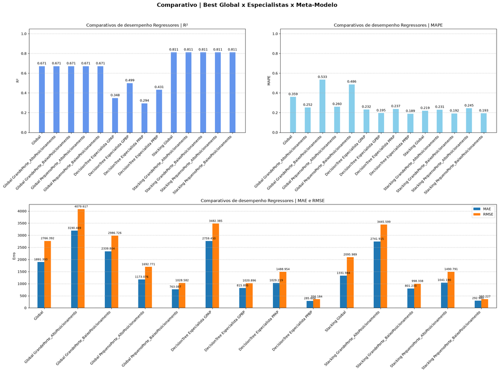

```python
df_comparativo_regressor_final = pd.DataFrame(comparativo_final_modelos_regressor).T
plt.figure(figsize=(20, 15))
plt.suptitle('Comparativo | Best Global x Especialistas x Meta-Modelo', fontsize=16, fontweight='bold')


plt.subplot(2, 2, 1)
barras = plt.bar(df_comparativo_regressor_final.index, df_comparativo_regressor_final['R²'], color='cornflowerblue', width=0.4)
plt.title('Comparativos de desempenho Regressores | R²')
plt.ylabel('R²')
plt.xticks(rotation=45, ha='right')
plt.ylim(0, 1.05)
plt.grid(axis='y', linestyle='--', alpha=0.7)

for barra in barras:
  altura = barra.get_height()
  plt.annotate(
      f'{altura:.3f}',
      xy=(barra.get_x() + barra.get_width() / 2, altura),
      xytext=(0, 3),
      textcoords='offset points',
      ha='center',
      va='bottom',
      fontsize=9)

plt.subplot(2, 2, 2)
barras = plt.bar(df_comparativo_regressor_final.index, df_comparativo_regressor_final['MAPE'], color='skyblue', width=0.4)
plt.title('Comparativos de desempenho Regressores | MAPE')
plt.ylabel('MAPE')
plt.xticks(rotation=45, ha='right')
plt.ylim(0, 1.05)
plt.grid(axis='y', linestyle='--', alpha=0.7)

for barra in barras:
  altura = barra.get_height()
  plt.annotate(
      f'{altura:.3f}',
      xy=(barra.get_x() + barra.get_width() / 2, altura),
      xytext=(0, 3),
      textcoords='offset points',
      ha='center',
      va='bottom',
      fontsize=9)


plt.subplot(2, 1, 2)
df_comparativo_regressor_final[['MAE', 'RMSE']].plot(kind='bar', width=0.4, rot=0, ax=plt.gca())
plt.title('Comparativos de desempenho Regressores | MAE e RMSE')
plt.ylabel('Erro')
plt.xticks(rotation=45, ha='right')
plt.grid(axis='y', linestyle='--', alpha=0.7)
plt.legend(loc='upper right')

for p in plt.gca().patches:
  plt.gca().annotate(
      f'{p.get_height():.3f}',
      (p.get_x() + p.get_width() / 2., p.get_height()),
      xytext=(0, 3),
      textcoords='offset points',
      ha='center',
      va='bottom',
      fontsize=8)

plt.tight_layout(rect=[0, 0, 1, 0.96])
plt.show()
```

```python
df_resumo = pd.DataFrame(comparativo_modelos_regressor).T
colunas_desejadas = ['R²', 'MAE', 'MAPE']
modelos_desejados = [
    'Baseline | Dummy Regressor',
    'Decision Tree',
    'Stacking Global']
modelos_presentes = [m for m in modelos_desejados if m in df_resumo.index]
df_filtrado = df_resumo.loc[modelos_presentes, colunas_desejadas]
tabela_comparativa_global = df_filtrado.rename(columns={
    'R²': 'R²',
    'MAE': 'MAE (R$)',
    'MAPE': 'MAPE (%)'})
tabela_comparativa_global = tabela_comparativa_global.round(2)
print("Comparativo Modelos Globais")
display(tabela_comparativa_global)

print(f'\n')

df_comparativo_regressor_final = pd.DataFrame(comparativo_final_modelos_regressor).T
df_tabela = df_comparativo_regressor_final.copy()


mapeamento_modelos = {
    'Global GrandePorte_AltoPosicionamento': ('Global', 'GP Alto'),
    'Global GrandePorte_BaixoPosicionamento': ('Global', 'GP Baixo'),
    'Global PequenoPorte_AltoPosicionamento': ('Global', 'PP Alto'),
    'Global PequenoPorte_BaixoPosicionamento': ('Global', 'PP Baixo'),

    'DecisionTree Especialista GPAP': ('Especialistas', 'GP Alto'),
    'DecisionTree Especialista GPBP': ('Especialistas', 'GP Baixo'),
    'DecisionTree Especialista PPAP': ('Especialistas', 'PP Alto'),
    'DecisionTree Especialista PPBP': ('Especialistas', 'PP Baixo'),

    'Stacking GrandePorte_AltoPosicionamento': ('Stacking', 'GP Alto'),
    'Stacking GrandePorte_BaixoPosicionamento': ('Stacking', 'GP Baixo'),
    'Stacking PequenoPorte_AltoPosicionamento': ('Stacking', 'PP Alto'),
    'Stacking PequenoPorte_BaixoPosicionamento': ('Stacking', 'PP Baixo')
}

linhas_desejadas = list(mapeamento_modelos.keys())
df_filtrado = df_tabela.loc[df_tabela.index.intersection(linhas_desejadas)].copy()

df_filtrado['Tipo_Modelo'] = [mapeamento_modelos[idx][0] for idx in df_filtrado.index]
df_filtrado['Segmento'] = [mapeamento_modelos[idx][1] for idx in df_filtrado.index]

tabela_comparativa_mae = df_filtrado.pivot_table(
    index='Segmento',
    columns='Tipo_Modelo',
    values='MAE'
)[['Global', 'Especialistas', 'Stacking']]
tabela_comparativa_mae = tabela_comparativa_mae.round(2)

print("Comparativo de MAE por Segmento (R$)")
display(tabela_comparativa_mae)
```

```
Comparativo Modelos Globais
```

|  | R² | MAE (R$) | MAPE (%) |
| --- | --- | --- | --- |
| Baseline \| Dummy Regressor | -0.00 | 3681.72 | 1.02 |
| Decision Tree | 0.67 | 1891.39 | 0.36 |
| Stacking Global | 0.81 | 1331.98 | 0.22 |

```
Comparativo de MAE por Segmento (R$)
```

| Tipo_Modelo Segmento | Global | Especialistas | Stacking |
| --- | --- | --- | --- |
| GP Alto | 3190.47 | 2759.45 | 2741.91 |
| GP Baixo | 2339.80 | 815.89 | 801.23 |
| PP Alto | 1173.08 | 1029.22 | 1041.19 |
| PP Baixo | 763.09 | 285.60 | 292.98 |

Apesar de a arquitetura de Stacking parecer pesada, o custo computacional é baixo, visto que a inferência dos especialistas ocorre em paralelo e o meta-modelo linear resolve os pesos em poucos segundos. O maior trabalho se dá no treinamento do Modelo Global e dos especialistas. A arquitetura Stacking reaproveita este trabalho ao trazer os modelos treinados e salvos na memória.

**O que ocorre neste modelo?**

Primeiramente expandimos a base de dados e criamos atributos dummies binários (que indicam se é GPAP ou não, e assim por diante para os demais segmentos). Posteriormente, chamamos o modelo global para realizar previsões nos dados de treino, isto se torna nova feature na database. Em seguida, chamamos cada modelo especialista, seguindo a mesma abordagem utilizada no Global, e solicitamos suas previsões. Aqui é importante destacar que os especialistas inferem valores somente para o que lhes cabe (mesmo segmento), e para os demais imóveis o especialista inputa valor 0. Com as novas features dummies e as 5 novas colunas de previsões o meta-modelo poderá identificar onde cada modelo especialista atua e comparar padrões dentro das segmentações onde eles superam o global. O que o meta-modelo irá realizar é: ponderar dinamicamente qual fonte de informação priorizar e estabelecer pesos otimizadores para as predições.

Importante: o modelo ridge (meta-modelo), não irá ler as features preditoras que deram vida ao global e especialistas (como room, area, etc), ele recebe somente as predições e dummies. O resultado de sua predição será dado por:

$$\text{Preço Final} = \text{Intercepto} + (w_1 \times \text{pred\_global}) + (w_2 \times \text{pred\_gpap}) + \dots + (w_n \times \text{dummy\_segmento})$$

Simplificamos a representação do modelo acima pois, ao avaliar um imóvel específico, as outras dummies e predições de especialistas serão 0, logo esses termos se anulam e não possuem interferência no cálculo final daquela linha. A expectativa é um modelo mais estável e com diminuição do erro global.

**Sobre os resultados**:

- Entre as predições o Ridge atribui mais importância aos especialistas do que ao modelo global. Temos coeficientes em pred_GrandePorte_AltoPosicionamento (0.69) e pred_PequenoPorte_AltoPosicionamento (0.61) que lideram a influência, enquanto o pred_global recebeu o menor peso de todas as predições (0.197). Ou seja, o meta-modelo aprendeu a confiar mais na lógica segmentada do que na árvore global.
- O experimento de Stacking se provou superior à ao modelo global. Observamos uma redução significativa no erro médio absoluto (MAE de 1891 para 1331) e no erro quadrático (RMSE de 2766 para 2095), consolidando um R-Squared de 0.811. A estratégia de segmentar a base e usar modelos especialistas como features para um meta-modelo Ridge conseguiu capturar padrões que uma única Árvore de Decisão ignorava.
- Ao comparar o Stacking com os especialistas isolados, notamos que o meta-modelo melhora levemente o erro nos imóveis de Grande Porte (GPAP e GPBP), mas sofre uma pequena piora na precisão dos imóveis de Pequeno Porte (PPAP e PPBP). Esse trade-off é compensado pelo ganho de operações: em vez de manter e monitorar 4 modelos diferentes em produção, o Stacking simplifica ao oferecer um único ponto para a operação.
- Apesar do bom desempenho geral, os gráficos de diagnóstico (Resíduos vs. Preditos e Q-Q Plot) revelam a heterocedasticidade. O modelo subestima os imóveis de alto valor (especialmente no segmento GPAP, maior erro), onde os resíduos se dispersam em formato de cone. Conforme o preço predito avança para a casa dos 10.000 e 15.000+, a dispersão dos pontos “explode”. A precificação de alto padrão possui mecanismos de variância que os atributos atuais não conseguem explicar.
- A Learning Curve mostra uma convergência rápida e estável entre treino e validação e podemos verificar que modelo não sofre de overfitting. O R-Squared de treino e teste são quase iguais, o que demonstra que o modelo generaliza bem. O modelo extraiu o que era possível das features atuais. Para romper a barreira de 0.81 e corrigir o erro no segmento GPAP, os próximos passos do produto devem focar em enriquecimento de dados.

**O desenvolvimento deste estudo gerou duas grandes percepções:** - Arquitetura Inteligente supera Força Bruta: Embora a Decision Tree seja costumeiramente escolhida somente como baseline (com o mercado priorizando Random Forest, XGBoost ou Redes Neurais), este projeto prova que uma arquitetura inteligente de Stacking combinada a engenharia de features é capaz de extrair performance de estimadores simples. Essa abordagem garante baixo custo computacional no treinamento e inferência rápida, otimizando assim o ROI. - Visão de Produto e Próximos Passos: Minha vivência de quase 5 anos em Operações me ensinou que o dado precisa resolver dores reais. Em um cenário real, este modelo não seria a linha de chegada, mas um ponto de partida (MVP) que justifica investimentos em governança e engrandecimento na coleta de dados. Além dos insights gerados na etapa de EDA (evidenciando gargalos no preenchimento de variáveis críticas), o motor de precificação poderia entrar em modo sombra ao fluxo de trabalho dos corretores em etapas de um piloto, como uma ferramenta balizadora para a captação de imóveis.